# Root endophyte analysis

Built with R version 4.3.3.

## Setup

### Libraries

```r
# library(car)
library(cowplot)
library(data.table)
library(DESeq2)
library(DHARMa)
library(ggpubr)
library(grid)
library(gridExtra)
library(iNEXT)
library(kableExtra)
library(knitr)
library(lmPerm)
library(MASS)
# library(matrixcalc)
library(pscl)
# library(rcompanion)
library(seqinr)
library(tidyverse)
library(vegan)
library(viridis)

# devtools::install_github("eastmallingresearch/Metabarcoding_pipeline/scripts")
library(metafuncs)
```

### Functions and constants

```r
ALPHA <-        0.1   # DESeq2 alpha value
OTUFILTER <-    0.01  # Remove OTUs with proportion of total reads below value
READFILTER <-   0.05  # Remove samples with read sum < sample_median_reads*READFILTER
PAIREDONLY <-   FALSE # Will remove the pair of samples which fail the readfilter - probably only useful for DESeq separated by type NOTE removes pairs before DESeq object is created
TAXCONF <-      0.80  # Sets the taxonomy confidence level to get "rank" in taxonomy files
TOPOTU <-       10    # Number of Top OTUs for summary information
DIFFOTU <-      200   # Number of Top OTUs for correlation analysis
FUNASVFILTER <- 0 # 0.05  # Filter fungal ASVs with proportion of total reads below value
BACASVFILTER <- 0 # 0.5   # Filter bacterial ASVs with proportion of total reads below value

# graphics
DEVICE <- "png"
DPI <-    1200
WIDTH <-  9
HEIGHT <- 9

# Model design
FACTORS <-            c("Site", "Storage", "Scion")
DESIGN <-             y ~ Site + Storage + Scion
FULL_DESIGN <-        y ~ Site * Storage * Scion
design_with_canker <- y ~ Site + Storage + Scion + Cankers + Site:Storage + Site:Scion + Storage:Scion + Cankers:Site + Cankers:Storage + Cankers:Scion
canker_design <-      "Cankers ~ Site * Storage * Scion"

# Control
ASV_FACTOR <- FALSE # Toggle for ASV ~ factor models
ASV_CANKER <- FALSE  # Toggle for ASV ~ Canker linear models
CANKER_ASV <- FALSE # Toggle for Canker ~ ASV nested models
```

```r
# colour blind palette
cbPalette <- c(
  "#000000", "#E69F00", "#56B4E9", "#009E73",
  "#F0E442", "#0072B2", "#D55E00", "#CC79A7"
)

source("functions/metabarcoding.R")
source("functions/loadme.R")
source("functions/rarefaction.R")
```

## Load data

Bacterial and fungal ASV (ZOTU) tables, sample metadata, and taxonomy files are loaded into named lists using the `loadData` function from Greg’s `metafuncs` package.

Site names are encoded as follows according to previous work:

- Avalon (East Sutton) -> 1
- Scripps (Brenchley) -> 2
- WWF (Pluckley) -> 3

```r
metadata <- "sample_metadata.txt"

# Load data
ubiome_FUN <- loadData(
  "data/FUN.zotu_table.txt", metadata,
  "data/zFUN.sintax.taxa", RHB="FUN"
)

ubiome_BAC <- loadData(
  "data/BAC.zotu_table.txt", metadata,
  "data/zBAC.sintax.taxa", RHB="BAC"
)

# Change sites Avalon -> 1, Scripps -> 2, and WWF -> 3.
# Storage from planting date.
# No storage for December plantings, yes for March and April (4 months).
mutate_factors <- function(data){
  data <- data %>%
    rename(location = site, Scion = cultivar) %>%
    mutate(
      Site = case_when(
        location == "Avalon" ~ 1,
        location == "Scripps" ~ 2,
        location == "WWF" ~ 3
      ) %>% as.factor(),
      Storage = case_when(
        planting_date %in% c("march", "april") ~ "yes",
        planting_date %in% c("dec") ~ "no"
      ) %>% as.factor(),
      Season = case_when(
        planting_date %in% c("march", "april") ~ "Spring",
        planting_date %in% c("dec") ~ "Winter"
      ) %>% as.factor(),
      Scion = as.factor(Scion)
    )
  return(data)
}

ubiome_FUN$colData <- mutate_factors(ubiome_FUN$colData)
ubiome_BAC$colData <- mutate_factors(ubiome_BAC$colData)

# In taxData and countData replace 'OTU' with 'ASV'
rownames(ubiome_FUN$taxData) <- gsub("OTU", "ASV", rownames(ubiome_FUN$taxData))
rownames(ubiome_BAC$taxData) <- gsub("OTU", "ASV", rownames(ubiome_BAC$taxData))

rownames(ubiome_FUN$countData) <- gsub("OTU", "ASV", rownames(ubiome_FUN$countData))
rownames(ubiome_BAC$countData) <- gsub("OTU", "ASV", rownames(ubiome_BAC$countData))
```

### Global removals

```r
# Sample "A2-7" removed due to missampling.
ubiome_BAC$colData <- ubiome_BAC$colData[!rownames(ubiome_BAC$colData) %in% "HMA27", ]
ubiome_BAC$countData <- ubiome_BAC$countData[, !colnames(ubiome_BAC$countData) %in% "HMA27"]
ubiome_FUN$colData <- ubiome_FUN$colData[!rownames(ubiome_FUN$colData) %in% "HMA27", ]
ubiome_FUN$countData <- ubiome_FUN$countData[, !colnames(ubiome_FUN$countData) %in% "HMA27"]
```

## Filter samples and ASVs

### Filtering taxa

Plantae taxa are filtered from fungal `taxData`. Chloroplast and Eukaryote taxa are filtered from bacterial `taxData`. Corresponding ASVs are removed from `countData`.

```r
# Filter Plant, Chloroplast, and Eukaryote ASVs

# Fungi: Plantae ASVs
cat("Fungi:", length(grep("Plantae", ubiome_FUN$taxData$kingdom)), "Plantae ASVs\n")
```

```
# Fungi: 0 Plantae ASVs
```

```r
# Bacteria: Chloroplast (Streptophyta) and Eukaryote ASVs
cat(
  "Bacteria:", length(grep("Streptophyta", ubiome_BAC$taxData$genus)), "Chloroplast ASVs;",
  length(grep("Eukaryota", ubiome_BAC$taxData$kingdom)), "Eukaryote ASVs\n"
)
```

```
# Bacteria: 37 Chloroplast ASVs; 188 Eukaryote ASVs
```

```r
# Filter Chloroplast and Eukaryote
filt <- rownames(
  ubiome_BAC$taxData[
    grepl("Streptophyta", ubiome_BAC$taxData$genus) &
    as.numeric(ubiome_BAC$taxData$g_conf) >= TAXCONF,
  ]
)

filt <- c(filt, rownames(ubiome_BAC$taxData[grep("Eukaryota", ubiome_BAC$taxData$kingdom), ]))

cat("Bacteria: removing", length(filt), "ASVs")
```

```
# Bacteria: removing 198 ASVs
```

```r
ubiome_BAC$taxData <- ubiome_BAC$taxData[!rownames(ubiome_BAC$taxData) %in% filt, ]
ubiome_BAC$countData <- ubiome_BAC$countData[!rownames(ubiome_BAC$countData) %in% filt, ]
```

### Filtering samples

Plot rarefaction curves.

Remove samples with read count below 5 % of median.

```r
invisible(mapply(assign, names(ubiome_BAC), ubiome_BAC, MoreArgs = list(envir = globalenv())))
rare_bac <- gfunc(countData, colData, "Bacteria")
# rare_bac <- gfunc(as.data.frame(counts(dds)), as.data.frame(colData(dds)), "Bacteria ZOTU")
invisible(mapply(assign, names(ubiome_FUN), ubiome_FUN, MoreArgs = list(envir = globalenv())))
rare_fun <- gfunc(countData, colData, "Fungi")
# rare_fun <- gfunc(as.data.frame(counts(dds)), as.data.frame(colData(dds)), "Fungi ZOTU")

rarefaction_plots <- grid.arrange(
  rare_bac, rare_fun,
  left = textGrob(label = expression("log"[10] * " aligned sequences"), rot = 90),
  bottom = "ASV count", nrow = 2
)

ggsave(filename = "rarefaction_plots.png", plot = rarefaction_plots, path = "figures/")

rarefaction_plots

# Fungi
med <- median(colSums(ubiome_FUN$countData))
filt <- !colSums(ubiome_FUN$countData) > med * READFILTER
cat("Fungi: ",sum(filt),"sample(s) removed\n")

# Bacteria
med <- median(colSums(ubiome_BAC$countData))
filt <- !colSums(ubiome_BAC$countData) > med * READFILTER
cat("Bacteria: ",sum(filt),"sample(s) removed\n")
```

[output not shown]

### Filter ASVs

#### ASV read count

```r
asv_propotions <- function(countData, proportion){
  i <- sum(countData)
  y <- rowSums(countData)
  y <- y[order(y, decreasing = T)]
  asvs <- length(y[(cumsum(y) / i <= proportion)])
  return(asvs)
}

proportions <- c(0.5, 0.9, 0.99, 1)

top_asvs <- data.table(
  "proportion" = proportions,
  "Fungi" = lapply(proportions, function(x) asv_propotions(ubiome_FUN$countData, x)),
  "Bacteria" = lapply(proportions, function(x) asv_propotions(ubiome_BAC$countData, x))
)

top_asvs %>%
  kbl() %>%
  kable_styling("striped", full_width = F)
```

| proportion | Fungi | Bacteria |
| --- | --- | --- |
| 0.50 | 10 | 169 |
| 0.90 | 171 | 2186 |
| 0.99 | 995 | 5883 |
| 1.00 | 2401 | 7265 |

#### Filter ASVs

Remove ASVs with read count below 1 % of total reads.

```r
# Fungi
keep <- filter_otus(ubiome_FUN$countData, OTUFILTER)
cat(
  "Fungi:\n",
  " - total ASVs:", nrow(ubiome_FUN$countData), "\n",
  " - removing", nrow(ubiome_FUN$countData) - length(keep), "ASVs\n",
  " - remaining ASVs:", length(keep), "\n"
)
```

```
# Fungi:
#   - total ASVs: 2401
#   - removing 1406 ASVs
#   - remaining ASVs: 995
```

```r
ubiome_FUN$taxData <- ubiome_FUN$taxData[rownames(ubiome_FUN$taxData) %in% keep,]
ubiome_FUN$countData <- ubiome_FUN$countData[rownames(ubiome_FUN$countData) %in% keep,]

# Bacteria
keep <-  filter_otus(ubiome_BAC$countData, OTUFILTER)
cat(
  "Bacteria:\n",
  " - total ASVs:", nrow(ubiome_BAC$countData), "\n",
  " - removing", nrow(ubiome_BAC$countData) - length(keep), "ASVs\n",
  " - remaining ASVs:", length(keep), "\n"
)
```

```
# Bacteria:
#   - total ASVs: 7265
#   - removing 1382 ASVs
#   - remaining ASVs: 5883
```

```r
ubiome_BAC$taxData <- ubiome_BAC$taxData[rownames(ubiome_BAC$taxData) %in% keep,]
ubiome_BAC$countData <- ubiome_BAC$countData[rownames(ubiome_BAC$countData) %in% keep,]
```

## Absolute abundance normalisation

ASV normalisation is performed using qPCR theoretical copy number data. Copy number is calculated per mg of root sample from the qPCR data.

### Prepare qPCR abundance data

```r
abundance <- fread("mean_abundance.csv")

# Add sample ID to abundance data
abundance$id <- paste0("HM", gsub("-", "", abundance$Sample))
# abundance$id <- abundance$Sample
abundance$copy_number <- abundance$MeanAdjustedTCN_mg
abundance$log_copy_number <- log10(abundance$copy_number)

# Add bacterial (16S) and fungal (ITS) abundance to ubiome BAC and FUN named lists
ubiome_FUN$abundance <- abundance[abundance$Target == "ITS"] %>%
  column_to_rownames(var = "id")
ubiome_BAC$abundance <- abundance[abundance$Target == "16S"] %>%
  column_to_rownames(var = "id")

# Merge copy number from abundance with colData
ubiome_FUN$colData <- merge(
  ubiome_FUN$colData,
  ubiome_FUN$abundance[, c("Target", "copy_number", "log_copy_number")],
  by = "row.names", all.x = TRUE
) %>% column_to_rownames(var = "Row.names")

ubiome_BAC$colData <- merge(
  ubiome_BAC$colData,
  ubiome_BAC$abundance[, c("Target", "copy_number", "log_copy_number")],
  by = "row.names", all.x = TRUE
) %>% column_to_rownames(var = "Row.names")
```

#### Remove outliers

```r
# Detect outliers with std > threshold from the median
detect_outliers <- function(x, val, threshold, na.rm = TRUE) {
  med_x <- median(x[[val]], na.rm = na.rm)
  sd_x <- sd(x[[val]], na.rm = na.rm)
  outliers <- x[x[[val]] > (med_x + threshold * sd_x) | x[[val]] < (med_x - threshold * sd_x), ]
  return(outliers)
}

outliers_FUN <- detect_outliers(ubiome_FUN$abundance, "MeanAdjustedTCN_mg", 3)
outliers_BAC <- detect_outliers(ubiome_BAC$abundance, "MeanAdjustedTCN_mg", 3)

# Remove samples with copy number > 3 std from the median
outliers <- rownames(outliers_FUN)
ubiome_FUN$abundance <- ubiome_FUN$abundance[!rownames(ubiome_FUN$abundance) %in% outliers, ]
ubiome_FUN$countData <- ubiome_FUN$countData[, !colnames(ubiome_FUN$countData) %in% outliers]
ubiome_FUN$colData <- ubiome_FUN$colData[!rownames(ubiome_FUN$colData) %in% outliers, ]

cat("Fungi: removing", length(outliers), "outlier(s)\n")
```

```
# Fungi: removing 1 outlier(s)
```

Sample A1-3 is removed from the fungal data due to abnormally high copy number.

## Canker count data

Canker count data for sampled trees only.

```r
# Canker count data for sampled trees only

canker_data <- fread("canker_data.csv", select = c(1:5, 7:34))

# Remove spaces from column names and convert to lowercase
colnames(canker_data) <- tolower(gsub(" ", "_", colnames(canker_data)))

# Codify site names, add storage and total canker count for timepoint 4
canker_data <- mutate(
  canker_data,
  Site = case_when(
    site == "Avalon" ~ 1,
    site == "Scripps" ~ 2,
    site == "WWF" ~ 3
  ) %>% as.factor(),
  Storage = case_when(
    planting_date %in% c("March", "April") ~ "yes",
    planting_date %in% c("Dec") ~ "no"
  ),
  Scion = as.factor(cultivar),
  total_cankers = a4 + b4 + c4 + d4 + e4
)

# Identify samples with missing values
missing <- unique(canker_data[!complete.cases(canker_data), code])

# Also remove sample A2-7 due to missampling
missing <- c(missing, "HMA27")

# Remove missing samples from canker data
# canker_data <- canker_data[!canker_data$code %in% missing, ]
canker_data <- canker_data[!canker_data$code %in% "HMA27", ]

# Verify that there are two trees for each sample
canker_data %>% group_by(code) %>% summarise(n = n()) %>% filter(n != 2)
```

```
# # A tibble: 0 × 2
# # ℹ 2 variables: code <chr>, n <int>
```

```r
# Sum of total cankers for each pair of trees with matching code
cankers <- canker_data %>%
  group_by(code) %>%
  summarise(
    Site = first(Site),
    Storage = first(Storage),
    Scion = first(Scion),
    Cankers_sum = sum(total_cankers),
    Cankers = round(mean(total_cankers, na.rm = TRUE))
  ) %>%
  column_to_rownames("code")

# Add total canker count to colData for both FUN and BAC
ubiome_FUN$colData <- merge(
  ubiome_FUN$colData,
  cankers[, c("Cankers", "Cankers_sum")],,
  by = 0,
  all.x = TRUE
) %>% column_to_rownames("Row.names")

ubiome_BAC$colData <- merge(
  ubiome_BAC$colData,
  cankers[, c("Cankers", "Cankers_sum")],
  by = 0,
  all.x = T
) %>% column_to_rownames("Row.names")
```

Summary stats

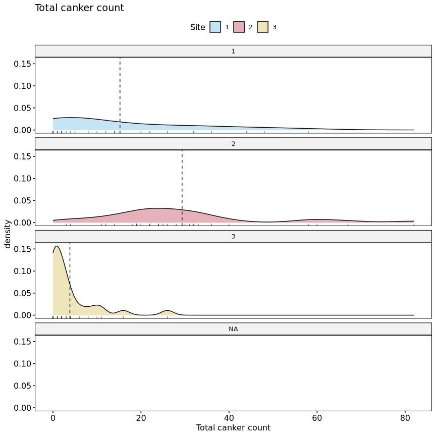

```r
# png("figures/hist.png", width = 800, height = 600)
# hist(cankers$Cankers, breaks = 20, main = "Total canker count", xlab = "Total canker count")
# dev.off()

cankers_hist <- ggdensity(
  cankers, x = "Cankers", fill = "Site", facet.by = "Site", ncol = 1,
  add = "mean", rug = T, palette = cbPalette,
  title = "Total canker count", xlab = "Total canker count"
)

cankers_hist
```

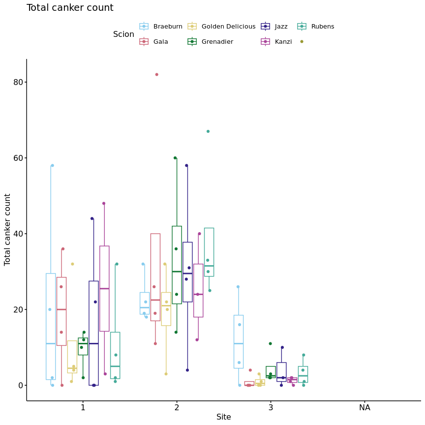

```r
ggsave(filename = "cankers_hist.png", plot = cankers_hist, path = "figures/")

cankers_box <- ggboxplot(
  cankers, x = "Site", y = "Cankers", palette = cbPalette,
  color = "Scion", add = "jitter", legend = "top",
  title = "Total canker count", xlab = "Site", ylab = "Total canker count"
)

cankers_box
```

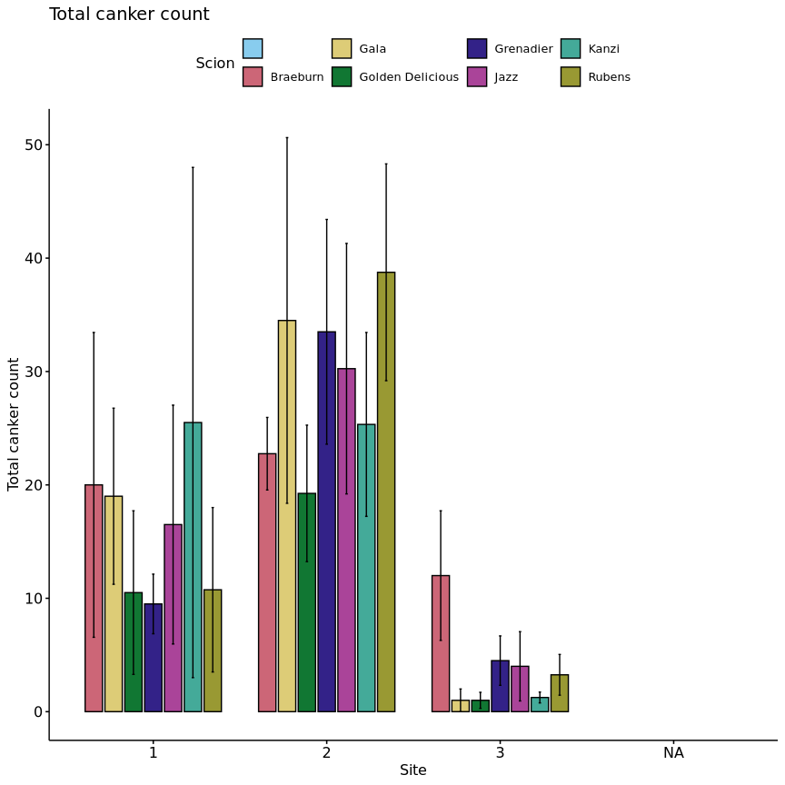

```r
ggsave(filename = "cankers_box.png", plot = cankers_box, path = "figures/")

cankers_bar <- ggbarplot(
  cankers, x = "Site", y = "Cankers", fill = "Scion",
  palette = cbPalette, add = "mean_se", position = position_dodge(0.8),
  title = "Total canker count", xlab = "Site", ylab = "Total canker count"
)

cankers_bar
```

```r
ggsave(filename = "cankers_bar.png", plot = cankers_bar, path = "figures/")
```

GLM

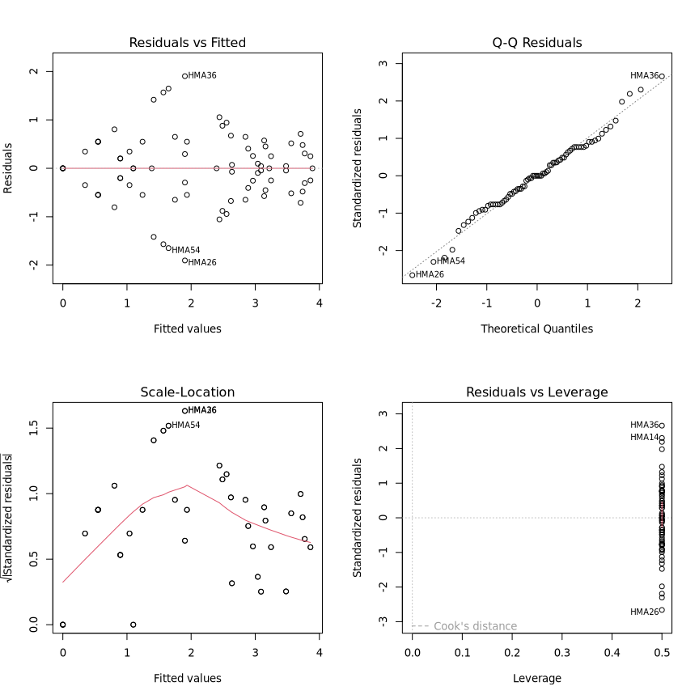

```r
# Effect of Site, Scion, and Storage on canker count

# Formula
formula <- update(FULL_DESIGN, Cankers ~ .)
# formula <- Cankers ~ Site + Storage + Scion + site:Storage + site:Scion + Storage:Scion

# Log-linear model
canker_lm <- lm(update(FULL_DESIGN, log(Cankers + 1) ~ .), data = cankers)

par(mfrow = c(2, 2))
plot(canker_lm)
```

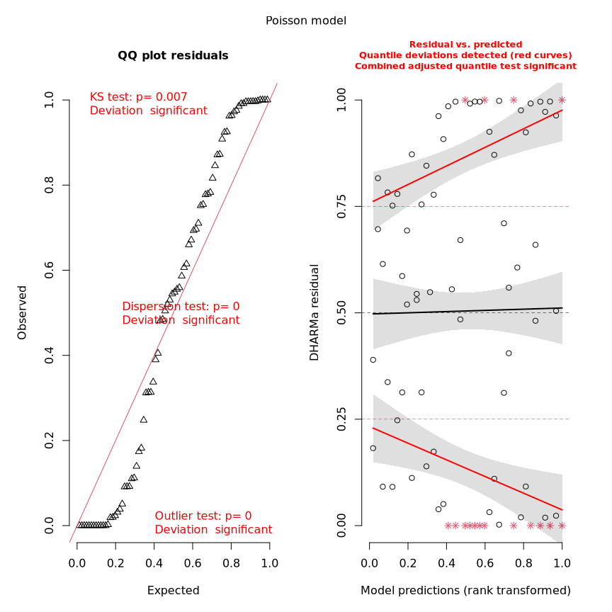

```r
# Residual checking
res <- resid(canker_lm, type = "pearson")

# Poisson model
canker_poisson <- glm(formula, data = cankers, family = "poisson")

poisson_plot <- plot(simulateResiduals(canker_poisson), title = "Poisson model")
```

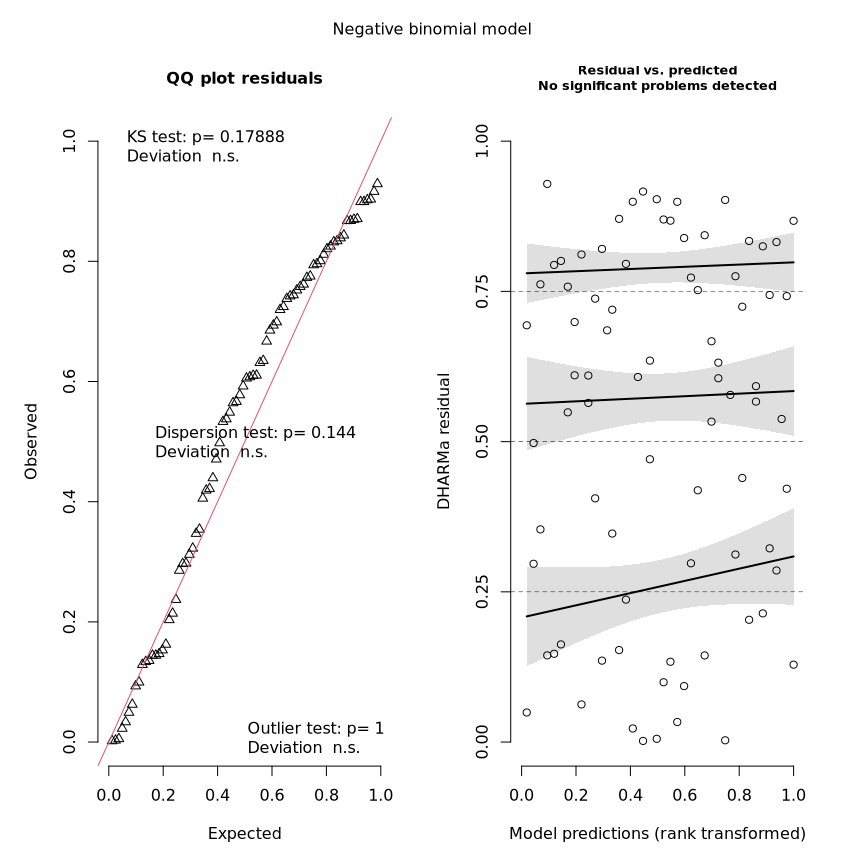

```r
# Model overdispersed

# Negative binomial model
canker_negbin <- glm.nb(formula, data = cankers)

sim <- simulateResiduals(canker_negbin)

plot(sim, title = "Negative binomial model")
```

```r
# canker_model_plots <- ggarrange(lm_plot, poisson_plot, negbin_plot, ncol = 3)

# ggsave(filename = "canker_model_plots.png", plot = canker_model_plots, path = "figures/")

# png("figures/canker_residuals.png", width = 800, height = 600)
# plot(sim)
# dev.off()

testZeroInflation(sim)
```

```
#
#   DHARMa zero-inflation test via comparison to expected zeros with
#   simulation under H0 = fitted model
#
# data:  simulationOutput
# ratioObsSim = 1.1632, p-value = 0.512
# alternative hypothesis: two.sided
```

```r
nagelkerke(canker_negbin)
```

[output not shown]

```r
# Model good fit

canker_anova <- anova(canker_negbin, test = "Chisq") %>% data.frame()
total_deviance <- sum(canker_anova$Deviance, na.rm = T) + tail(canker_anova$Resid..Dev, 1)
canker_anova$Perc..Dev <- canker_anova$Deviance / total_deviance * 100

canker_anova
```

```
#                    Df   Deviance Resid..Df Resid..Dev     Pr..Chi.  Perc..Dev
# NULL               NA         NA        79   304.3502           NA         NA
# Site                2 102.641603        77   201.7086 5.148244e-23 33.7248331
# Storage             1   1.585954        76   200.1227 2.079052e-01  0.5210949
# Scion               6  13.206882        70   186.9158 3.986579e-02  4.3393699
# Site:Storage        2  34.419859        68   152.4959 3.356005e-08 11.3092933
# Site:Scion         12  29.660625        56   122.8353 3.140170e-03  9.7455573
# Storage:Scion       6   9.810476        50   113.0248 1.328636e-01  3.2234167
# Site:Storage:Scion 12  25.591616        38    87.4332 1.225523e-02  8.4086077
```

[figure not shown]

## Create DESeq objects

```r
# Make sure countData and colData still match, if they do, create DESeq objects, if not throw error
if(identical(colnames(ubiome_FUN$countData), rownames(ubiome_FUN$colData))) {
  # Create DESeq object
  ubiome_FUN$dds <- ubiom_to_des(ubiome_FUN)
  print("FUN DESeq object created")
} else {
  stop("FUN countData and colData do not match")
}
```

```
# [1] "FUN DESeq object created"
```

```r
if(identical(colnames(ubiome_BAC$countData), rownames(ubiome_BAC$colData))) {
  # Create DESeq object
  ubiome_BAC$dds <- ubiom_to_des(ubiome_BAC)
  print("BAC DESeq object created")
} else {
  stop("BAC countData and colData do not match")
}
```

```
# [1] "BAC DESeq object created"
```

## Abundance normalisation

Absolute abundance normalisation using DESeq2 size factors.

Values are centred around the mean of the copy number.

```r
# Normalise count data using DESeq2 size factors

ubiome_FUN$dds$sizeFactor <- ubiome_FUN$dds$copy_number / mean(ubiome_FUN$dds$copy_number)
ubiome_BAC$dds$sizeFactor <- ubiome_BAC$dds$copy_number / mean(ubiome_BAC$dds$copy_number)
```

```r
# Save environment
save.image("data_loaded.RData")
```

# **Fungi**

```r
# Unpack fungi data
invisible(mapply(assign, names(ubiome_FUN), ubiome_FUN, MoreArgs = list(envir = globalenv())))
```

## ASV and sample summary

### Read and sample summary

```r
cat(
  "Raw reads", "\n\n",
  "Total raw reads:\t\t", sum(countData), "\n",
  "Mean raw reads per sample:\t", mean(colSums(countData)), "\n",
  "Median raw reads per sample:\t", median(colSums(countData)), "\n",
  "Max raw reads per sample:\t", max(colSums(countData)), "\n",
  "Min raw reads per sample:\t", min(colSums(countData)), "\n\n"
)
```

```
# Raw reads
#
#  Total raw reads:      7293776
#  Mean raw reads per sample:    90046.62
#  Median raw reads per sample:  93435
#  Max raw reads per sample:     113518
#  Min raw reads per sample:     38472
```

```r
#colSums(countData)

nct <- counts(dds, normalize = T)
cat("Normalised reads", "\n\n",
  "Total normalised reads:\t\t", sum(nct), "\n",
  "Mean normalised reads per sample:\t", mean(colSums(nct)), "\n",
  "Median normalised reads per sample:\t", median(colSums(nct)), "\n",
  "Min normalised reads per sample:\t", min(colSums(nct)), "\n",
  "Max normalised reads per sample:\t", max(colSums(nct)), "\n\n"
)
```

```
# Normalised reads
#
#  Total normalised reads:       12468857
#  Mean normalised reads per sample:     153936.5
#  Median normalised reads per sample:   98624.28
#  Min normalised reads per sample:  28901.7
#  Max normalised reads per sample:  881441.3
```

```r
#round(colSums(counts(dds,normalize = T)),0)
```

### ASV summary

```r
cat(
  "Total ASVs:\t\t", nrow(taxData),"\n\n",
  "Raw reads per ASV summary", "\n\n",
  "Mean raw reads per ASV:\t", mean(rowSums(countData)),"\n",
  "Median raw per ASV:\t\t", median(rowSums(countData)),"\n",
  "ASV raw Min reads:\t\t", min(rowSums(countData)),"\n",
  "ASV raw Max reads:\t\t", max(rowSums(countData)),"\n\n"
)
```

```
# Total ASVs:        995
#
#  Raw reads per ASV summary
#
#  Mean raw reads per ASV:   7330.428
#  Median raw per ASV:       588
#  ASV raw Min reads:        115
#  ASV raw Max reads:        714327
```

```r
cat(
  "Normalised reads per ASV summary","\n\n",
  "Mean normalised reads per ASV:\t\t", mean(rowSums(nct)),"\n",
  "Median normalised reads per ASV:\t", median(rowSums(nct)),"\n",
  "ASV normalised Min reads:\t\t", min(rowSums(nct)),"\n",
  "ASV normalised Max reads:\t\t", max(rowSums(nct)),"\n\n"
)
```

```
# Normalised reads per ASV summary
#
#  Mean normalised reads per ASV:        12531.51
#  Median normalised reads per ASV:  1025.725
#  ASV normalised Min reads:         101.2814
#  ASV normalised Max reads:         1509459
```

```r
y <- rowSums(nct)
y <- y[order(y, decreasing = T)]
# proportion
xy <- y / sum(y)

cat("Top " ,TOPOTU, "ASVs:\n")
```

```
# Top  10 ASVs:
```

```r
data.frame(
  counts = y[1:TOPOTU],
  proportion = xy[1:TOPOTU],
  rank = taxData[names(y)[1:TOPOTU],]$rank
) %>%
  kbl() %>%
  kable_styling("striped", full_width = F)
```

|  | counts | proportion | rank |
| --- | --- | --- | --- |
| ASV2 | 1509458.8 | 0.1210583 | Ascomycota(p) |
| ASV1 | 1490469.5 | 0.1195354 | Dactylonectria macrodidyma(s) |
| ASV5 | 1068164.1 | 0.0856666 | Leotiomycetes(c) |
| ASV4 | 1059908.0 | 0.0850044 | Ascomycota(p) |
| ASV3 | 480660.1 | 0.0385488 | Ilyonectria destructans(s) |
| ASV7 | 290896.6 | 0.0233299 | Fusarium(g) |
| ASV6 | 227927.9 | 0.0182798 | Ilyonectria robusta(s) |
| ASV9 | 201690.6 | 0.0161755 | Ascomycota(p) |
| ASV8 | 191083.5 | 0.0153249 | Fusarium(g) |
| ASV11 | 131684.2 | 0.0105610 | Truncatella angustata(s) |

## Taxonomy Summary

### Taxonomy identifiable

Proportion of ASVs which can be assigned (with the given confidence) at each taxonomic rank.

```r
# Proportion of ASVs which can be assigned (with the given confidence) at each taxonomic rank

tx <- copy(taxData)
setDT(tx)
cols <- names(tx)[9:15]

tx[, (cols) := lapply(.SD, as.factor), .SDcols = cols]

data.table(
  rank = c("kingdom", "phylum", "class", "order", "family", "genus", "species"),
  "0.8" = round(unlist(lapply(cols, function(col) sum(as.number(tx[[col]]) >= 0.8) / nrow(tx))), 2),
  "0.65" = round(unlist(lapply(cols, function(col) sum(as.number(tx[[col]]) >= 0.65) / nrow(tx))), 2),
  "0.5" = round(unlist(lapply(cols, function(col) sum(as.number(tx[[col]]) >= 0.5) / nrow(tx))), 2)
) %>%
  kbl() %>%
  kable_styling("striped", full_width = F)
```

| rank | 0.8 | 0.65 | 0.5 |
| --- | --- | --- | --- |
| kingdom | 1.00 | 1.00 | 1.00 |
| phylum | 0.84 | 0.87 | 0.90 |
| class | 0.70 | 0.74 | 0.78 |
| order | 0.54 | 0.60 | 0.64 |
| family | 0.42 | 0.45 | 0.49 |
| genus | 0.38 | 0.42 | 0.47 |
| species | 0.24 | 0.30 | 0.35 |

% of reads which can be assigned to each taxonomic ranks

```r
tx <-taxData[rownames(dds),]
nc <- counts(dds, normalize = T)
ac <- sum(nc)

data.table(
  rank = c("kingdom", "phylum", "class", "order", "family", "genus", "species"),
  "0.8" = round(unlist(lapply(cols, function(col)(sum(nc[which(as.numeric(tx[[col]]) >= 0.8),]) / ac * 100))), 2),
  "0.65" = round(unlist(lapply(cols, function(col)(sum(nc[which(as.numeric(tx[[col]]) >= 0.65),]) / ac * 100))), 2),
  "0.5" = round(unlist(lapply(cols, function(col)(sum(nc[which(as.numeric(tx[[col]]) >= 0.5),]) / ac * 100))), 2)
) %>%
  kbl() %>%
  kable_styling("striped", full_width = F)
```

| rank | 0.8 | 0.65 | 0.5 |
| --- | --- | --- | --- |
| kingdom | 100.00 | 100.00 | 100.00 |
| phylum | 84.14 | 96.59 | 96.83 |
| class | 60.12 | 70.92 | 71.47 |
| order | 53.49 | 58.87 | 68.76 |
| family | 44.97 | 46.80 | 50.25 |
| genus | 46.06 | 48.01 | 50.72 |
| species | 30.44 | 36.70 | 41.62 |

### Taxonomy plots

Plots of proportion of normalised reads assigned to members of phylum and class.

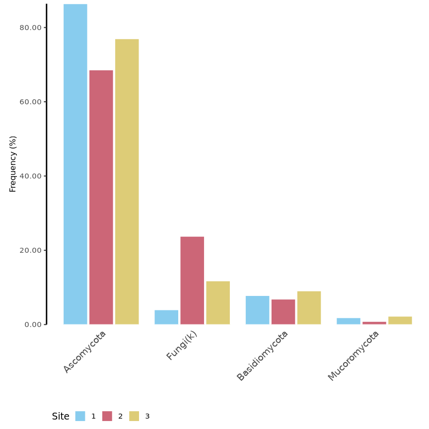

```r
# First just site
dat <- list(as.data.frame(counts(dds, normalize = T)), taxData, as.data.frame(colData(dds)))

design <- "Site"

# md1 <- getSummedTaxa(dat, conf = TAXCONF, design = design, cutoff = 0.1)
md1 <- getSummedTaxa(dat, conf = TAXCONF, design = design, taxon = "phylum", cutoff = 0.1)

md1[, Site := factor(Site, levels = c(1, 2, 3))]
md1[, taxon := factor(taxon, levels = unique(taxon[order(value, decreasing = T)]))]

removals <- md1[, .(value = mean(value)), by = "taxon"][value < 0.5, taxon]
md1 <- md1[!taxon %in% removals, ]

fun_phylum_site_plot <- plotfun1(md1, x = "taxon", fill = "Site")

ggsave("figures/fun_phylum_site.png", fun_phylum_site_plot, width = 20, height = 15, units = "cm")

fun_phylum_site_plot
```

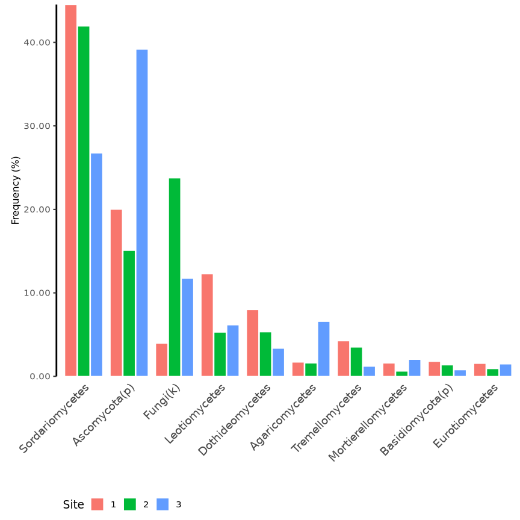

```r
md2 <- getSummedTaxa(dat, conf = TAXCONF, design = design, taxon = "class", cutoff = 0.1)

md2[, Site := factor(Site, levels = c(1, 2, 3))]
md2[, taxon := factor(taxon, levels = unique(taxon[order(value, decreasing = T)]))]

removals <- md2[, .(value = mean(value)), by = "taxon"][value < 0.5, taxon]
md2 <- md2[!taxon %in% removals, ]

fun_class_site_plot <- plotfun1(md2, x = "taxon", fill = "Site")

ggsave("figures/fun_class_site.png", fun_class_site_plot, width = 20, height = 15, units = "cm")

fun_class_site_plot
```

```r
# Next site and storage

design <- c("Site", "Storage")

md1 <- getSummedTaxa(dat, conf = TAXCONF, design = design, taxon = "phylum", cutoff = 0.1)

md1[, Site := factor(Site, levels = c(1, 2, 3))]
md1[, Storage := factor(Storage, levels = c("no", "yes"))]
md1[, taxon := factor(taxon, levels = unique(taxon[order(value, decreasing = T)]))]

removals <- md1[, .(value = mean(value)), by = "taxon"][value < 0.5, taxon]
md1 <- md1[!taxon %in% removals, ]

fun_phylum_plot <- plotfun1(md1, x = "taxon", fill = "Site") +
  facet_wrap(~ Storage)

ggsave("figures/fun_phylum.png", fun_phylum_plot, width = 25, height = 15, units = "cm")

md2 <- getSummedTaxa(dat, conf = TAXCONF, design = design, taxon = "class", cutoff = 0.1)

md2[, Site := factor(Site, levels = c(1, 2, 3))]
md2[, Storage := factor(Storage, levels = c("no", "yes"))]
md2[, taxon := factor(taxon, levels = unique(taxon[order(value, decreasing = T)]))]

removals <- md2[, .(value = mean(value)), by = "taxon"][value < 0.5, taxon]
md2 <- md2[!taxon %in% removals, ]

fun_class_plot <- plotfun1(md2, x = "taxon", fill = "Site") +
  facet_wrap(~ Storage)

ggsave("figures/fun_class.png", fun_class_plot, width = 25, height = 15, units = "cm")
```

## Community size

Plot copy number for each sample grouped by site, Scion, and Storage. Test the effect of site, Scion, and Storage on copy number using ANOVA.

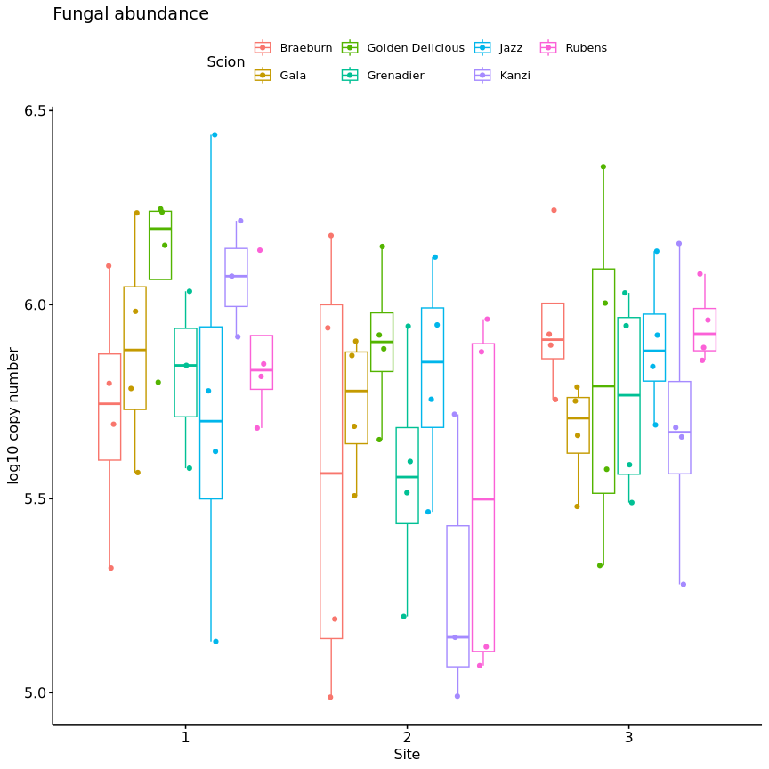

```r
# abundance_plot <- ggplot(
#   data = as.data.frame(colData(dds)),
#   aes(x = site, y = log_copy_number, colour = Scion, shape = Storage)
# ) + geom_jitter() +
#   scale_colour_manual(values = cbPalette)

fun_abundance_box <- ggboxplot(
  data = as.data.frame(colData(dds)), x = "Site", y = "log_copy_number",
  color = "Scion", add = "jitter", legend = "top",
  title = "Fungal abundance", xlab = "Site", ylab = "log10 copy number"
)

ggsave(
  filename = "fun_abundance.png", plot = fun_abundance_box, path = "figures/",
  height = 20, width = 20, units = "cm"
)

fun_abundance_box
```

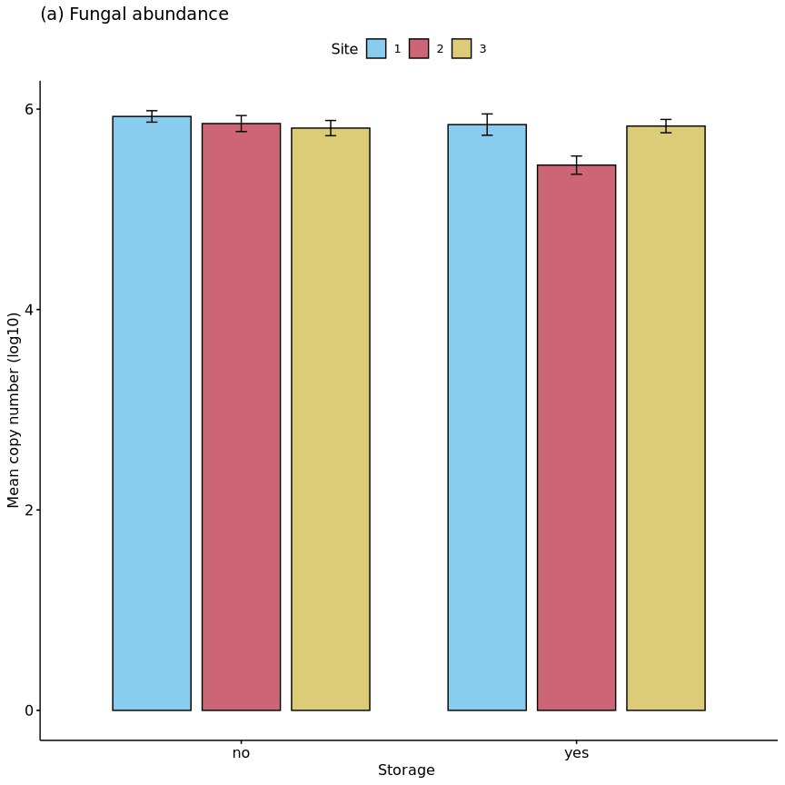

```r
fun_abundance_bar <- ggbarplot(
  data = as.data.frame(colData(dds)), x = "Storage", y = "log_copy_number",
  fill = "Site", add = "mean_se",
  palette = cbPalette, position = position_dodge(0.8),
  title = "(a) Fungal abundance", xlab = "Storage ", ylab = "Mean copy number (log10)"
) + guides(fill = guide_legend(title = "Site"))

ggsave(
  filename = "fun_abundance_bar.png", plot = fun_abundance_bar, path = "figures/",
  height = 20, width = 20, units = "cm"
)

fun_abundance_bar
```

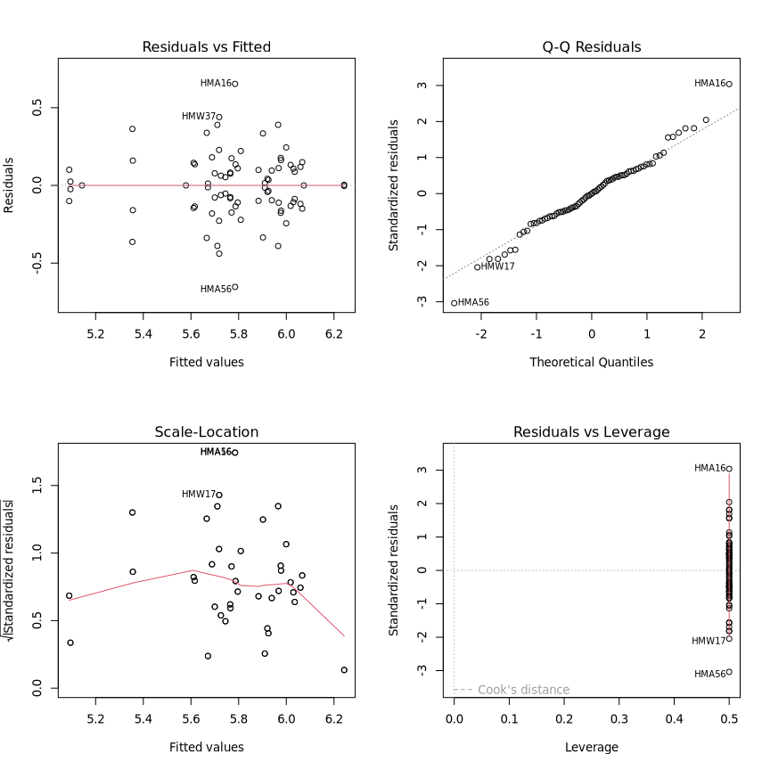

```r
# Formula for ANOVA
formula <- update(FULL_DESIGN, log_copy_number ~ .)

abundance_anova <- aov(formula, data = as.data.frame(colData(dds)))

# Normality check
par(mfrow = c(2, 2))
plot(abundance_anova)
```

```r
png("figures/fun_abundance_norm.png", width = 800, height = 600)
par(mfrow = c(2, 2))
plot(abundance_anova)
dev.off()
```

```
# png
#   2
```

```r
# Results
summary(abundance_anova)
```

```
#                    Df Sum Sq Mean Sq F value Pr(>F)
# Site                2  0.861  0.4306   4.663 0.0153 *
# Storage             1  0.501  0.5012   5.427 0.0251 *
# Scion               6  0.477  0.0795   0.860 0.5324
# Site:Storage        2  0.683  0.3415   3.698 0.0338 *
# Site:Scion         12  1.203  0.1003   1.086 0.3981
# Storage:Scion       6  0.458  0.0763   0.827 0.5564
# Site:Storage:Scion 12  0.918  0.0765   0.828 0.6214
# Residuals          39  3.602  0.0924
# ---
# Signif. codes:  0 '***' 0.001 '**' 0.01 '*' 0.05 '.' 0.1 ' ' 1
```

```r
abundance_results <- abundance_anova %>% summary() %>% unclass() %>% data.frame()
total_variance <- sum(abundance_results$Sum.Sq)
abundance_results$Perc.Var <- abundance_results$Sum.Sq / total_variance * 100

abundance_results %>%
  kbl() %>%
  kable_styling("striped", full_width = F)
```

|  | Df | Sum.Sq | Mean.Sq | F.value | Pr..F. | Perc.Var |
| --- | --- | --- | --- | --- | --- | --- |
| Site | 2 | 0.8612429 | 0.4306214 | 4.6626824 | 0.0152878 | 9.895484 |
| Storage | 1 | 0.5012156 | 0.5012156 | 5.4270616 | 0.0250969 | 5.758852 |
| Scion | 6 | 0.4767020 | 0.0794503 | 0.8602723 | 0.5323908 | 5.477197 |
| Site:Storage | 2 | 0.6830842 | 0.3415421 | 3.6981494 | 0.0338326 | 7.848482 |
| Site:Scion | 12 | 1.2031665 | 0.1002639 | 1.0856371 | 0.3981291 | 13.824108 |
| Storage:Scion | 6 | 0.4580790 | 0.0763465 | 0.8266645 | 0.5564216 | 5.263223 |
| Site:Storage:Scion | 12 | 0.9180631 | 0.0765053 | 0.8283835 | 0.6213710 | 10.548335 |
| Residuals | 39 | 3.6018401 | 0.0923549 | NA | NA | 41.384319 |

### Communtiy size with canker count

```r
cat("Model formula: ", deparse(update(design_with_canker, log_copy_number ~ .)), "\n")
```

```
# Model formula:  log_copy_number ~ Site + Storage + Scion + Cankers + Site:Storage +      Site:Scion + Storage:Scion + Site:Cankers + Storage:Cankers +      Scion:Cankers
```

```r
abundance_canker_anova <- aov(update(design_with_canker, log_copy_number ~ .), data = as.data.frame(colData(dds)))
summary(abundance_canker_anova)
```

```
#                 Df Sum Sq Mean Sq F value Pr(>F)
# Site             2  0.780  0.3898   3.826 0.0304 *
# Storage          1  0.575  0.5749   5.644 0.0225 *
# Scion            6  0.581  0.0968   0.950 0.4714
# Cankers          1  0.050  0.0499   0.490 0.4882
# Site:Storage     2  0.613  0.3067   3.011 0.0608 .
# Site:Scion      12  1.002  0.0835   0.819 0.6297
# Storage:Scion    6  0.417  0.0695   0.682 0.6649
# Site:Cankers     2  0.187  0.0936   0.919 0.4075
# Storage:Cankers  1  0.010  0.0097   0.095 0.7593
# Scion:Cankers    6  0.321  0.0535   0.525 0.7858
# Residuals       39  3.973  0.1019
# ---
# Signif. codes:  0 '***' 0.001 '**' 0.01 '*' 0.05 '.' 0.1 ' ' 1
# 2 observations deleted due to missingness
```

```r
abundance_canker_results <- abundance_canker_anova %>% summary() %>% unclass() %>% data.frame()
total_variance <- sum(abundance_canker_results$Sum.Sq)
abundance_canker_results$Perc.Var <- abundance_canker_results$Sum.Sq / total_variance * 100
abundance_canker_results %>%
  kbl() %>%
  kable_styling("striped", full_width = F)
```

|  | Df | Sum.Sq | Mean.Sq | F.value | Pr..F. | Perc.Var |
| --- | --- | --- | --- | --- | --- | --- |
| Site | 2 | 0.7796132 | 0.3898066 | 3.8264193 | 0.0303835 | 9.1633108 |
| Storage | 1 | 0.5749285 | 0.5749285 | 5.6436127 | 0.0225290 | 6.7575159 |
| Scion | 6 | 0.5805056 | 0.0967509 | 0.9497265 | 0.4713815 | 6.8230675 |
| Cankers | 1 | 0.0499015 | 0.0499015 | 0.4898427 | 0.4881516 | 0.5865249 |
| Site:Storage | 2 | 0.6134679 | 0.3067340 | 3.0109620 | 0.0608122 | 7.2104959 |
| Site:Scion | 12 | 1.0017806 | 0.0834817 | 0.8194732 | 0.6297497 | 11.7745925 |
| Storage:Scion | 6 | 0.4169670 | 0.0694945 | 0.6821718 | 0.6649206 | 4.9008893 |
| Site:Cankers | 2 | 0.1871726 | 0.0935863 | 0.9186619 | 0.4075144 | 2.1999640 |
| Storage:Cankers | 1 | 0.0096995 | 0.0096995 | 0.0952120 | 0.7592951 | 0.1140044 |
| Scion:Cankers | 6 | 0.3209250 | 0.0534875 | 0.5250439 | 0.7857697 | 3.7720440 |
| Residuals | 39 | 3.9730243 | 0.1018724 | NA | NA | 46.6975908 |

## Alpha diversity analysis

### Alpha diversity plot

```r
# plot alpha diversity - plot_alpha will convert normalised abundances to integer values

fun_alpha_plot <- plot_alpha(
  counts(dds, normalize = F), colData(dds),
  design = "Scion", colour = "Site",
  measures = c("Shannon", "Simpson"),
  type = "bar"
) + scale_colour_manual(values = cbPalette) +
  theme(axis.title.x = element_blank()) +
  ggtitle("Fungal α-diversity")

ggsave(
  filename = "fun_alpha.png", plot = fun_alpha_plot, path = "figures/",
  height = 20, width = 40, units = "cm"
)
```

[output not shown]

```r
fun_alpha_plot
```

[output not shown]

### Permutation based anova on α-diversity index ranks

```r
# get the diversity index data
all_alpha_ord <- plot_alpha(
  counts(dds, normalize = F),
  colData(dds),
  returnData = T
)

# join diversity indices and metadata
all_alpha_ord <- all_alpha_ord[
  as.data.table(colData(dds), keep.rownames = "Samples"),
  on = "Samples"
]

fun_alpha <- all_alpha_ord

formula <- FULL_DESIGN # x ~ Site * Storage * Scion + Site / Site.block

# Chao1

setkey(all_alpha_ord, S.chao1)
all_alpha_ord[, measure := as.numeric(as.factor(S.chao1))]
result <- aovp(update(formula, measure ~ .), all_alpha_ord, seqs = T)
```

```
# [1] "Settings:  sequential SS "
```

```r
summary(result)
```

```
# Component 1 :
#                    Df R Sum Sq R Mean Sq Iter Pr(Prob)
# Site                2  11554.5    5777.2 5000  < 2e-16 ***
# Storage             1   2056.4    2056.4 1038  0.08863 .
# Site:Storage        2    812.4     406.2  530  0.51321
# Scion               6    875.7     145.9  125  0.98400
# Site:Scion         12   2817.7     234.8  556  0.91007
# Storage:Scion       6   2046.5     341.1  470  0.61915
# Site:Storage:Scion 12   2735.3     227.9 1502  0.96338
# Residuals          39  21381.5     548.2
# ---
# Signif. codes:  0 '***' 0.001 '**' 0.01 '*' 0.05 '.' 0.1 ' ' 1
```

```r
df <- result %>% summary() %>% unclass() %>% data.frame()
total_variance <- sum(df$R.Sum.Sq)
df$Perc.Var <- df$R.Sum.Sq / total_variance * 100
df %>%
  kbl() %>%
  kable_styling("striped", full_width = F)
```

|  | Df | R.Sum.Sq | R.Mean.Sq | Iter | Pr.Prob. | Perc.Var |
| --- | --- | --- | --- | --- | --- | --- |
| Site | 2 | 11554.4684 | 5777.2342 | 5000 | 0.0000000 | 26.094102 |
| Storage | 1 | 2056.4245 | 2056.4245 | 1038 | 0.0886320 | 4.644139 |
| Site:Storage | 2 | 812.3544 | 406.1772 | 530 | 0.5132075 | 1.834585 |
| Scion | 6 | 875.6763 | 145.9461 | 125 | 0.9840000 | 1.977589 |
| Site:Scion | 12 | 2817.7201 | 234.8100 | 556 | 0.9100719 | 6.363415 |
| Storage:Scion | 6 | 2046.5389 | 341.0898 | 470 | 0.6191489 | 4.621813 |
| Site:Storage:Scion | 12 | 2735.3173 | 227.9431 | 1502 | 0.9633822 | 6.177320 |
| Residuals | 39 | 21381.5000 | 548.2436 | NA | NA | 48.287037 |

```r
# Shannon

setkey(all_alpha_ord, shannon)
all_alpha_ord[, measure := as.numeric(as.factor(shannon))]
result <- aovp(update(formula, measure ~ .), all_alpha_ord, seqs = T)
```

```
# [1] "Settings:  sequential SS "
```

```r
summary(result)
```

```
# Component 1 :
#                    Df R Sum Sq R Mean Sq Iter Pr(Prob)
# Site                2  12291.8    6145.9 5000  < 2e-16 ***
# Storage             1   1077.6    1077.6  848  0.10613
# Site:Storage        2   2320.4    1160.2 1584  0.09533 .
# Scion               6    570.9      95.1  108  0.98148
# Site:Scion         12   3082.1     256.8  212  0.72170
# Storage:Scion       6   2730.6     455.1  507  0.62525
# Site:Storage:Scion 12   5311.1     442.6 1833  0.47300
# Residuals          39  16895.5     433.2
# ---
# Signif. codes:  0 '***' 0.001 '**' 0.01 '*' 0.05 '.' 0.1 ' ' 1
```

```r
df <- result %>% summary() %>% unclass() %>% data.frame()
total_variance <- sum(df$R.Sum.Sq)
df$Perc.Var <- df$R.Sum.Sq / total_variance * 100
df %>%
  kbl() %>%
  kable_styling("striped", full_width = F)
```

|  | Df | R.Sum.Sq | R.Mean.Sq | Iter | Pr.Prob. | Perc.Var |
| --- | --- | --- | --- | --- | --- | --- |
| Site | 2 | 12291.7504 | 6145.87520 | 5000 | 0.0000000 | 27.759147 |
| Storage | 1 | 1077.5749 | 1077.57489 | 848 | 0.1061321 | 2.433548 |
| Site:Storage | 2 | 2320.4220 | 1160.21098 | 1584 | 0.0953283 | 5.240339 |
| Scion | 6 | 570.8675 | 95.14458 | 108 | 0.9814815 | 1.289222 |
| Site:Scion | 12 | 3082.1462 | 256.84552 | 212 | 0.7216981 | 6.960583 |
| Storage:Scion | 6 | 2730.6068 | 455.10114 | 507 | 0.6252465 | 6.166682 |
| Site:Storage:Scion | 12 | 5311.1323 | 442.59435 | 1833 | 0.4729951 | 11.994427 |
| Residuals | 39 | 16895.5000 | 433.21795 | NA | NA | 38.156052 |

```r
# Simpson

setkey(all_alpha_ord, simpson)
all_alpha_ord[, measure := as.numeric(as.factor(simpson))]
result <- aovp(update(formula, measure ~ .), all_alpha_ord, seqs = T)
```

```
# [1] "Settings:  sequential SS "
```

```r
summary(result)
```

```
# Component 1 :
#                    Df R Sum Sq R Mean Sq Iter Pr(Prob)
# Site                2  12937.5    6468.8 5000  < 2e-16 ***
# Storage             1    764.2     764.2 1375  0.06836 .
# Site:Storage        2   2484.2    1242.1  537  0.19181
# Scion               6   1188.1     198.0  284  0.88028
# Site:Scion         12   2027.8     169.0  395  0.99747
# Storage:Scion       6   2529.6     421.6  328  0.78659
# Site:Storage:Scion 12   5334.6     444.6  939  0.53781
# Residuals          39  17014.0     436.3
# ---
# Signif. codes:  0 '***' 0.001 '**' 0.01 '*' 0.05 '.' 0.1 ' ' 1
```

```r
df <- result %>% summary() %>% unclass() %>% data.frame()
total_variance <- sum(df$R.Sum.Sq)
df$Perc.Var <- df$R.Sum.Sq / total_variance * 100
df %>%
  kbl() %>%
  kable_styling("striped", full_width = F)
```

|  | Df | R.Sum.Sq | R.Mean.Sq | Iter | Pr.Prob. | Perc.Var |
| --- | --- | --- | --- | --- | --- | --- |
| Site | 2 | 12937.5044 | 6468.7522 | 5000 | 0.0000000 | 29.217490 |
| Storage | 1 | 764.2007 | 764.2007 | 1375 | 0.0683636 | 1.725837 |
| Site:Storage | 2 | 2484.2454 | 1242.1227 | 537 | 0.1918063 | 5.610310 |
| Scion | 6 | 1188.0542 | 198.0090 | 284 | 0.8802817 | 2.683049 |
| Site:Scion | 12 | 2027.7819 | 168.9818 | 395 | 0.9974684 | 4.579453 |
| Storage:Scion | 6 | 2529.5940 | 421.5990 | 328 | 0.7865854 | 5.712724 |
| Site:Storage:Scion | 12 | 5334.6194 | 444.5516 | 939 | 0.5378062 | 12.047469 |
| Residuals | 39 | 17014.0000 | 436.2564 | NA | NA | 38.423668 |

#### Permutation based anova on α-diversity index ranks iwth canker lesion counts

```r
cat("Model formula: ", deparse(design_with_canker), "\n")
```

```
# Model formula:  y ~ Site + Storage + Scion + Cankers + Site:Storage + Site:Scion +      Storage:Scion + Cankers:Site + Cankers:Storage + Cankers:Scion
```

```r
# Chao1

setkey(all_alpha_ord, S.chao1)
all_alpha_ord[, measure := as.numeric(as.factor(S.chao1))]
result <- aovp(update(design_with_canker, measure ~ .), all_alpha_ord, seqs = T)
```

```
# [1] "Settings:  sequential SS : numeric variables centered"
```

```r
summary(result)
```

```
# Component 1 :
#                 Df R Sum Sq R Mean Sq Iter Pr(Prob)
# Site             2  10705.9    5353.0 5000  0.00240 **
# Storage          1   2000.3    2000.3 2458  0.03946 *
# Site:Storage     2   1102.9     551.5   68  0.92647
# Scion            6   1343.8     224.0  397  0.93703
# Site:Scion      12   2791.5     232.6  182  0.93956
# Storage:Scion    6   2435.1     405.9  485  0.70515
# Cankers          1      5.4       5.4   51  0.94118
# Site:Cankers     2     74.7      37.4   61  0.78689
# Storage:Cankers  1   1309.8    1309.8   51  0.72549
# Scion:Cankers    6    838.5     139.8  216  1.00000
# Residuals       39  20339.1     521.5
# ---
# Signif. codes:  0 '***' 0.001 '**' 0.01 '*' 0.05 '.' 0.1 ' ' 1
```

```r
df <- result %>% summary() %>% unclass() %>% data.frame()
total_variance <- sum(df$R.Sum.Sq)
df$Perc.Var <- df$R.Sum.Sq / total_variance * 100
df %>%
  kbl() %>%
  kable_styling("striped", full_width = F)
```

|  | Df | R.Sum.Sq | R.Mean.Sq | Iter | Pr.Prob. | Perc.Var |
| --- | --- | --- | --- | --- | --- | --- |
| Site | 2 | 10705.94490 | 5352.97245 | 5000 | 0.0024000 | 24.9282204 |
| Storage | 1 | 2000.30721 | 2000.30721 | 2458 | 0.0394630 | 4.6576084 |
| Site:Storage | 2 | 1102.90059 | 551.45030 | 68 | 0.9264706 | 2.5680451 |
| Scion | 6 | 1343.79825 | 223.96637 | 397 | 0.9370277 | 3.1289624 |
| Site:Scion | 12 | 2791.47549 | 232.62296 | 182 | 0.9395604 | 6.4998015 |
| Storage:Scion | 6 | 2435.14654 | 405.85776 | 485 | 0.7051546 | 5.6701085 |
| Cankers | 1 | 5.41797 | 5.41797 | 51 | 0.9411765 | 0.0126155 |
| Site:Cankers | 2 | 74.70363 | 37.35182 | 61 | 0.7868852 | 0.1739434 |
| Storage:Cankers | 1 | 1309.75912 | 1309.75912 | 51 | 0.7254902 | 3.0497041 |
| Scion:Cankers | 6 | 838.54430 | 139.75738 | 216 | 1.0000000 | 1.9525056 |
| Residuals | 39 | 20339.09060 | 521.51514 | NA | NA | 47.3584852 |

```r
# Shannon

setkey(all_alpha_ord, shannon)
all_alpha_ord[, measure := as.numeric(as.factor(shannon))]
result <- aovp(update(design_with_canker, measure ~ .), all_alpha_ord, seqs = T)
```

```
# [1] "Settings:  sequential SS : numeric variables centered"
```

```r
summary(result)
```

```
# Component 1 :
#                 Df R Sum Sq R Mean Sq Iter Pr(Prob)
# Site             2  13852.6    6926.3 5000   <2e-16 ***
# Storage          1   1251.7    1251.7  291   0.2577
# Site:Storage     2   1768.4     884.2 1004   0.1135
# Scion            6    762.0     127.0  242   0.8306
# Site:Scion      12   2630.3     219.2  737   0.9430
# Storage:Scion    6   2739.4     456.6 1723   0.4771
# Cankers          1    185.8     185.8   51   0.7059
# Site:Cankers     2    813.1     406.6   88   0.7273
# Storage:Cankers  1    548.6     548.6  433   0.1894
# Scion:Cankers    6   2265.9     377.7   99   0.8687
# Residuals       39  16718.0     428.7
# ---
# Signif. codes:  0 '***' 0.001 '**' 0.01 '*' 0.05 '.' 0.1 ' ' 1
```

```r
df <- result %>% summary() %>% unclass() %>% data.frame()
total_variance <- sum(df$R.Sum.Sq)
df$Perc.Var <- df$R.Sum.Sq / total_variance * 100
df %>%
  kbl() %>%
  kable_styling("striped", full_width = F)
```

|  | Df | R.Sum.Sq | R.Mean.Sq | Iter | Pr.Prob. | Perc.Var |
| --- | --- | --- | --- | --- | --- | --- |
| Site | 2 | 13852.6128 | 6926.3064 | 5000 | 0.0000000 | 31.8188282 |
| Storage | 1 | 1251.7195 | 1251.7195 | 291 | 0.2577320 | 2.8751434 |
| Site:Storage | 2 | 1768.4025 | 884.2012 | 1004 | 0.1135458 | 4.0619409 |
| Scion | 6 | 761.9823 | 126.9970 | 242 | 0.8305785 | 1.7502390 |
| Site:Scion | 12 | 2630.3353 | 219.1946 | 737 | 0.9430122 | 6.0417619 |
| Storage:Scion | 6 | 2739.3643 | 456.5607 | 1723 | 0.4770749 | 6.2921965 |
| Cankers | 1 | 185.7798 | 185.7798 | 51 | 0.7058824 | 0.4267277 |
| Site:Cankers | 2 | 813.1388 | 406.5694 | 88 | 0.7272727 | 1.8677433 |
| Storage:Cankers | 1 | 548.6167 | 548.6167 | 433 | 0.1893764 | 1.2601479 |
| Scion:Cankers | 6 | 2265.9159 | 377.6527 | 99 | 0.8686869 | 5.2047069 |
| Residuals | 39 | 16718.0307 | 428.6675 | NA | NA | 38.4005642 |

```r
# Simpson

setkey(all_alpha_ord, simpson)
all_alpha_ord[, measure := as.numeric(as.factor(simpson))]
result <- aovp(update(design_with_canker, measure ~ .), all_alpha_ord, seqs = T)
```

```
# [1] "Settings:  sequential SS : numeric variables centered"
```

```r
summary(result)
```

```
# Component 1 :
#                 Df R Sum Sq R Mean Sq Iter Pr(Prob)
# Site             2  14033.2    7016.6 5000  < 2e-16 ***
# Storage          1    717.3     717.3  307  0.24756
# Site:Storage     2   2039.3    1019.6 2368  0.06672 .
# Scion            6   1448.1     241.3  290  0.73793
# Site:Scion      12   1930.5     160.9 1074  0.97300
# Storage:Scion    6   2599.3     433.2 1586  0.44073
# Cankers          1    221.4     221.4   77  0.57143
# Site:Cankers     2   1657.7     828.9  328  0.29573
# Storage:Cankers  1     12.5      12.5   51  0.84314
# Scion:Cankers    6   3837.5     639.6 4311  0.16864
# Residuals       39  15602.8     400.1
# ---
# Signif. codes:  0 '***' 0.001 '**' 0.01 '*' 0.05 '.' 0.1 ' ' 1
```

```r
df <- result %>% summary() %>% unclass() %>% data.frame()
total_variance <- sum(df$R.Sum.Sq)
df$Perc.Var <- df$R.Sum.Sq / total_variance * 100
df %>%
  kbl() %>%
  kable_styling("striped", full_width = F)
```

|  | Df | R.Sum.Sq | R.Mean.Sq | Iter | Pr.Prob. | Perc.Var |
| --- | --- | --- | --- | --- | --- | --- |
| Site | 2 | 14033.17393 | 7016.58697 | 5000 | 0.0000000 | 31.8215849 |
| Storage | 1 | 717.33454 | 717.33454 | 307 | 0.2475570 | 1.6266257 |
| Site:Storage | 2 | 2039.26202 | 1019.63101 | 2368 | 0.0667230 | 4.6242247 |
| Scion | 6 | 1448.08338 | 241.34723 | 290 | 0.7379310 | 3.2836697 |
| Site:Scion | 12 | 1930.46171 | 160.87181 | 1074 | 0.9729981 | 4.3775094 |
| Storage:Scion | 6 | 2599.34969 | 433.22495 | 1586 | 0.4407314 | 5.8942779 |
| Cankers | 1 | 221.37410 | 221.37410 | 77 | 0.5714286 | 0.5019873 |
| Site:Cankers | 2 | 1657.73502 | 828.86751 | 328 | 0.2957317 | 3.7590752 |
| Storage:Cankers | 1 | 12.46303 | 12.46303 | 51 | 0.8431373 | 0.0282611 |
| Scion:Cankers | 6 | 3837.52206 | 639.58701 | 4311 | 0.1686384 | 8.7019540 |
| Residuals | 39 | 15602.78482 | 400.07141 | NA | NA | 35.3808300 |

## Beta diversity PCA/NMDS

### PCA

```r
# Number of PCs to include
n_pcs <- 10

# Perform PC decomposition of DES object
mypca <- des_to_pca(dds)

# To get pca plot axis into the same scale create a dataframe of PC scores multiplied by their variance
fun_pca <- t(data.frame(t(mypca$x) * mypca$percentVar))

formula = FULL_DESIGN
```

#### Percent variation in first 10 PCs

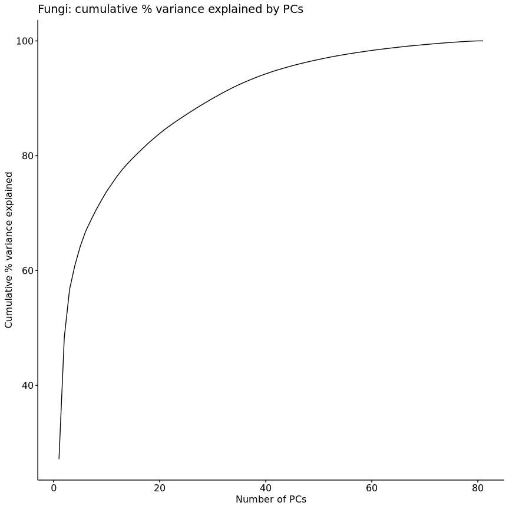

```r
# Cumulative percentage of variance explained
pca_cum_var <- data.frame(
  cumulative = cumsum(mypca$percentVar * 100),
  no = 1:length(mypca$percentVar)
)

# Plot cumulative percentage of variance explained
fun_cum_pca <- ggline(
  pca_cum_var, x = "no", y = "cumulative", plot_type = "l",
  xlab = "Number of PCs", ylab = "Cumulative % variance explained",
  title = "Fungi: cumulative % variance explained by PCs"
)
ggsave(filename = "fun_cum_pca.png", plot = fun_cum_pca, path = "figures/",)
fun_cum_pca
```

```r
pca_var <- data.frame(
  PC = paste0("PC", 1:n_pcs),
  perc_var = round(mypca$percentVar[1:n_pcs] * 100, 1)
)

pca_var %>%
  kbl() %>%
  kable_styling("striped", full_width = F)
```

| PC | perc_var |
| --- | --- |
| PC1 | 27.1 |
| PC2 | 21.2 |
| PC3 | 8.4 |
| PC4 | 4.2 |
| PC5 | 3.3 |
| PC6 | 2.6 |
| PC7 | 1.9 |
| PC8 | 1.8 |
| PC9 | 1.7 |
| PC10 | 1.6 |

#### ANOVA of first 10 PCs

```r
pca_summary <- apply(
  mypca$x[, 1:n_pcs], 2,
  function(x){
    summary(aov(update(formula, x ~ .), data = as.data.frame(cbind(x, colData(dds)))))
  }
)

pca_summary
```

```
# $PC1
#                    Df Sum Sq Mean Sq F value  Pr(>F)
# Site                2  71073   35537 238.166 < 2e-16 ***
# Storage             1     31      31   0.208 0.65102
# Scion               6    871     145   0.973 0.45635
# Site:Storage        2   2232    1116   7.480 0.00178 **
# Site:Scion         12   1299     108   0.726 0.71791
# Storage:Scion       6    696     116   0.777 0.59290
# Site:Storage:Scion 12   1781     148   0.994 0.47159
# Residuals          39   5819     149
# ---
# Signif. codes:  0 '***' 0.001 '**' 0.01 '*' 0.05 '.' 0.1 ' ' 1
#
# $PC2
#                    Df Sum Sq Mean Sq F value   Pr(>F)
# Site                2  41657   20829  62.213 7.35e-13 ***
# Storage             1    411     411   1.228  0.27459
# Scion               6    125      21   0.062  0.99892
# Site:Storage        2   5403    2701   8.069  0.00117 **
# Site:Scion         12   2269     189   0.565  0.85649
# Storage:Scion       6    416      69   0.207  0.97246
# Site:Storage:Scion 12   2080     173   0.518  0.89032
# Residuals          39  13057     335
# ---
# Signif. codes:  0 '***' 0.001 '**' 0.01 '*' 0.05 '.' 0.1 ' ' 1
#
# $PC3
#                    Df Sum Sq Mean Sq F value Pr(>F)
# Site                2   2091  1045.4   3.075 0.0575 .
# Storage             1    250   250.4   0.737 0.3960
# Scion               6    976   162.7   0.479 0.8202
# Site:Storage        2   1598   798.8   2.350 0.1087
# Site:Scion         12   3182   265.2   0.780 0.6668
# Storage:Scion       6   1399   233.2   0.686 0.6619
# Site:Storage:Scion 12   3176   264.7   0.779 0.6682
# Residuals          39  13257   339.9
# ---
# Signif. codes:  0 '***' 0.001 '**' 0.01 '*' 0.05 '.' 0.1 ' ' 1
#
# $PC4
```

[output cut: 66 more lines]

```
# Site:Storage:Scion 12  206.8    17.2   0.298   0.9860
# Residuals          39 2254.0    57.8
# ---
# Signif. codes:  0 '***' 0.001 '**' 0.01 '*' 0.05 '.' 0.1 ' ' 1
#
# $PC10
#                    Df Sum Sq Mean Sq F value Pr(>F)
# Site                2   17.2    8.62   0.107  0.898
# Storage             1   13.0   12.98   0.162  0.690
# Scion               6  279.3   46.55   0.580  0.744
# Site:Storage        2  112.7   56.35   0.702  0.502
# Site:Scion         12  544.6   45.38   0.566  0.856
# Storage:Scion       6   80.8   13.46   0.168  0.984
# Site:Storage:Scion 12  646.4   53.87   0.671  0.767
# Residuals          39 3129.1   80.23
```

#### Percent variation in first 10 PCs for each factor

```r
# Extract PC scores as a list of dataframes
pcas <- lapply(pca_summary, function(i) data.frame(unclass(i)))

# Merge into single dataframe
pcs_factors_tidy <- lapply(
  names(pcas),
  function(name) {
    pcas[[name]] %>%
    mutate(
      PC = name, #substring(name, 3),
      Factor = gsub(" ", "", rownames(pcas[[name]])),
      var = Sum.Sq / sum(pcas[[name]]$Sum.Sq) * 100,
      pc_var = subset(pca_var, PC == name)$"perc_var",
      total_var = var * pc_var / 100,
      sig = case_when(
        is.na(Pr..F.) ~ "",
        Pr..F. < 0.001 ~ "***",
        Pr..F. < 0.01 ~ "**",
        Pr..F. < 0.05 ~ "*",
        TRUE ~ ""
      ),
      variance = ifelse(
        total_var < 0.01, paste0("<0.01", sig),
        paste0(round(total_var, 2), sig)
      )
    )
  }
) %>% bind_rows() %>% data.table()

# Order PCs and factors
pcs_factors_tidy$PC <- factor(pcs_factors_tidy$PC, levels = paste0("PC", 1:n_pcs))
pcs_factors_tidy$Factor <- factor(pcs_factors_tidy$Factor, levels = unique(pcs_factors_tidy$Factor))

# Significant factors
pcs_factors_tidy[
  Pr..F. < 0.05,
  c("PC", "Factor", "Df", "F.value", "Pr..F.", "var", "pc_var", "total_var")
] %>%
  kbl() %>%
  kable_styling("striped", full_width = F)
```

| PC | Factor | Df | F.value | Pr..F. | var | pc_var | total_var |
| --- | --- | --- | --- | --- | --- | --- | --- |
| PC1 | Site | 2 | 238.165810 | 0.0000000 | 84.810927 | 27.1 | 22.9837611 |
| PC1 | Site:Storage | 2 | 7.479562 | 0.0017803 | 2.663475 | 27.1 | 0.7218016 |
| PC2 | Site | 2 | 62.212524 | 0.0000000 | 63.678672 | 21.2 | 13.4998786 |
| PC2 | Site:Storage | 2 | 8.068552 | 0.0011684 | 8.258702 | 21.2 | 1.7508448 |
| PC4 | Site | 2 | 5.485916 | 0.0079546 | 13.159308 | 4.2 | 0.5526910 |
| PC4 | Site:Storage | 2 | 3.942945 | 0.0275701 | 9.458115 | 4.2 | 0.3972408 |
| PC8 | Storage | 1 | 6.057208 | 0.0183793 | 7.474228 | 1.8 | 0.1345361 |
| PC8 | Site:Storage | 2 | 5.478399 | 0.0080014 | 13.520024 | 1.8 | 0.2433604 |
| PC9 | Site:Storage | 2 | 12.982328 | 0.0000477 | 29.133773 | 1.7 | 0.4952741 |

```r
# Table with factors as columns and PCs as rows
# pcs_factors <- dcast(pcs_factors_tidy, PC ~ Factor, value.var = "variance")
pcs_factors <- pcs_factors_tidy %>%
  select(PC, pc_var, Factor, variance) %>%
  spread(key = Factor, value = variance)

# Add a row with sum of each column by removing '<' and '*' and converting to numeric
pc_sums <- pcs_factors %>%
  mutate_all(~ gsub("[<|*]", "", .)) %>%
  mutate_all(as.numeric) %>%
  colSums()

pcs_factors %>%
  kbl() %>%
  kable_styling("striped", full_width = F)
```

| PC | pc_var | Site | Storage | Scion | Site:Storage | Site:Scion | Storage:Scion | Site:Storage:Scion | Residuals |
| --- | --- | --- | --- | --- | --- | --- | --- | --- | --- |
| PC1 | 27.1 | 22.98*** | 0.01 | 0.28 | 0.72** | 0.42 | 0.22 | 0.58 | 1.88 |
| PC2 | 21.2 | 13.5*** | 0.13 | 0.04 | 1.75** | 0.74 | 0.13 | 0.67 | 4.23 |
| PC3 | 8.4 | 0.68 | 0.08 | 0.32 | 0.52 | 1.03 | 0.45 | 1.03 | 4.29 |
| PC4 | 4.2 | 0.55** | 0.05 | 0.05 | 0.4* | 0.46 | 0.21 | 0.52 | 1.96 |
| PC5 | 3.3 | 0.08 | 0.15 | 0.11 | 0.1 | 0.42 | 0.17 | 0.22 | 2.05 |
| PC6 | 2.6 | 0.05 | 0.09 | 0.07 | 0.08 | 0.14 | 0.19 | 0.5 | 1.48 |
| PC7 | 1.9 | 0.01 | <0.01 | 0.22 | <0.01 | 0.33 | 0.08 | 0.26 | 0.98 |
| PC8 | 1.8 | <0.01 | 0.13* | 0.05 | 0.24** | 0.19 | 0.19 | 0.13 | 0.87 |
| PC9 | 1.7 | 0.02 | 0.07 | 0.08 | 0.5*** | 0.14 | 0.08 | 0.07 | 0.74 |
| PC10 | 1.6 | <0.01 | <0.01 | 0.09 | 0.04 | 0.18 | 0.03 | 0.21 | 1.04 |

```r
# save_kable(kable(pcs_factors, format = "pandoc"), "tables/FUN_pca_factors.docx")
```

#### PCA plot

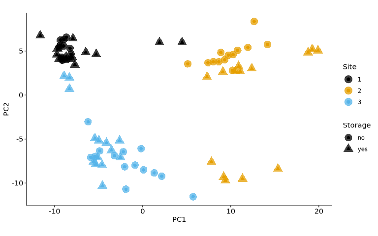

```r
fun_pca_plot <- plotOrd(
  fun_pca,
  colData(dds),
  design = "Site",
  shapes = "Storage",
  axes = c(1, 2),
  cbPalette = T,
  alpha = 0.75,
) # + facet_wrap(~facet)
#   geom_line(aes(group=facet),alpha=0.25,linetype=3,colour="#000000") +
#   theme(text = element_text(size=14))

ggsave(filename = "fun_pca_plot.png", plot = fun_pca_plot, path = "figures/")

fun_pca_plot
```

#### PCA sum of squares (% var)

```r
sum_squares <- apply(mypca$x, 2 ,function(x)
  summary(aov(update(formula, x ~ .), data = cbind(x, colData(dds))))[[1]][2]
)
sum_squares <- do.call(cbind, sum_squares)
x <- t(apply(sum_squares, 2, prop.table))
perVar <- x * mypca$percentVar
#colSums(perVar)
round(colSums(perVar) / sum(colSums(perVar)) * 100, 3)
```

```
# Site               Storage            Scion              Site:Storage
#             38.022              1.000              3.083              4.878
# Site:Scion         Storage:Scion      Site:Storage:Scion Residuals
#              7.803              4.057              8.281             32.876
```

### PCA with canker lesion counts

```r
pca_summary <- apply(
  mypca$x[, 1:n_pcs], 2,
  function(x){
    summary(aov(update(design_with_canker, x ~ .), data = as.data.frame(cbind(x, colData(dds)))))
  }
)

pca_summary
```

```
# $PC1
#                 Df Sum Sq Mean Sq F value  Pr(>F)
# Site             2  69121   34561 229.792 < 2e-16 ***
# Storage          1     78      78   0.517 0.47620
# Scion            6    793     132   0.879 0.51919
# Cankers          1    466     466   3.101 0.08609 .
# Site:Storage     2   1756     878   5.837 0.00606 **
# Site:Scion      12   1853     154   1.026 0.44497
# Storage:Scion    6    604     101   0.670 0.67448
# Site:Cankers     2     40      20   0.132 0.87642
# Storage:Cankers  1    116     116   0.772 0.38508
# Scion:Cankers    6    686     114   0.761 0.60518
# Residuals       39   5866     150
# ---
# Signif. codes:  0 '***' 0.001 '**' 0.01 '*' 0.05 '.' 0.1 ' ' 1
# 2 observations deleted due to missingness
#
# $PC2
#                 Df Sum Sq Mean Sq F value   Pr(>F)
# Site             2  42751   21376  72.560 7.18e-14 ***
# Storage          1    624     624   2.118 0.153610
# Scion            6    234      39   0.132 0.991345
# Cankers          1    439     439   1.491 0.229455
# Site:Storage     2   5049    2524   8.569 0.000823 ***
# Site:Scion      12   1761     147   0.498 0.903184
# Storage:Scion    6    633     105   0.358 0.900753
# Site:Cankers     2    652     326   1.106 0.340990
# Storage:Cankers  1     78      78   0.263 0.610901
# Scion:Cankers    6   1126     188   0.637 0.699825
# Residuals       39  11489     295
# ---
# Signif. codes:  0 '***' 0.001 '**' 0.01 '*' 0.05 '.' 0.1 ' ' 1
# 2 observations deleted due to missingness
#
# $PC3
#                 Df Sum Sq Mean Sq F value Pr(>F)
# Site             2   2617  1308.3   4.052 0.0252 *
# Storage          1    218   217.9   0.675 0.4164
# Scion            6   1456   242.6   0.751 0.6120
# Cankers          1     35    35.0   0.108 0.7437
```

[output cut: 110 more lines]

```
#
# $PC10
#                 Df Sum Sq Mean Sq F value Pr(>F)
# Site             2   11.8    5.89   0.073  0.929
# Storage          1   23.9   23.92   0.297  0.589
# Scion            6  309.2   51.53   0.641  0.697
# Cankers          1   11.8   11.82   0.147  0.704
# Site:Storage     2  120.7   60.37   0.751  0.479
# Site:Scion      12  478.8   39.90   0.496  0.904
# Storage:Scion    6  117.8   19.64   0.244  0.959
# Site:Cankers     2   33.3   16.67   0.207  0.814
# Storage:Cankers  1    0.5    0.55   0.007  0.935
# Scion:Cankers    6  509.2   84.87   1.055  0.406
# Residuals       39 3136.7   80.43
# 2 observations deleted due to missingness
```

```r
# Extract PC scores as a list of dataframes
pcas <- lapply(pca_summary, function(i) data.frame(unclass(i)))

# Merge into single dataframe
pcs_factors_tidy <- lapply(
  names(pcas),
  function(name) {
    pcas[[name]] %>%
    mutate(
      PC = name, #substring(name, 3),
      Factor = gsub(" ", "", rownames(pcas[[name]])),
      var = Sum.Sq / sum(pcas[[name]]$Sum.Sq) * 100,
      pc_var = subset(pca_var, PC == name)$"perc_var",
      total_var = var * pc_var / 100,
      sig = case_when(
        is.na(Pr..F.) ~ "",
        Pr..F. < 0.001 ~ "***",
        Pr..F. < 0.01 ~ "**",
        Pr..F. < 0.05 ~ "*",
        TRUE ~ ""
      ),
      variance = ifelse(
        total_var < 0.01, paste0("<0.01", sig),
        paste0(round(total_var, 2), sig)
      )
    )
  }
) %>% bind_rows() %>% data.table()

# Order PCs and factors
pcs_factors_tidy$PC <- factor(pcs_factors_tidy$PC, levels = paste0("PC", 1:n_pcs))
pcs_factors_tidy$Factor <- factor(pcs_factors_tidy$Factor, levels = unique(pcs_factors_tidy$Factor))

# Significant factors
pcs_factors_tidy[
  Pr..F. < 0.05,
  c("PC", "Factor", "Df", "F.value", "Pr..F.", "var", "pc_var", "total_var")
] %>%
  kbl() %>%
  kable_styling("striped", full_width = F)
```

| PC | Factor | Df | F.value | Pr..F. | var | pc_var | total_var |
| --- | --- | --- | --- | --- | --- | --- | --- |
| PC1 | Site | 2 | 229.792043 | 0.0000000 | 84.937120 | 27.1 | 23.0179596 |
| PC1 | Site:Storage | 2 | 5.837224 | 0.0060586 | 2.157590 | 27.1 | 0.5847069 |
| PC2 | Site | 2 | 72.559889 | 0.0000000 | 65.938449 | 21.2 | 13.9789512 |
| PC2 | Site:Storage | 2 | 8.569066 | 0.0008227 | 7.787097 | 21.2 | 1.6508646 |
| PC3 | Site | 2 | 4.052404 | 0.0251761 | 10.356904 | 8.4 | 0.8699800 |
| PC4 | Site | 2 | 4.319264 | 0.0202103 | 11.106999 | 4.2 | 0.4664940 |
| PC8 | Storage | 1 | 6.645691 | 0.0138323 | 7.653518 | 1.8 | 0.1377633 |
| PC8 | Site:Storage | 2 | 4.998939 | 0.0116762 | 11.514069 | 1.8 | 0.2072532 |
| PC9 | Storage | 1 | 4.114180 | 0.0493937 | 3.907370 | 1.7 | 0.0664253 |
| PC9 | Site:Storage | 2 | 16.075611 | 0.0000081 | 30.535060 | 1.7 | 0.5190960 |

```r
# Table with factors as columns and PCs as rows
# pcs_factors <- dcast(pcs_factors_tidy, PC ~ Factor, value.var = "variance")
pcs_factors <- pcs_factors_tidy %>%
  select(PC, pc_var, Factor, variance) %>%
  spread(key = Factor, value = variance)

# Add a row with sum of each column by removing '<' and '*' and converting to numeric
pc_sums <- pcs_factors %>%
  mutate_all(~ gsub("[<|*]", "", .)) %>%
  mutate_all(as.numeric) %>%
  colSums()

pcs_factors %>%
  kbl() %>%
  kable_styling("striped", full_width = F)
```

| PC | pc_var | Site | Storage | Scion | Cankers | Site:Storage | Site:Scion | Storage:Scion | Site:Cankers | Storage:Cankers | Scion:Cankers | Residuals |
| --- | --- | --- | --- | --- | --- | --- | --- | --- | --- | --- | --- | --- |
| PC1 | 27.1 | 23.02*** | 0.03 | 0.26 | 0.16 | 0.58** | 0.62 | 0.2 | 0.01 | 0.04 | 0.23 | 1.95 |
| PC2 | 21.2 | 13.98*** | 0.2 | 0.08 | 0.14 | 1.65*** | 0.58 | 0.21 | 0.21 | 0.03 | 0.37 | 3.76 |
| PC3 | 8.4 | 0.87* | 0.07 | 0.48 | 0.01 | 0.54 | 0.89 | 0.42 | 0.1 | 0.14 | 0.7 | 4.19 |
| PC4 | 4.2 | 0.47* | 0.03 | 0.14 | <0.01 | 0.34 | 0.38 | 0.21 | 0.08 | 0.07 | 0.38 | 2.11 |
| PC5 | 3.3 | 0.07 | 0.19 | 0.11 | 0.1 | 0.1 | 0.34 | 0.16 | 0.08 | 0.13 | 0.09 | 1.92 |
| PC6 | 2.6 | 0.05 | 0.09 | 0.07 | 0.02 | 0.11 | 0.15 | 0.17 | 0.2 | <0.01 | 0.25 | 1.48 |
| PC7 | 1.9 | 0.01 | <0.01 | 0.23 | <0.01 | <0.01 | 0.36 | 0.07 | <0.01 | <0.01 | 0.05 | 1.16 |
| PC8 | 1.8 | <0.01 | 0.14* | 0.05 | 0.03 | 0.21* | 0.19 | 0.19 | <0.01 | <0.01 | 0.17 | 0.81 |
| PC9 | 1.7 | 0.02 | 0.07* | 0.11 | <0.01 | 0.52*** | 0.15 | 0.08 | <0.01 | 0.01 | 0.1 | 0.63 |
| PC10 | 1.6 | <0.01 | <0.01 | 0.1 | <0.01 | 0.04 | 0.16 | 0.04 | 0.01 | <0.01 | 0.17 | 1.06 |

### ADONIS

```r
# Calculate Bray-Curtis distance matrix
vg <- vegdist(t(counts(dds, normalize = T)), method = "bray")

formula <- update(FULL_DESIGN, vg ~ .)

set.seed(sum(utf8ToInt("Hamish McLean")))
result <- adonis2(formula, colData(dds), permutations = 1000)
result
```

```
# Permutation test for adonis under reduced model
# Terms added sequentially (first to last)
# Permutation: free
# Number of permutations: 1000
#
# adonis2(formula = formula, data = colData(dds), permutations = 1000)
#                    Df SumOfSqs      R2       F   Pr(>F)
# Site                2   6.5423 0.31527 18.6694 0.000999 ***
# Storage             1   0.4053 0.01953  2.3133 0.014985 *
# Scion               6   0.9096 0.04383  0.8652 0.769231
# Site:Storage        2   0.7206 0.03472  2.0562 0.005994 **
# Site:Scion         12   2.1487 0.10354  1.0219 0.424575
# Storage:Scion       6   1.1647 0.05613  1.1079 0.278721
# Site:Storage:Scion 12   2.0269 0.09768  0.9640 0.580420
# Residual           39   6.8334 0.32930
# Total              80  20.7514 1.00000
# ---
# Signif. codes:  0 '***' 0.001 '**' 0.01 '*' 0.05 '.' 0.1 ' ' 1
```

```r
df <- result %>% data.frame()
df$Perc.Var <- df$SumOfSqs / df["Total", "SumOfSqs"] * 100
df %>%
  kbl() %>%
  kable_styling("striped", full_width = F)
```

|  | Df | SumOfSqs | R2 | F | Pr..F. | Perc.Var |
| --- | --- | --- | --- | --- | --- | --- |
| Site | 2 | 6.5423049 | 0.3152702 | 18.6694186 | 0.0009990 | 31.527021 |
| Storage | 1 | 0.4053241 | 0.0195324 | 2.3133026 | 0.0149850 | 1.953235 |
| Scion | 6 | 0.9095936 | 0.0438328 | 0.8652192 | 0.7692308 | 4.383283 |
| Site:Storage | 2 | 0.7205681 | 0.0347238 | 2.0562460 | 0.0059940 | 3.472380 |
| Site:Scion | 12 | 2.1486813 | 0.1035438 | 1.0219291 | 0.4245754 | 10.354382 |
| Storage:Scion | 6 | 1.1646804 | 0.0561253 | 1.1078616 | 0.2787213 | 5.612533 |
| Site:Storage:Scion | 12 | 2.0269039 | 0.0976754 | 0.9640108 | 0.5804196 | 9.767543 |
| Residual | 39 | 6.8333647 | 0.3292962 | NA | NA | 32.929623 |
| Total | 80 | 20.7514210 | 1.0000000 | NA | NA | 100.000000 |

#### ADONIS with canker

```r
missing <- rownames(colData[is.na(colData$Cankers), ])
# Calculate Bray-Curtis distance matrix
vg_canker <- vegdist(t(counts(dds, normalize = T)[, !colnames(counts(dds)) %in% missing]), method = "bray")

formula <- update(design_with_canker, vg_canker ~ .)

set.seed(sum(utf8ToInt("Hamish McLean")))
result <- adonis2(formula, colData[!is.na(colData$Cankers), ], permutations = 1000)
result
```

```
# Permutation test for adonis under reduced model
# Terms added sequentially (first to last)
# Permutation: free
# Number of permutations: 1000
#
# adonis2(formula = formula, data = colData[!is.na(colData$Cankers), ], permutations = 1000)
#                 Df SumOfSqs      R2       F   Pr(>F)
# Site             2   6.3619 0.31441 17.5313 0.000999 ***
# Storage          1   0.4141 0.02047  2.2822 0.010989 *
# Scion            6   0.9411 0.04651  0.8645 0.753247
# Cankers          1   0.1250 0.00618  0.6887 0.782218
# Site:Storage     2   0.6798 0.03359  1.8732 0.007992 **
# Site:Scion      12   2.0945 0.10351  0.9620 0.586414
# Storage:Scion    6   1.1682 0.05773  1.0731 0.343656
# Site:Cankers     2   0.3686 0.01821  1.0156 0.424575
# Storage:Cankers  1   0.1206 0.00596  0.6649 0.799201
# Scion:Cankers    6   0.8842 0.04370  0.8122 0.874126
# Residual        39   7.0764 0.34972
# Total           78  20.2344 1.00000
# ---
# Signif. codes:  0 '***' 0.001 '**' 0.01 '*' 0.05 '.' 0.1 ' ' 1
```

```r
df <- result %>% data.frame()
df$Perc.Var <- df$SumOfSqs / df["Total", "SumOfSqs"] * 100
df %>%
  kbl() %>%
  kable_styling("striped", full_width = F)
```

|  | Df | SumOfSqs | R2 | F | Pr..F. | Perc.Var |
| --- | --- | --- | --- | --- | --- | --- |
| Site | 2 | 6.3619296 | 0.3144108 | 17.5312594 | 0.0009990 | 31.4410824 |
| Storage | 1 | 0.4141019 | 0.0204652 | 2.2822411 | 0.0109890 | 2.0465195 |
| Scion | 6 | 0.9411190 | 0.0465107 | 0.8644652 | 0.7532468 | 4.6510730 |
| Cankers | 1 | 0.1249674 | 0.0061760 | 0.6887333 | 0.7822178 | 0.6175974 |
| Site:Storage | 2 | 0.6797549 | 0.0335939 | 1.8731675 | 0.0079920 | 3.3593944 |
| Site:Scion | 12 | 2.0945273 | 0.1035129 | 0.9619645 | 0.5864136 | 10.3512943 |
| Storage:Scion | 6 | 1.1682282 | 0.0577346 | 1.0730765 | 0.3436563 | 5.7734622 |
| Site:Cankers | 2 | 0.3685599 | 0.0182145 | 1.0156224 | 0.4245754 | 1.8214475 |
| Storage:Cankers | 1 | 0.1206467 | 0.0059624 | 0.6649207 | 0.7992008 | 0.5962443 |
| Scion:Cankers | 6 | 0.8842463 | 0.0437000 | 0.8122248 | 0.8741259 | 4.3700046 |
| Residual | 39 | 7.0763671 | 0.3497188 | NA | NA | 34.9718804 |
| Total | 78 | 20.2344485 | 1.0000000 | NA | NA | 100.0000000 |

#### Bray-Curtis canker correlation

```r
# Convert Bray-Curtis distance matrix to table
bc <- as.matrix(vg)
bc[lower.tri(bc, diag = TRUE)] <- NA
bc <- melt(bc, value.name = "BC", na.rm = TRUE)

# Calculate canker count difference matrix
cankers <- colData$Cankers
cankers_diff <- abs(outer(cankers, cankers, "-"))
rownames(cankers_diff) <- rownames(colData)
colnames(cankers_diff) <- rownames(colData)
cankers_diff[lower.tri(cankers_diff, diag = TRUE)] <- NA
cankers_diff <- melt(cankers_diff, value.name = "Cankers", na.rm = TRUE)

# Merge Bray-Curtis and canker count difference matrices
bc_cankers <- merge(bc, cankers_diff, by = c("Var1", "Var2"))

# Calculate correlation between Bray-Curtis and canker count difference
cor.test(bc_cankers$BC, bc_cankers$Cankers, method = "spearman")
```

```
#
#   Spearman's rank correlation rho
#
# data:  bc_cankers$BC and bc_cankers$Cankers
# S = 4443807996, p-value = 9.05e-07
# alternative hypothesis: true rho is not equal to 0
# sample estimates:
#        rho
# 0.08834297
```

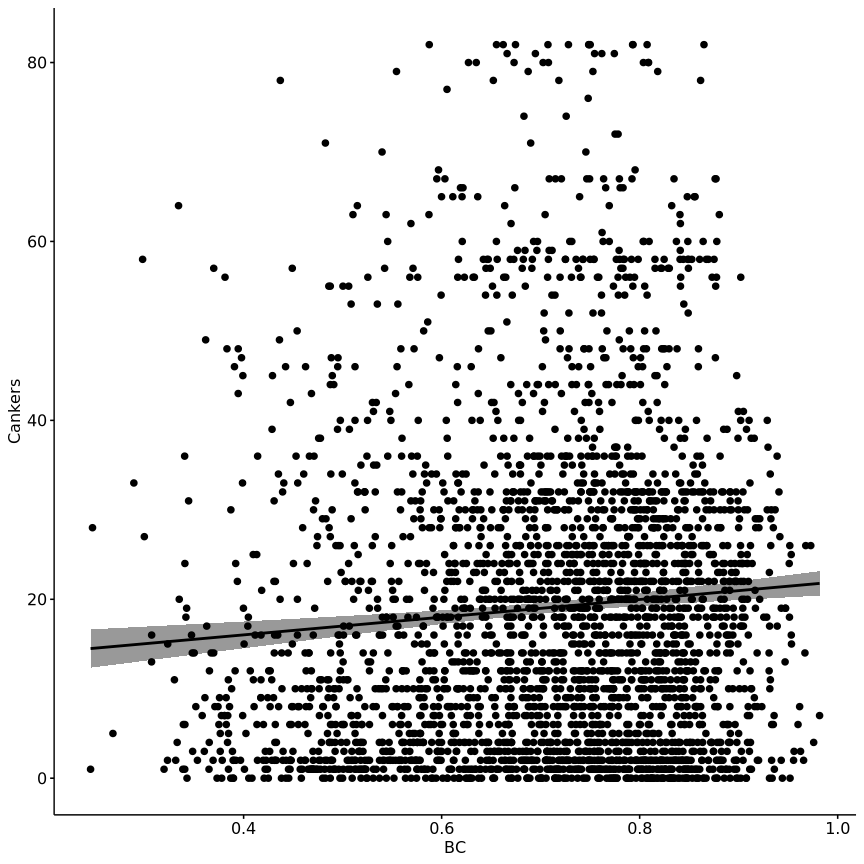

```r
# Plot correlation between Bray-Curtis and canker count difference
ggscatter(bc_cankers, x = "BC", y = "Cankers", add = "reg.line", conf.int = TRUE)
```

### NMDS ordination

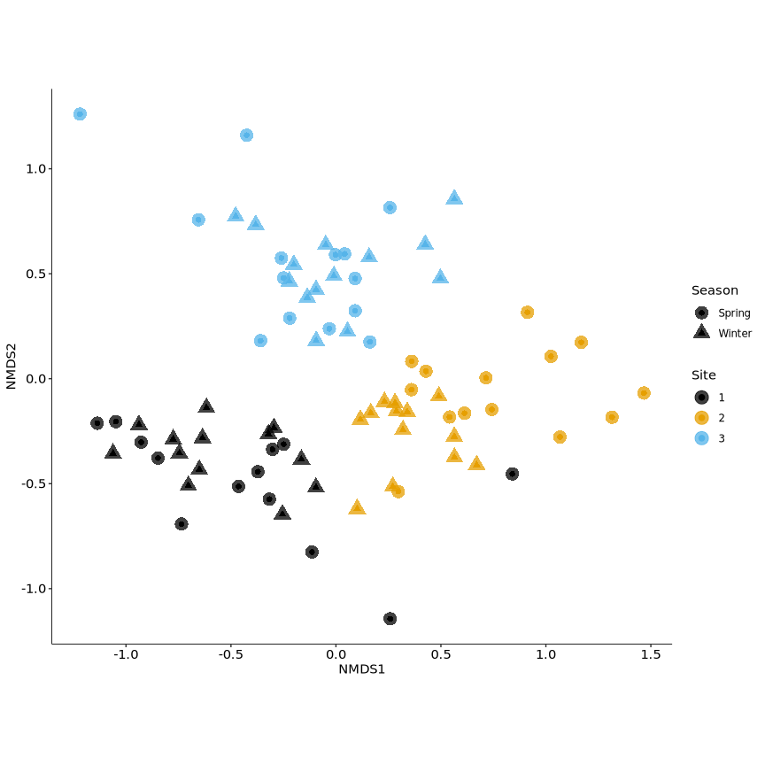

```r
set.seed(sum(utf8ToInt("Hamish McLean")))
ord <- metaMDS(vg, trace=0)
#sratmax=20000,maxit=20000,try = 177, trymax = 177

fun_nmds <- scores(ord)

fun_nmds_plot <- plotOrd(
  fun_nmds, colData(dds),
  design = "Site",
  shape = "Season",
  alpha = 0.75, cbPalette = T
) #+ theme(text = element_text(size = 14))

ggsave(filename = "fun_nmds_plot.png", plot = fun_nmds_plot, path = "figures/")

fun_nmds_plot
```

#### NMDS with canker counts

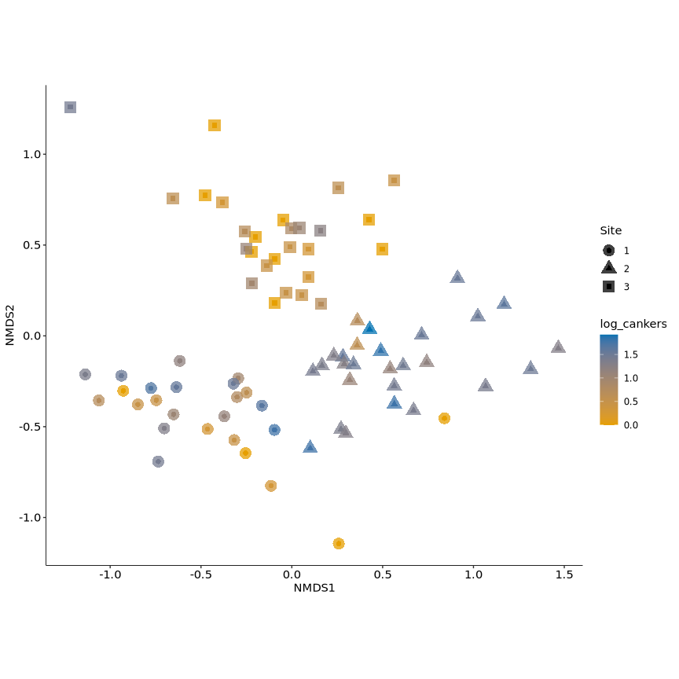

```r
# Rownames for which Cankers is NA
missing <- rownames(colData[is.na(colData$Cankers), ])

colData$log_cankers <- log10(colData$Cankers + 1)

fun_nmds_canker_plot <- plotOrd(
  fun_nmds, colData,
  design = "log_cankers",
  shape = "Site",
  continuous = TRUE,
  colourScale = c(low = "#E69F00", high = "#0072B2"),
  legendDesign = "colourbar",
  exclude = missing,
  alpha = 0.75, cbPalette = TRUE
)

fun_nmds_canker_plot
```

## ASV abundance

### Explore distribution of ASV read counts

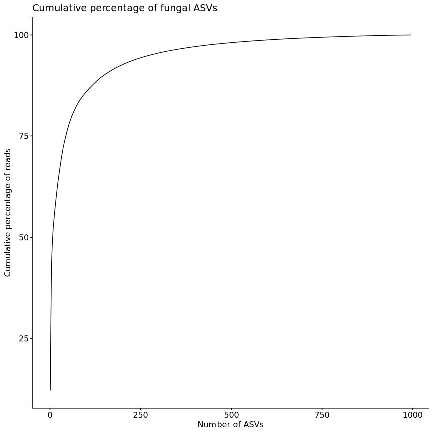

```r
# Extract normalised counts from DESeq object
asv_counts <- counts(dds, normalize = T) %>% as.data.frame()

# Sum ASV counts across samples
total_asv_counts <- rowSums(asv_counts)

# Sort ASVs by abundance
total_asv_counts <- total_asv_counts[order(total_asv_counts, decreasing = T)]

# Caculate cumulative percentage
cumulative <- data.frame(
  cumulative = cumsum(total_asv_counts) / sum(total_asv_counts) * 100,
  no = seq_along(total_asv_counts)
)

# Plot cumulative percentage of ASVs
fun_cum_asv <- ggline(
  data = cumulative, x = "no", y = "cumulative",
  plot_type = "l", palette = cbPalette,
  title = "Cumulative percentage of fungal ASVs", xlab = "Number of ASVs",
  ylab = "Cumulative percentage of reads"
)
ggsave(filename = "fun_cum_asv.png", plot = fun_cum_asv, path = "figures/")
fun_cum_asv
```

```r
# Find the number of ASVs that account for 50%, 80%, and 99% of total reads
cat(
  "Number of ASVs that account for 50%, 80%, 90%, and 99% of total reads", "\n\n",
  "50%:", sum(cumulative <= 50), "\n",
  "80%:", sum(cumulative <= 80), "\n",
  "90%:", sum(cumulative <= 90), "\n",
  "99%:", sum(cumulative <= 99), "\n"
)
```

```
# Number of ASVs that account for 50%, 80%, 90%, and 99% of total reads
#
#  50%: 57
#  80%: 140
#  90%: 238
#  99%: 741
```

```r
# Find the cumulative percentage accounted for by top x ASVs
cat(
  "Percentage of total reads accounted for by the top 100, 200,and 500 ASVs:", "\n\n",
  "100:", round(cumulative[cumulative$no == 100, "cumulative"], 1) , "\n",
  "200:", round(cumulative[cumulative$no == 200, "cumulative"], 1) , "\n",
  "500:", round(cumulative[cumulative$no == 500, "cumulative"], 1) , "\n"
)
```

```
# Percentage of total reads accounted for by the top 100, 200,and 500 ASVs:
#
#  100: 85.9
#  200: 92.6
#  500: 98.1
```

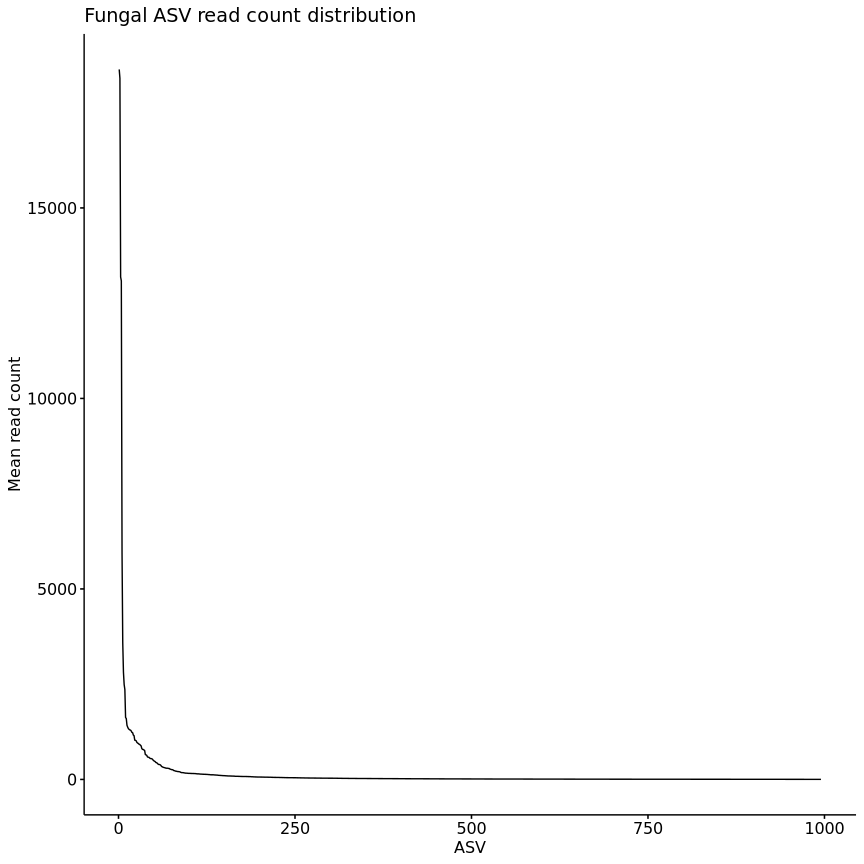

```r
# Average ASV counts in order
mean_asv_counts <- rowMeans(asv_counts)
mean_asv_counts <- mean_asv_counts[order(mean_asv_counts, decreasing = T)]

# Plot read count distribution
fun_asv_counts <- ggline(
  data = data.frame(ASV = seq_along(mean_asv_counts), counts = mean_asv_counts),
  x = "ASV", y = "counts", plot_type = "l",
  title = "Fungal ASV read count distribution", xlab = "ASV", ylab = "Mean read count"
)
ggsave(filename = "fun_asv_counts.png", plot = fun_asv_counts, path = "figures/")
fun_asv_counts
```

```r
# Number of ASVs with mean read count > 100, 200, and 500
cat(
  "Number of ASVs with mean read count > 100, 200, and 500", "\n\n",
  "100:", sum(rowMeans(asv_counts) > 100), "\n",
  "200:", sum(rowMeans(asv_counts) > 200), "\n",
  "500:", sum(rowMeans(asv_counts) > 500), "\n"
)
```

```
# Number of ASVs with mean read count > 100, 200, and 500
#
#  100: 147
#  200: 86
#  500: 49
```

### Filter top ASVs with 100 % of reads

```r
# Filter the top x abundant ASVs by the sum of their normalised counts
# top_asvs <- asv_counts[order(rowSums(asv_counts), decreasing = T)[1:DIFFOTU], ]

# Filter ASVs with mean read count > 100
# top_asvs <- asv_counts[rowMeans(asv_counts) > 100, ]

# Filter top ASVs with 90% of reads
# top_asvs <- asv_counts[filter_otus(asv_counts, FUNASVFILTER), ]

# No filtering
top_asvs <- asv_counts

# Check that sample names match
identical(names(top_asvs), rownames(colData))
```

```
# [1] TRUE
```

```r
# Extract taxonomic data for top ASVs
top_taxa <- taxData[rownames(top_asvs), ]

# Log transform normalised counts
# top_asvs <- log10(top_asvs + 1)

top_asv_data <- data.frame(t(top_asvs))
top_asv_ids <- rownames(top_asvs)

# Check that sample names match
identical(rownames(top_asv_data), rownames(colData))
```

```
# [1] TRUE
```

```r
# Add sample metadata to top ASV data
top_asv_data <- merge(top_asv_data, colData, by = 0) %>% column_to_rownames("Row.names")
```

### Effect of design factors on abundance of top ASVs

Effect of Site, Scion, and Storage on abundance of top ASVs

```r
# ANOVA of top ASVs
asv_lm_anova <- function(asv, formula, data) {
  f = update(formula, paste0("log(", asv, " + 1) ~ ."))
  a = aov(f, data = data)
  a = a %>% summary() %>% unclass() %>% data.frame()
  return(a)
}

# Negative binomial regression model
asv_negbin_anova <- function(asv, formula, data) {
  f = update(formula, paste0(asv, " ~ ."))
  m = glm.nb(f, data = data)
  a = anova(m, test = "Chisq") %>% data.frame()
  return(a)
}

formula <- FULL_DESIGN

# Full design model does not converge
# formula <- y ~ site + Scion + Storage + site:Scion + site:Storage

# Extend ANOVA results with ASV metadata
extend_asv_anova <- function(anova_result, asv) {
  anova_result %>% mutate(
    ASV = asv,
    Taxonomy = taxData[asv, "rank"],
    Abundance = round(mean(top_asv_data[[asv]]), 3),
    Factor = gsub(" ", "", rownames(anova_result)),
    var = Sum.Sq / sum(anova_result$Sum.Sq) * 100,
    sig = case_when(
      is.na(Pr..F.) ~ "",
      Pr..F. < 0.001 ~ "***",
      Pr..F. < 0.01 ~ "**",
      Pr..F. < 0.05 ~ "*",
      TRUE ~ ""
    )#,
    # Variance = ifelse(
    #   perc_var < 0.01, paste0("<0.01", sig),
    #   paste0(round(perc_var, 2), sig)
    # )
  )
}

# Perform ANOVA on list of top ASVs
top_asvs_anova_results <- lapply(
  top_asv_ids,
  function(asv) {
    asv_lm_anova(asv, formula, top_asv_data) %>%
    extend_asv_anova(asv)
  }
) %>% bind_rows() %>% data.table()

# Group by factor and adjust p-values
top_asvs_anova_results <- top_asvs_anova_results %>%
  group_by(Factor) %>%
  mutate(p.adj = p.adjust(`Pr..F.`, method = "BH")) %>%
  data.table()

# Order factors by original order
top_asvs_anova_results$Factor <- factor(top_asvs_anova_results$Factor, levels = unique(top_asvs_anova_results$Factor))

# Summary of top ASV ANOVA results
top_asvs_anova_summary <- top_asvs_anova_results %>%
  select(ASV, Taxonomy, Abundance, Factor, var, p.adj) %>%
  pivot_wider(names_from = Factor, values_from = c(var, p.adj), names_glue = "{Factor}_{.value}") %>%
  select(
    ASV, Taxonomy, Abundance, Site_var, Site_p.adj, Storage_var, Storage_p.adj,
    Scion_var, Scion_p.adj, "Site:Storage_var", "Site:Storage_p.adj", "Site:Scion_var",
    "Site:Scion_p.adj", "Storage:Scion_var", "Storage:Scion_p.adj", "Site:Storage:Scion_var",
    "Site:Storage:Scion_p.adj"
  ) %>%
  data.table()

# top_asvs_anova_summary %>%
#   kbl() %>%
#   kable_styling("striped", full_width = F)

cat(
  "Number of ASVs with statistically significant (*P* < 0.05) adjusted p-values", "\n\n",
  "Site:", nrow(top_asvs_anova_results[Factor == "Site" & p.adj < 0.05, ]), "\n",
  "Storage:", nrow(top_asvs_anova_results[Factor == "Storage" & p.adj < 0.05, ]), "\n",
  "Scion:", nrow(top_asvs_anova_results[Factor == "Scion" & p.adj < 0.05, ]), "\n",
  "Site:Storage:", nrow(top_asvs_anova_results[Factor == "Site:Storage" & p.adj < 0.05, ]), "\n",
  "Site:Scion:", nrow(top_asvs_anova_results[Factor == "Site:Scion" & p.adj < 0.05, ]), "\n",
  "Storage:Scion:", nrow(top_asvs_anova_results[Factor == "Storage:Scion" & p.adj < 0.05, ]), "\n",
  "Site:Storage:Scion:", nrow(top_asvs_anova_results[Factor == "Site:Storage:Scion" & p.adj < 0.05, ]), "\n\n",
  "Total ASVs:", length(unique(top_asvs_anova_results$ASV)), "\n\n"
)

# Filter by significant effect of scion and its interactions
scion_asvs <- top_asvs_anova_results[grepl("Scion", Factor) & p.adj < 0.05, ]

# scion_asvs %>%
#   kbl() %>%
#   kable_styling("striped", full_width = F)

cat(
  length(unique(scion_asvs$ASV)),
  "ASVs with significant (*P* < 0.05) adjusted p-values for the effect of Scion and its interactions.", "\n\n"
)

# Summary of ASVs with significant Scion effect
fun_significant_scion <- top_asvs_anova_summary[ASV %in% scion_asvs$ASV, ] %>%
  arrange(desc(Abundance))

# kbl(fun_significant_scion) %>%
#   kable_styling("striped")

kbl(fun_significant_scion) %>%
  kable_styling("striped") %>%
  save_kable("tables/FUN_scion_asvs.html")

top_asvs_anova_summary %>%
  arrange(desc(Abundance)) %>%
  kbl() %>%
  kable_styling("striped") %>%
  save_kable("tables/FUN_all_asvs.html")
```

[output not shown]

```r
# Export significant ASVs as fasta

# Read FUN ASVs
FUN_asvs <- read.fasta("data/FUN.zotus.fa")
# Replace 'OTU' with 'ASV' in sequence names
names(FUN_asvs) <- gsub("OTU", "ASV", names(FUN_asvs))

# Write significant ASVs to fasta
write.fasta(
  sequences = FUN_asvs[scion_asvs$ASV],
  names = paste(scion_asvs$ASV, taxData[scion_asvs$ASV, "rank"]),
  file = "fasta/FUN_scion_asvs.fasta"
)
```

### Effect of design factors and canker counts on abundance of top ASVs

```r
# ANOVA of top ASVs
asv_lm_anova_canker <- function(asv, formula, data) {
  f = update(formula, paste0("log(", asv, " + 1) ~ ."))
  a = aov(f, data = data)
  df = a %>% summary() %>% unclass() %>% data.frame()
  df[4, "coef"] <- coef(a)["Cankers"]
  return(df)
}

# Extend ANOVA results with ASV metadata
extend_asv_anova_canker <- function(anova_result, asv) {
  anova_result %>% mutate(
    ASV = asv,
    Taxonomy = taxData[asv, "rank"],
    Abundance = round(mean(top_asv_data[[asv]]), 3),
    Factor = gsub(" ", "", rownames(anova_result)),
    var = Sum.Sq / sum(anova_result$Sum.Sq) * 100
    # coef = anova_result$coef
  )
}

formula <- design_with_canker

# Perform ANOVA on list of top ASVs
asv_canker_anova_results <- lapply(
  top_asv_ids,
  function(asv) {
    asv_lm_anova_canker(asv, formula, top_asv_data) %>%
    extend_asv_anova_canker(asv)
  }
) %>% bind_rows() %>% data.table()

# Group by factor and adjust p-values
asv_canker_anova_results <- asv_canker_anova_results %>%
  group_by(Factor) %>%
  mutate(p.adj = p.adjust(`Pr..F.`, method = "BH")) %>%
  data.table()

# Order factors by original order
asv_canker_anova_results$Factor <- factor(asv_canker_anova_results$Factor, levels = unique(asv_canker_anova_results$Factor))

# Summary of top ASV ANOVA results
asv_canker_anova_summary <- asv_canker_anova_results %>%
  select(ASV, Taxonomy, Abundance, Factor, var, p.adj, coef) %>%
  pivot_wider(names_from = Factor, values_from = c(var, p.adj, coef), names_glue = "{Factor}_{.value}") %>%
  select(
    ASV, Taxonomy, Abundance,
    Site_var, Site_p.adj, Storage_var, Storage_p.adj,
    Scion_var, Scion_p.adj, Cankers_var, Cankers_p.adj,
    "Site:Storage_var", "Site:Storage_p.adj",
    "Site:Scion_var", "Site:Scion_p.adj",
    "Storage:Scion_var", "Storage:Scion_p.adj",
    "Site:Cankers_var", "Site:Cankers_p.adj",
    "Storage:Cankers_var", "Storage:Cankers_p.adj",
    "Scion:Cankers_var", "Scion:Cankers_p.adj",
    "Cankers_coef"
    # "Site:Storage:Scion_var", "Site:Storage:Scion_p.adj",
    # "Site:Storage:Cankers_var", "Site:Storage:Cankers_p.adj",
    # "Site:Storage:Scion:Cankers_var", "Site:Storage:Scion:Cankers_p.adj"
  ) %>%
  data.table()

cat(
  "Number of ASVs with statistically significant (*P* < 0.05) adjusted p-values", "\n\n",
  "Site:", nrow(asv_canker_anova_results[Factor == "Site" & p.adj < 0.05, ]), "\n",
  "Storage:", nrow(asv_canker_anova_results[Factor == "Storage" & p.adj < 0.05, ]), "\n",
  "Scion:", nrow(asv_canker_anova_results[Factor == "Scion" & p.adj < 0.05, ]), "\n",
  "Cankers:", nrow(asv_canker_anova_results[Factor == "Cankers" & p.adj < 0.05, ]), "\n",
  "Site:Storage:", nrow(asv_canker_anova_results[Factor == "Site:Storage" & p.adj < 0.05, ]), "\n",
  "Site:Scion:", nrow(asv_canker_anova_results[Factor == "Site:Scion" & p.adj < 0.05, ]), "\n",
  "Storage:Scion:", nrow(asv_canker_anova_results[Factor == "Storage:Scion" & p.adj < 0.05, ]), "\n",
  "Site:Cankers:", nrow(asv_canker_anova_results[Factor == "Site:Cankers" & p.adj < 0.05, ]), "\n",
  "Storage:Cankers:", nrow(asv_canker_anova_results[Factor == "Storage:Cankers" & p.adj < 0.05, ]), "\n",
  "Scion:Cankers:", nrow(asv_canker_anova_results[Factor == "Scion:Cankers" & p.adj < 0.05, ]), "\n",
  "Total ASVs:", length(unique(asv_canker_anova_results$ASV)), "\n\n"
)

# Filter by significant effect of scion and its interactions
canker_asvs <- asv_canker_anova_results[grepl("Cankers", Factor) & p.adj < 0.05, ]

# canker_asvs %>%
#   kbl() %>%
#   kable_styling("striped", full_width = F)

cat(
  length(unique(canker_asvs$ASV)),
  "ASVs with significant (*P* < 0.05) adjusted p-values for the effect of Cankers and its interactions.", "\n\n"
)

# Summary of ASVs with significant Scion effect
fun_significant_canker <- asv_canker_anova_summary[ASV %in% canker_asvs$ASV, ] %>%
  arrange(desc(Abundance))

kbl(fun_significant_canker) %>%
  kable_styling("striped") %>%
  save_kable("tables/FUN_asvs_design_canker.html")

asv_canker_anova_summary %>%
  arrange(desc(Abundance)) %>%
  kbl() %>%
  kable_styling("striped") %>%
  save_kable("tables/FUN_asvs_design_canker_all.html")
```

[output not shown]

## Canker counts

Testing the effects of of total abundance, ASV abundance, α-diversity, and β-diversity on canker counts.

This uses a nested negative binomial regression model.

The base model for canker counts uses the formula: Cankers ~ Site * Storage * Scion.

```r
# Filter out samples with missing canker count
canker_abundance_data <- colData[complete.cases(colData$Cankers), ]

# Base model
# canker_design <- "Cankers ~ Site * Storage * Scion"
base_model <- glm.nb(canker_design, data = canker_abundance_data)

# Abundance model
abundance_design <- paste(canker_design, "+ log(copy_number)")
abundance_model <- glm.nb(abundance_design, data = canker_abundance_data)

# ANOVA of abundance with canker count
anova(base_model, abundance_model) %>%
  kbl() %>%
  kable_styling("striped")
```

| Model | theta | Resid. df | 2 x log-lik. | Test | df | LR stat. | Pr(Chi) |
| --- | --- | --- | --- | --- | --- | --- | --- |
| Site * Storage * Scion | 2.595139 | 37 | -484.7664 |  | NA | NA | NA |
| Site * Storage * Scion + log(copy_number) | 2.611957 | 36 | -483.7606 | 1 vs 2 | 1 | 1.005758 | 0.3159211 |

### Effect of ASV abundance on canker count

```r
# Filter out samples with missing canker count
canker_top_asv_data <- top_asv_data[complete.cases(top_asv_data$Cankers), ]
# all.equal(top_asv_data[c("Site", "Storage", "Scion", "Cankers")],cankers)

# Base model design
canker_design <- "Cankers ~ Site * Storage * Scion"

# Base model with ASV abundance data
base_model <- glm.nb(canker_design, data = canker_top_asv_data)

# Fits glm.nb model and returns a list of the model and warnings
glm.nb_with_warnings <- function(f, data) {
  m = tryCatch(
    {
      list(
        fit = glm.nb(f, data = data),
        warning = NA
      )
    },
    warning = function(w) {
      list(
        fit = glm.nb(f, data = data),
        warning = paste(conditionMessage(w), collapse = ", ")
      )
    }
  )
  return(m)
}

# ANOVA of top ASVs with canker count
asv_canker_anova <- function(asv, design, base_model, data) {
  tryCatch({
    log_asv = paste0("log(", asv, " + 1)")
    f = paste(design, "+", log_asv)#, "+", log_asv, ":Site")
    m = glm.nb_with_warnings(f, data)
    a = anova(base_model, m$fit) %>% data.frame()
    b = suppressWarnings(anova(m$fit)) %>% data.frame()
    total_deviance = sum(b$Deviance, na.rm = T) + tail(b$Resid..Dev, 1)
    d = data.frame(
      ASV = asv,
      Taxonomy = taxData[asv, "rank"],
      Abundance = round(mean(data[[asv]]), 3),
      coef = round(m$fit$coefficients[log_asv], 3),
      var = round(b[log_asv, 'Deviance'] / total_deviance * 100, 3),
      p = a[2, 'Pr.Chi.'],
      warning = m$warning
    )
    return(d)
  }, warning = function(w) {
    return(data.frame(
      ASV = asv,
      Taxonomy = taxData[asv, "rank"],
      Abundance = round(mean(data[[asv]])),
      coef = NA,
      var = NA,
      p = NA,
      warning = paste("Warning: ", conditionMessage(w))
    ))
  }, error = function(e) {
    return(data.frame(
      ASV = asv,
      Taxonomy = taxData[asv, "rank"],
      Abundance = round(mean(data[[asv]])),
      coef = NA,
      var = NA,
      p = NA,
      warning = paste("Error: ", conditionMessage(e))
    ))
  })
}

# Effect of ASV abundance on canker count for top ASVs
asv_canker_results <- lapply(
  top_asv_ids,
  function(x) asv_canker_anova(x, canker_design, base_model, canker_top_asv_data)
) %>% bind_rows() %>% data.table()

# Adjust p-values for multiple testing
asv_canker_results$p_adjusted <- p.adjust(asv_canker_results$p, method = "BH")

# Summary of ASVs with statistically significant (*P* < 0.05) adjusted p-values
cat(
  nrow(asv_canker_results[p_adjusted < 0.05, ]), "of", nrow(asv_canker_results),
  "ASVs have statistically significant (*P* < 0.05) adjusted p-values\n\n"
)

fun_sig_canker_asvs <- asv_canker_results[p_adjusted < 0.05, ] %>%
  arrange(desc(Abundance))

# kbl(fun_sig_canker_asvs) %>%
#   kable_styling("striped")

kbl(fun_sig_canker_asvs) %>%
  kable_styling("striped") %>%
  save_kable("tables/FUN_canker_asvs.html")

cat(
  "\nSignificant canker bacterial ASVs\n",
  "\nTotal ASVs: ", nrow(asv_canker_results),
  "\nWarnings: ", nrow(asv_canker_results[!is.na(warning)]),
  "\nTotal ASVs without warnings: ", nrow(asv_canker_results[is.na(warning)]),
  "\nTotal significant ASVs: ", nrow(asv_canker_results[p_adjusted < 0.05]),
  "\nASVs with negative effect: ", nrow(asv_canker_results[p_adjusted < 0.05 & coef < 0]),
  "\nASVs with positive effect: ", nrow(asv_canker_results[p_adjusted < 0.05 & coef > 0]), "\n"
)
```

[output not shown]

#### Effect of ASV abundance on canker count per site

Filter top ASVs with 100 % of reads per site and test the effect of ASV abundance on canker count per site.

```r
# For each site, select top ASVs with 90% of reads
top_asvs_per_site <- lapply(
  unique(colData$Site),
  function(site) {
    samples <- filter(colData, Site == site)
    top_asv_data <- select(asv_counts, rownames(samples))
    # top_asvs <- filter(top_asv_data, rowMeans(top_asv_data) > 100)
    # top_asvs <- top_asv_data[filter_otus(top_asv_data, FUNASVFILTER), ]
    top_asvs <- top_asv_data[rowSums(top_asv_data) > 0, ]
    top_asv_ids <- rownames(top_asvs)
    top_asvs <- data.frame(t(top_asvs)) %>% merge(samples, by = 0) %>% column_to_rownames("Row.names")
    top_asvs <- top_asvs[complete.cases(top_asvs$Cankers), ]
    return(list(asvs = top_asv_ids, data = top_asvs))
  }
)

# Summary of top ASVs per site
data.table(
  Site = 1:3,
  topASVs = sapply(top_asvs_per_site, function(x) length(x$asvs)),
  totalASVs = sapply(top_asvs_per_site, function(x) sum(rowSums(asv_counts[, rownames(x$data)]) > 0, na.rm = TRUE)),
  topreads = sapply(top_asvs_per_site, function(x) sum(select(x$data, starts_with("ASV")))),
  totalreads = sapply(top_asvs_per_site, function(x) sum(asv_counts[, rownames(x$data)]))
) %>% mutate(
  "ASV%" = round(topASVs / totalASVs * 100),
  "Read%" = round(topreads / totalreads * 100)
) %>% kbl() %>% kable_styling("striped")

canker_site_design <- "Cankers ~ Storage * Scion"

# ANOVA of ASV abundance with canker count per ASV
asv_canker_site_anova <- function(asvs, data) {
  base_model <- glm.nb(canker_site_design, data = data)
  results <- lapply(
    asvs,
    function(asv) asv_canker_anova(asv, canker_site_design, base_model, data)
  ) %>% bind_rows() %>% data.table()
  results$p_adjusted <- p.adjust(results$p, method = "BH")
  return(results)
}

# Run ANOVA per site
asv_canker_site_results <- lapply(
  top_asvs_per_site,
  function(x) asv_canker_site_anova(x$asvs, x$data)
)

# Add site to each result as new column and merge into single data.table
asv_canker_site_results <- lapply(
  1:3,
  function(site) {
    result <- asv_canker_site_results[[site]]
    result$Site <- site
    result
  }
) %>% bind_rows()

# Significant ASVs
significant_asvs <- asv_canker_site_results[p_adjusted < 0.05 & is.na(warning), ]

fun_canker_site_asvs <- significant_asvs[, c("Site", "ASV", "Taxonomy", "Abundance", "coef", "var", "p_adjusted", "warning")] %>%
  arrange(Site, desc(Abundance))

# kbl(fun_canker_site_asvs) %>%
#   kable_styling("striped")

kbl(fun_canker_site_asvs) %>%
  kable_styling("striped") %>%
  save_kable("tables/FUN_canker_site_asvs.html")

for(site in 1:3){
  cat(
    "\nSignificant canker fungal ASVs for site ", site, "\n",
    "\nTotal ASVs: ", nrow(asv_canker_site_results[Site == site]),
    "\nWarnings: ", nrow(asv_canker_site_results[Site == site & !is.na(warning)]),
    "\nTotal ASVs without warnings: ", nrow(asv_canker_site_results[Site == site & is.na(warning)]),
    "\nTotal significant ASVs: ", nrow(asv_canker_site_results[Site == site & p_adjusted < 0.05]),
    "\nASVs with negative effect: ", nrow(asv_canker_site_results[Site == site & p_adjusted < 0.05 & coef < 0]),
    "\nASVs with positive effect: ", nrow(asv_canker_site_results[Site == site & p_adjusted < 0.05 & coef > 0]), "\n"
  )
}
```

[output not shown]

```r
# Export significant ASVs as FASTA
write.fasta(
  sequences = FUN_asvs[as.character(significant_asvs$ASV)],
  names = paste(significant_asvs$ASV, taxData[as.character(significant_asvs$ASV), "rank"]),
  file = "fasta/FUN_canker_asvs.fasta"
)
```

##### Plot of ASV abundance against canker count

```r
# List of significant ASVs
significant_asv_list <- significant_asvs$ASV %>% unlist()

significant_asv_data <- asv_counts[significant_asv_list, ] %>%
  t() %>%
  data.frame() %>%
  merge(colData, by = 0) %>%
  column_to_rownames("Row.names") %>%
  select(c(significant_asv_list, "Site", "Storage", "Scion", "Cankers"))

# Melt data for ggplot
significant_asv_long_data <- significant_asv_data %>% reshape2::melt(
  id.vars = c("Site", "Storage", "Scion", "Cankers"), variable.name = "ASV", value.name = "Abundance"
)

# Log trasnform abundance
significant_asv_long_data$log10_abundance <- log10(significant_asv_long_data$Abundance + 1)

fun_asv_canker_plot <- ggscatter(
  data = significant_asv_long_data, x = "log10_abundance", y = "Cankers",
  color = "Storage", facet.by = c("ASV", "Site"),
  xlab = "ASV abundance (log10)", ylab = "Canker count",
  palette = cbPalette, legend = "bottom"
)

ggsave(
  filename = "fun_asv_canker_plot.png", plot = fun_asv_canker_plot, path = "figures/",
  height = 40, width = 20, units = "cm"
)

fun_asv_canker_plot
```

[output not shown]

### Effect of α-diversity on canker count

```r
# ANOVA of α-diversity with canker count

# Base model with α-diversity data
base_model <- glm.nb(canker_design, data = all_alpha_ord)

measures <- c("S.chao1", "shannon", "simpson")

# ANOVA of α-diversity with canker count
alpha_canker_anova <- function(measure, data) {
  f = paste(canker_design, "+", measure)
  m = glm.nb(f, data = data)
  a = anova(base_model, m) %>% data.frame()
  b = anova(m) %>% data.frame()
  total_deviance = sum(b$Deviance, na.rm = T) + tail(b$Resid..Dev, 1)
  d = data.frame(
    measure = measure,
    df = a[2, 'X...df'],
    coef = m$coefficients[measure],
    lr = a[2, 'LR.stat.'],
    p = a[2, 'Pr.Chi.'],
    var = b[measure, 'Deviance'] / total_deviance * 100
  )
  return(d)
}

# alpha_canker_anova("shannon", all_alpha_ord)

# Effect of α-diversity on canker count for each measure
alpha_canker_results <- data.table(bind_rows(lapply(measures, function(x) alpha_canker_anova(x, all_alpha_ord))))

alpha_canker_results %>%
  kbl() %>%
  kable_styling("striped")
```

| measure | df | coef | lr | p | var |
| --- | --- | --- | --- | --- | --- |
| S.chao1 | 1 | 0.0049896 | 5.0147312 | 0.0251325 | 0.0098104 |
| shannon | 1 | -0.0692738 | 0.0461614 | 0.8298827 | 0.2244448 |
| simpson | 1 | -4.4455272 | 4.4394324 | 0.0351179 | 2.0944989 |

```r
# ANOVA results
for (measure in measures) {
  f = paste(canker_design, "+", measure)
  m = glm.nb(f, data = all_alpha_ord)
  print(anova(base_model, m))
}
```

```
# Likelihood ratio tests of Negative Binomial Models
#
# Response: Cankers
#                              Model    theta Resid. df    2 x log-lik.   Test
# 1           Site * Storage * Scion 2.595139        37       -484.7664
# 2 Site * Storage * Scion + S.chao1 2.692885        36       -479.7517 1 vs 2
#      df LR stat.    Pr(Chi)
# 1
# 2     1 5.014731 0.02513253
# Likelihood ratio tests of Negative Binomial Models
#
# Response: Cankers
#                              Model    theta Resid. df    2 x log-lik.   Test
# 1           Site * Storage * Scion 2.595139        37       -484.7664
# 2 Site * Storage * Scion + shannon 2.605238        36       -484.7202 1 vs 2
#      df   LR stat.   Pr(Chi)
# 1
# 2     1 0.04616136 0.8298827
# Likelihood ratio tests of Negative Binomial Models
#
# Response: Cankers
#                              Model    theta Resid. df    2 x log-lik.   Test
# 1           Site * Storage * Scion 2.595139        37       -484.7664
# 2 Site * Storage * Scion + simpson 2.852303        36       -480.3270 1 vs 2
#      df LR stat.    Pr(Chi)
# 1
# 2     1 4.439432 0.03511792
```

### Effect of β-diversity on canker count

```r
no_pcs <- 10

# Merge PC scores with canker data
pc_scores <- merge(colData, data.frame(mypca$x[, 1:no_pcs]), by = "row.names") %>%
  column_to_rownames("Row.names")

pcs <- tail(colnames(pc_scores), no_pcs)

# Base model with β-diversity data
base_model <- glm.nb(canker_design, data = pc_scores)

# ANOVA of β-diversity with canker count
beta_canker_anova <- function(pc, data) {
  f = paste0(canker_design, "+", pc)
  m = glm.nb(f, data = data)
  a = anova(base_model, m) %>% data.frame()
  b = anova(m) %>% data.frame()
  total_deviance = sum(b$Deviance, na.rm = T) + tail(b$Resid..Dev, 1)
  d = data.frame(
    PC = pc,
    df = a[2, 'X...df'],
    coef = m$coefficients[pc],
    lr = a[2, 'LR.stat.'],
    p = a[2, 'Pr.Chi.'],
    var = b[pc, 'Deviance'] / total_deviance * 100
  )
  return(d)
}

# Effect of β-diversity on canker count for each PC
beta_canker_results <- data.table(bind_rows(lapply(pcs, function(x) beta_canker_anova(x, pc_scores))))

beta_canker_results %>%
  kbl() %>%
  kable_styling("striped")
```

| PC | df | coef | lr | p | var |
| --- | --- | --- | --- | --- | --- |
| PC1 | 1 | 0.0022700 | 0.0279064 | 0.8673291 | 4.1323896 |
| PC2 | 1 | -0.0014543 | 0.0426109 | 0.8364596 | 0.0543428 |
| PC3 | 1 | 0.0107231 | 1.8179758 | 0.1775544 | 0.0401283 |
| PC4 | 1 | 0.0287338 | 5.4800245 | 0.0192350 | 0.9113811 |
| PC5 | 1 | -0.0309608 | 6.1852132 | 0.0128822 | 5.3449420 |
| PC6 | 1 | -0.0182933 | 1.6895956 | 0.1936543 | 0.5421702 |
| PC7 | 1 | -0.0115734 | 0.4475079 | 0.5035208 | 0.1686176 |
| PC8 | 1 | -0.0085332 | 0.2556047 | 0.6131560 | 1.4483160 |
| PC9 | 1 | -0.0013281 | 0.0045119 | 0.9464458 | 0.0112952 |
| PC10 | 1 | 0.0045824 | 0.0618138 | 0.8036517 | 0.4510428 |

```r
# Save environment
save.image("FUN.RData")
```

# **Bacteria**

```r
# Unpack bacteria data
invisible(mapply(assign, names(ubiome_BAC), ubiome_BAC, MoreArgs = list(envir = globalenv())))
```

## ASV and sample summary

### Read and sample summary

```r
cat(
  "Raw reads", "\n\n",
  "Total raw reads:\t\t", sum(countData), "\n",
  "Mean raw reads per sample:\t", mean(colSums(countData)), "\n",
  "Median raw reads per sample:\t", median(colSums(countData)), "\n",
  "Max raw reads per sample:\t", max(colSums(countData)), "\n",
  "Min raw reads per sample:\t", min(colSums(countData)), "\n\n"
)
```

```
# Raw reads
#
#  Total raw reads:      3365816
#  Mean raw reads per sample:    41046.54
#  Median raw reads per sample:  40406.5
#  Max raw reads per sample:     89023
#  Min raw reads per sample:     15049
```

```r
#colSums(countData)

nct <- counts(dds, normalize = T)
cat("Normalised reads", "\n\n",
  "Total normalised reads:\t\t", sum(nct), "\n",
  "Mean normalised reads per sample:\t", mean(colSums(nct)), "\n",
  "Median normalised reads per sample:\t", median(colSums(nct)), "\n",
  "Min normalised reads per sample:\t", min(colSums(nct)), "\n",
  "Max normalised reads per sample:\t", max(colSums(nct)), "\n\n"
)
```

```
# Normalised reads
#
#  Total normalised reads:       4585124
#  Mean normalised reads per sample:     55916.14
#  Median normalised reads per sample:   53407.32
#  Min normalised reads per sample:  9940.045
#  Max normalised reads per sample:  139399.1
```

```r
#round(colSums(counts(dds,normalize = T)),0)
```

### ASV summary

```r
cat(
  "Total ASVs:\t\t", nrow(taxData),"\n\n",
  "Raw reads per ASV summary", "\n\n",
  "Mean raw reads per ASV:\t", mean(rowSums(countData)),"\n",
  "Median raw per ASV:\t\t", median(rowSums(countData)),"\n",
  "ASV raw Min reads:\t\t", min(rowSums(countData)),"\n",
  "ASV raw Max reads:\t\t", max(rowSums(countData)),"\n\n"
)
```

```
# Total ASVs:        5883
#
#  Raw reads per ASV summary
#
#  Mean raw reads per ASV:   572.1258
#  Median raw per ASV:       120
#  ASV raw Min reads:        34
#  ASV raw Max reads:        106398
```

```r
cat(
  "Normalised reads per ASV summary","\n\n",
  "Mean normalised reads per ASV:\t\t", mean(rowSums(nct)),"\n",
  "Median normalised reads per ASV:\t", median(rowSums(nct)),"\n",
  "ASV normalised Min reads:\t\t", min(rowSums(nct)),"\n",
  "ASV normalised Max reads:\t\t", max(rowSums(nct)),"\n\n"
)
```

```
# Normalised reads per ASV summary
#
#  Mean normalised reads per ASV:        779.3853
#  Median normalised reads per ASV:  156.6744
#  ASV normalised Min reads:         20.59746
#  ASV normalised Max reads:         139400.3
```

```r
y <- rowSums(nct)
y <- y[order(y, decreasing = T)]
# proportion
xy <- y/sum(y)

cat("Top ", TOPOTU, "ASVs:\n")
```

```
# Top  10 ASVs:
```

```r
data.frame(
  counts = y[1:TOPOTU],
  proportion = xy[1:TOPOTU],
  rank = taxData[names(y)[1:TOPOTU],]$rank
) %>%
  kbl() %>%
  kable_styling("striped", full_width = F)
```

|  | counts | proportion | rank |
| --- | --- | --- | --- |
| ASV1 | 139400.30 | 0.0304027 | Streptomyces(g) |
| ASV2 | 124366.87 | 0.0271240 | Kineosporiales(o) |
| ASV3 | 113814.51 | 0.0248226 | Kineosporiaceae(f) |
| ASV4 | 99723.88 | 0.0217494 | Streptomyces(g) |
| ASV5 | 96979.25 | 0.0211508 | Streptomyces(g) |
| ASV6 | 79618.94 | 0.0173646 | Streptomyces(g) |
| ASV7 | 51308.93 | 0.0111903 | Bradyrhizobium(g) |
| ASV8 | 49535.82 | 0.0108036 | Actinoplanes(g) |
| ASV20 | 33817.55 | 0.0073755 | Actinobacteria(c) |
| ASV9 | 33580.42 | 0.0073238 | Nonomuraea(g) |

## Taxonomy Summary

### Taxonomy identifiable

Proportion of ASVs which can be assigned (with the given confidence) at each taxonomic rank

```r
# Proportion of ASVs which can be assigned (with the given confidence) at each taxonomic rank

tx <- copy(taxData)
setDT(tx)
cols <- names(tx)[9:15]

tx[, (cols) := lapply(.SD, as.factor), .SDcols = cols]

data.table(
  rank = c("kingdom", "phylum", "class", "order", "family", "genus", "species"),
  "0.8" = round(unlist(lapply(cols, function(col) sum(as.number(tx[[col]]) >= 0.8) / nrow(tx))), 2),
  "0.65" = round(unlist(lapply(cols, function(col) sum(as.number(tx[[col]]) >= 0.65) / nrow(tx))), 2),
  "0.5" = round(unlist(lapply(cols, function(col) sum(as.number(tx[[col]]) >= 0.5) / nrow(tx))), 2)
) %>%
  kbl() %>%
  kable_styling("striped", full_width = F)
```

| rank | 0.8 | 0.65 | 0.5 |
| --- | --- | --- | --- |
| kingdom | 1.00 | 1.00 | 1.00 |
| phylum | 0.94 | 0.97 | 0.99 |
| class | 0.84 | 0.90 | 0.93 |
| order | 0.65 | 0.72 | 0.79 |
| family | 0.51 | 0.57 | 0.64 |
| genus | 0.35 | 0.43 | 0.51 |
| species | 0.00 | 0.00 | 0.00 |

% of reads which can be assigned to each taxonomic ranks

```r
tx <-taxData[rownames(dds),]
nc <- counts(dds, normalize = T)
ac <- sum(nc)

data.table(
  rank = c("kingdom", "phylum", "class", "order", "family", "genus", "species"),
  "0.8" = round(unlist(lapply(cols, function(col)(sum(nc[which(as.numeric(tx[[col]]) >= 0.8),]) / ac * 100))), 2),
  "0.65" = round(unlist(lapply(cols, function(col)(sum(nc[which(as.numeric(tx[[col]]) >= 0.65),]) / ac * 100))), 2),
  "0.5" = round(unlist(lapply(cols, function(col)(sum(nc[which(as.numeric(tx[[col]]) >= 0.5),]) / ac * 100))), 2)
) %>%
  kbl() %>%
  kable_styling("striped", full_width = F)
```

| rank | 0.8 | 0.65 | 0.5 |
| --- | --- | --- | --- |
| kingdom | 99.95 | 100.00 | 100.00 |
| phylum | 97.78 | 99.43 | 99.75 |
| class | 92.63 | 95.82 | 98.05 |
| order | 71.84 | 81.25 | 87.03 |
| family | 58.63 | 67.80 | 73.01 |
| genus | 44.35 | 51.20 | 58.33 |
| species | 0.00 | 0.00 | 0.00 |

### Taxonomy plots

Plots of proportion of normalised reads assigned to members of phylum and class.

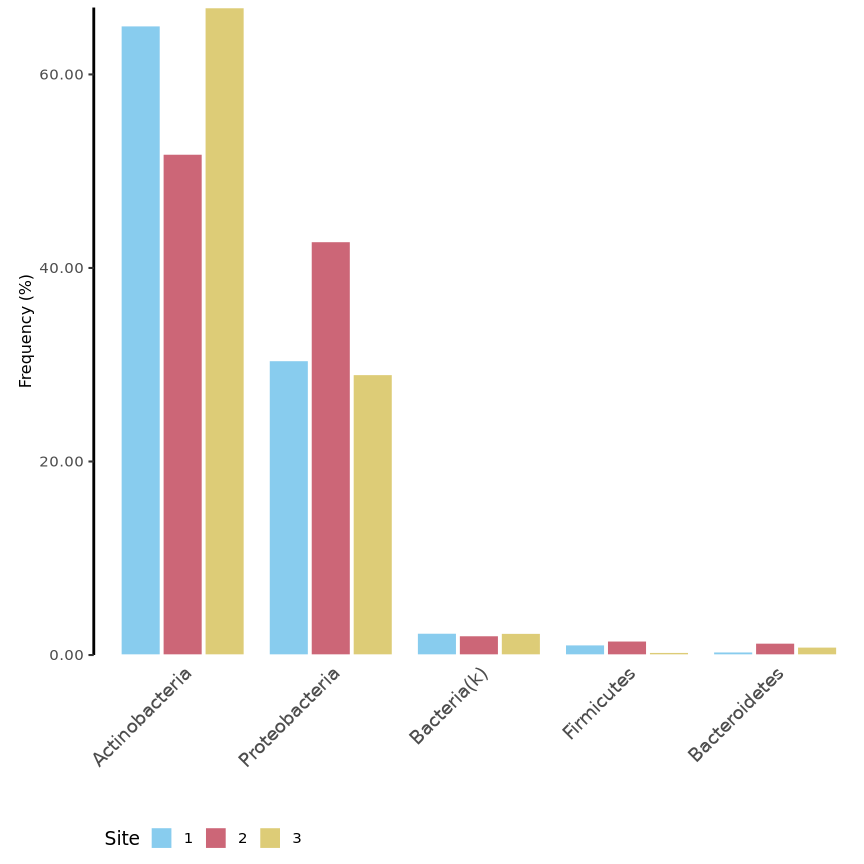

```r
# First just site
dat <- list(as.data.frame(counts(dds, normalize = T)), taxData, as.data.frame(colData(dds)))

design <- "Site"

md1 <- getSummedTaxa(dat, conf = TAXCONF, design = design, taxon = "phylum", cutoff = 0.1)

md1[, Site := factor(Site, levels = c(1, 2, 3))]
md1[, taxon := factor(taxon, levels = unique(taxon[order(value, decreasing = T)]))]

removals <- md1[, .(value = mean(value)), by = "taxon"][value < 0.5, taxon]
md1 <- md1[!taxon %in% removals, ]

bac_phylum_site_plot <- plotfun1(md1, x = "taxon", fill = "Site")

ggsave("figures/bac_phylum_site.png", bac_phylum_site_plot, width = 20, height = 15, units = "cm")

bac_phylum_site_plot
```

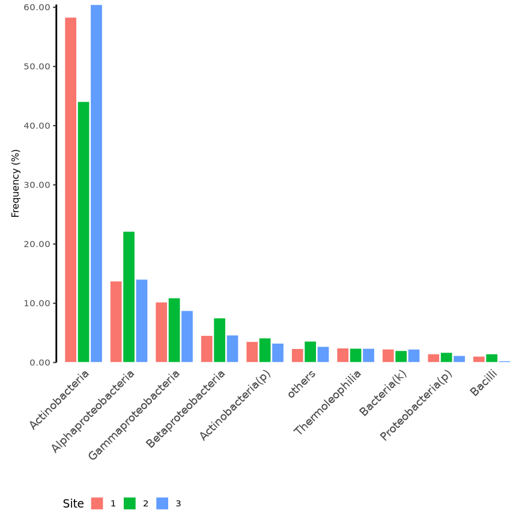

```r
md2 <- getSummedTaxa(dat, conf = TAXCONF, design = design, taxon = "class", cutoff = 0.1, topn = 9)

md2[, Site := factor(Site, levels = c(1, 2, 3))]
md2[, taxon := factor(taxon, levels = unique(taxon[order(value, decreasing = T)]))]

removals <- md2[, .(value = mean(value)), by = "taxon"][value < 0.5, taxon]
md2 <- md2[!taxon %in% removals, ]

bac_class_site_plot <- plotfun1(md2, x = "taxon", fill = "Site")

ggsave("figures/bac_class_site.png", bac_class_site_plot, width = 20, height = 15, units = "cm")

bac_class_site_plot
```

```r
# Next site and storage
design <- c("Site", "Storage")

md1 <- getSummedTaxa(dat, conf = TAXCONF, design = design, taxon = "phylum", cutoff = 0.1)

md1[, Site := factor(Site, levels = c(1, 2, 3))]
md1[, Storage := factor(Storage, levels = c("no", "yes"))]
md1[, taxon := factor(taxon, levels = unique(taxon[order(value, decreasing = T)]))]

removals <- md1[, .(value = mean(value)), by = "taxon"][value < 0.5, taxon]
md1 <- md1[!taxon %in% removals, ]

bac_phylum_plot <- plotfun1(md1, x = "taxon", fill = "Site") +
  facet_wrap(~ Storage)

ggsave("figures/bac_phylum.png", bac_phylum_plot, width = 25, height = 15, units = "cm")

md2 <- getSummedTaxa(dat, conf = TAXCONF, design = design, taxon = "class", cutoff = 0.1, topn = 9)

md2[, Site := factor(Site, levels = c(1, 2, 3))]
md2[, Storage := factor(Storage, levels = c("no", "yes"))]
md2[, taxon := factor(taxon, levels = unique(taxon[order(value, decreasing = T)]))]

removals <- md2[, .(value = mean(value)), by = "taxon"][value < 0.5, taxon]
md2 <- md2[!taxon %in% removals, ]

bac_class_plot <- plotfun1(md2, x = "taxon", fill = "Site") +
  facet_wrap(~ Storage)

ggsave("figures/bac_class.png", bac_class_plot, width = 25, height = 15, units = "cm")
```

## Community size

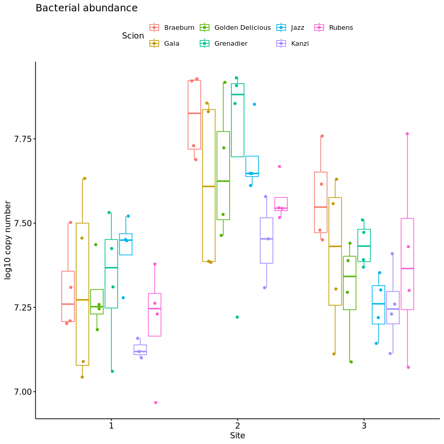

```r
abundance_plot <- ggplot(
  data = as.data.frame(colData(dds)),
  aes(x = Site, y = log_copy_number, colour = Scion, shape = Storage)
) + geom_jitter() +
  scale_colour_manual(values = cbPalette)

abundance_plot <- ggboxplot(
  data = as.data.frame(colData(dds)), x = "Site", y = "log_copy_number",
  color = "Scion", add = "jitter", legend = "top",
  title = "Bacterial abundance", xlab = "Site", ylab = "log10 copy number"
)

ggsave(
  filename = "bac_abundance.png", plot = abundance_plot, path = "figures/",
  height = 20, width = 20, units = "cm"
)

abundance_plot
```

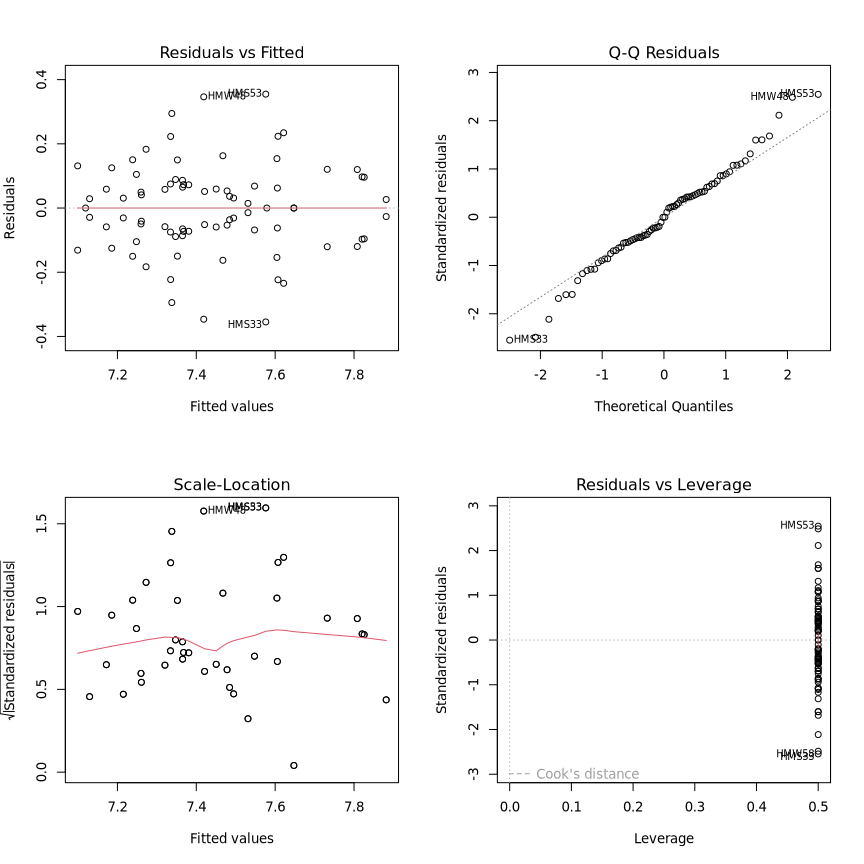

```r
# Formula for ANOVA
formula <- update(FULL_DESIGN, log_copy_number ~ .)

abundance_anova <- aov(formula, data = as.data.frame(colData(dds)))

# Normality check
par(mfrow = c(2, 2))
plot(abundance_anova)
```

```r
png("figures/bac_abundance_norm.png", width = 800, height = 600)
par(mfrow = c(2, 2))
plot(abundance_anova)
dev.off()
```

```
# png
#   2
```

```r
# Results
summary(abundance_anova)
```

```
#                    Df Sum Sq Mean Sq F value   Pr(>F)
# Site                2 1.9657  0.9828  25.302 7.91e-08 ***
# Storage             1 0.0798  0.0798   2.056   0.1594
# Scion               6 0.5131  0.0855   2.202   0.0628 .
# Site:Storage        2 0.0768  0.0384   0.989   0.3809
# Site:Scion         12 0.2677  0.0223   0.574   0.8494
# Storage:Scion       6 0.1640  0.0273   0.704   0.6484
# Site:Storage:Scion 12 0.1889  0.0157   0.405   0.9530
# Residuals          40 1.5538  0.0388
# ---
# Signif. codes:  0 '***' 0.001 '**' 0.01 '*' 0.05 '.' 0.1 ' ' 1
```

```r
abundance_results <- abundance_anova %>% summary() %>% unclass() %>% data.frame()
total_variance <- sum(abundance_results$Sum.Sq)
abundance_results$Perc.Var <- abundance_results$Sum.Sq / total_variance * 100

abundance_results %>%
  kbl() %>%
  kable_styling("striped", full_width = F)
```

|  | Df | Sum.Sq | Mean.Sq | F.value | Pr..F. | Perc.Var |
| --- | --- | --- | --- | --- | --- | --- |
| Site | 2 | 1.9656600 | 0.9828300 | 25.3015018 | 0.0000001 | 40.867065 |
| Storage | 1 | 0.0798455 | 0.0798455 | 2.0555037 | 0.1594283 | 1.660028 |
| Scion | 6 | 0.5131282 | 0.0855214 | 2.2016206 | 0.0628090 | 10.668194 |
| Site:Storage | 2 | 0.0768326 | 0.0384163 | 0.9889711 | 0.3808702 | 1.597389 |
| Site:Scion | 12 | 0.2677207 | 0.0223101 | 0.5743394 | 0.8494197 | 5.566049 |
| Storage:Scion | 6 | 0.1639852 | 0.0273309 | 0.7035927 | 0.6484006 | 3.409335 |
| Site:Storage:Scion | 12 | 0.1889265 | 0.0157439 | 0.4053027 | 0.9530223 | 3.927877 |
| Residuals | 40 | 1.5537892 | 0.0388447 | NA | NA | 32.304063 |

### Communtiy size with canker count

```r
cat("Model formula: ", deparse(update(design_with_canker, log_copy_number ~ .)), "\n")
```

```
# Model formula:  log_copy_number ~ Site + Storage + Scion + Cankers + Site:Storage +      Site:Scion + Storage:Scion + Site:Cankers + Storage:Cankers +      Scion:Cankers
```

```r
abundance_canker_anova <- aov(update(design_with_canker, log_copy_number ~ .), data = as.data.frame(colData(dds)))
summary(abundance_canker_anova)
```

```
#                 Df Sum Sq Mean Sq F value   Pr(>F)
# Site             2 1.8693  0.9347  26.061 5.67e-08 ***
# Storage          1 0.0599  0.0599   1.670   0.2037
# Scion            6 0.5203  0.0867   2.418   0.0435 *
# Cankers          1 0.0006  0.0006   0.016   0.8985
# Site:Storage     2 0.0832  0.0416   1.160   0.3237
# Site:Scion      12 0.2195  0.0183   0.510   0.8957
# Storage:Scion    6 0.1795  0.0299   0.834   0.5507
# Site:Cankers     2 0.0576  0.0288   0.803   0.4551
# Storage:Cankers  1 0.0468  0.0468   1.304   0.2602
# Scion:Cankers    6 0.1694  0.0282   0.787   0.5850
# Residuals       40 1.4346  0.0359
# ---
# Signif. codes:  0 '***' 0.001 '**' 0.01 '*' 0.05 '.' 0.1 ' ' 1
# 2 observations deleted due to missingness
```

```r
abundance_canker_results <- abundance_canker_anova %>% summary() %>% unclass() %>% data.frame()
total_variance <- sum(abundance_canker_results$Sum.Sq)
abundance_canker_results$Perc.Var <- abundance_canker_results$Sum.Sq / total_variance * 100
abundance_canker_results %>%
  kbl() %>%
  kable_styling("striped", full_width = F)
```

|  | Df | Sum.Sq | Mean.Sq | F.value | Pr..F. | Perc.Var |
| --- | --- | --- | --- | --- | --- | --- |
| Site | 2 | 1.8693344 | 0.9346672 | 26.0614432 | 0.0000001 | 40.2808617 |
| Storage | 1 | 0.0598882 | 0.0598882 | 1.6698702 | 0.2036918 | 1.2904851 |
| Scion | 6 | 0.5202960 | 0.0867160 | 2.4179132 | 0.0434910 | 11.2114621 |
| Cankers | 1 | 0.0005911 | 0.0005911 | 0.0164808 | 0.8984936 | 0.0127364 |
| Site:Storage | 2 | 0.0832292 | 0.0416146 | 1.1603449 | 0.3237018 | 1.7934422 |
| Site:Scion | 12 | 0.2194944 | 0.0182912 | 0.5100159 | 0.8957429 | 4.7297183 |
| Storage:Scion | 6 | 0.1795479 | 0.0299246 | 0.8343927 | 0.5506600 | 3.8689403 |
| Site:Cankers | 2 | 0.0575936 | 0.0287968 | 0.8029453 | 0.4550964 | 1.2410414 |
| Storage:Cankers | 1 | 0.0467824 | 0.0467824 | 1.3044400 | 0.2601947 | 1.0080786 |
| Scion:Cankers | 6 | 0.1694341 | 0.0282390 | 0.7873923 | 0.5850378 | 3.6510073 |
| Residuals | 40 | 1.4345594 | 0.0358640 | NA | NA | 30.9122265 |

## Alpha diversity analysis

### Alpha diversity plot

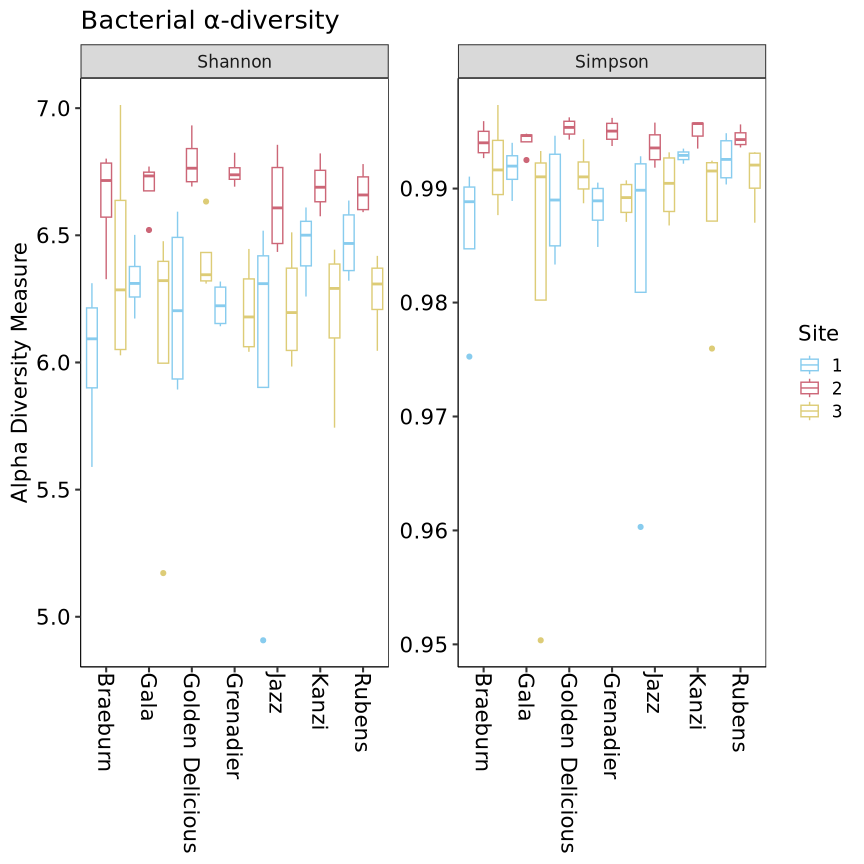

```r
# plot alpha diversity - plot_alpha will convert normalised abundances to integer values

bac_alpha_plot <- plot_alpha(
  counts(dds,normalize = F), colData(dds),
  design = "Scion", colour = "Site",
  measures = c("Shannon", "Simpson"),
  type="box"
) +
  scale_colour_manual(values = cbPalette) +
  theme(axis.title.x =  element_blank()) +
  ggtitle("Bacterial α-diversity")

abundance_plot <- ggboxplot(
  data = as.data.frame(colData(dds)), x = "Site", y = "log_copy_number",
  color = "Scion", add = "jitter", legend = "top",
  title = "Bacterial abundance", xlab = "Site", ylab = "log10 copy number"
)

ggsave(
  filename = "bac_alpha.png", plot = bac_alpha_plot, path = "figures/",
  height = 20, width = 40, units = "cm"
)

bac_alpha_plot
```

### Permutation based anova on α-diversity index ranks

```r
# get the diversity index data
all_alpha_ord <- plot_alpha(
  counts(dds, normalize = F), colData(dds), design = "Site", returnData = T
)

# join diversity indices and metadata
all_alpha_ord <- all_alpha_ord[
  as.data.table(colData(dds), keep.rownames = "Samples"), on = "Samples"
]

bac_alpha <- all_alpha_ord

formula <- FULL_DESIGN

# Chao1

setkey(all_alpha_ord, S.chao1)
all_alpha_ord[, measure := as.numeric(as.factor(S.chao1))]
result <- aovp(update(formula, measure ~ .), all_alpha_ord, seqs = T)
```

```
# [1] "Settings:  sequential SS "
```

```r
summary(result)
```

```
# Component 1 :
#                    Df R Sum Sq R Mean Sq Iter Pr(Prob)
# Site                2  20914.4   10457.2 5000   <2e-16 ***
# Storage             1    113.5     113.5  110   0.4818
# Site:Storage        2   3319.8    1659.9 5000   0.0094 **
# Scion               6   1291.7     215.3  407   0.5037
# Site:Scion         12   5425.8     452.1 2201   0.1577
# Storage:Scion       6    867.4     144.6  699   0.8054
# Site:Storage:Scion 12   1912.4     159.4  551   0.9456
# Residuals          40  12095.5     302.4
# ---
# Signif. codes:  0 '***' 0.001 '**' 0.01 '*' 0.05 '.' 0.1 ' ' 1
```

```r
df <- result %>% summary() %>% unclass() %>% data.frame()
total_variance <- sum(df$R.Sum.Sq)
df$Perc.Var <- df$R.Sum.Sq / total_variance * 100
df %>%
  kbl() %>%
  kable_styling("striped", full_width = F)
```

|  | Df | R.Sum.Sq | R.Mean.Sq | Iter | Pr.Prob. | Perc.Var |
| --- | --- | --- | --- | --- | --- | --- |
| Site | 2 | 20914.3677 | 10457.1839 | 5000 | 0.0000000 | 45.5249023 |
| Storage | 1 | 113.5359 | 113.5359 | 110 | 0.4818182 | 0.2471368 |
| Site:Storage | 2 | 3319.8162 | 1659.9081 | 5000 | 0.0094000 | 7.2263388 |
| Scion | 6 | 1291.7022 | 215.2837 | 407 | 0.5036855 | 2.8116852 |
| Site:Scion | 12 | 5425.7655 | 452.1471 | 2201 | 0.1576556 | 11.8104189 |
| Storage:Scion | 6 | 867.3693 | 144.5615 | 699 | 0.8054363 | 1.8880275 |
| Site:Storage:Scion | 12 | 1912.4432 | 159.3703 | 551 | 0.9455535 | 4.1628699 |
| Residuals | 40 | 12095.5000 | 302.3875 | NA | NA | 26.3286207 |

```r
# Shannon

setkey(all_alpha_ord, shannon)
all_alpha_ord[, measure := as.numeric(as.factor(shannon))]
result <- aovp(update(formula, measure ~ .), all_alpha_ord, seqs = T)
```

```
# [1] "Settings:  sequential SS "
```

```r
summary(result)
```

```
# Component 1 :
#                    Df R Sum Sq R Mean Sq Iter Pr(Prob)
# Site                2  23583.2   11791.6 5000   <2e-16 ***
# Storage             1     89.3      89.3  120   0.4583
# Site:Storage        2    898.4     449.2  714   0.2983
# Scion               6    994.0     165.7  165   0.7939
# Site:Scion         12   3435.7     286.3 5000   0.7100
# Storage:Scion       6    481.5      80.3   84   1.0000
# Site:Storage:Scion 12   2143.3     178.6 2635   0.9450
# Residuals          40  14315.0     357.9
# ---
# Signif. codes:  0 '***' 0.001 '**' 0.01 '*' 0.05 '.' 0.1 ' ' 1
```

```r
df <- result %>% summary() %>% unclass() %>% data.frame()
total_variance <- sum(df$R.Sum.Sq)
df$Perc.Var <- df$R.Sum.Sq / total_variance * 100
df %>%
  kbl() %>%
  kable_styling("striped", full_width = F)
```

|  | Df | R.Sum.Sq | R.Mean.Sq | Iter | Pr.Prob. | Perc.Var |
| --- | --- | --- | --- | --- | --- | --- |
| Site | 2 | 23583.23942 | 11791.61971 | 5000 | 0.0000000 | 51.3343116 |
| Storage | 1 | 89.26865 | 89.26865 | 120 | 0.4583333 | 0.1943136 |
| Site:Storage | 2 | 898.39852 | 449.19926 | 714 | 0.2983193 | 1.9555698 |
| Scion | 6 | 994.03480 | 165.67247 | 165 | 0.7939394 | 2.1637440 |
| Site:Scion | 12 | 3435.70147 | 286.30846 | 5000 | 0.7100000 | 7.4785896 |
| Storage:Scion | 6 | 481.54603 | 80.25767 | 84 | 1.0000000 | 1.0481950 |
| Site:Storage:Scion | 12 | 2143.31111 | 178.60926 | 2635 | 0.9449715 | 4.6654066 |
| Residuals | 40 | 14315.00000 | 357.87500 | NA | NA | 31.1598698 |

```r
# Simpson

setkey(all_alpha_ord, simpson)
all_alpha_ord[, measure := as.numeric(as.factor(simpson))]
result <- aovp(update(formula, measure ~ .), all_alpha_ord, seqs = T)
```

```
# [1] "Settings:  sequential SS "
```

```r
summary(result)
```

```
# Component 1 :
#                    Df R Sum Sq R Mean Sq Iter Pr(Prob)
# Site                2  20851.3   10425.7 5000   <2e-16 ***
# Storage             1     31.0      31.0  163   0.3804
# Site:Storage        2   1422.3     711.2 1690   0.1118
# Scion               6   1995.8     332.6  609   0.3924
# Site:Scion         12   3933.8     327.8 1536   0.4915
# Storage:Scion       6   1003.5     167.3  677   0.5968
# Site:Storage:Scion 12   3012.3     251.0 3909   0.7135
# Residuals          40  13690.5     342.3
# ---
# Signif. codes:  0 '***' 0.001 '**' 0.01 '*' 0.05 '.' 0.1 ' ' 1
```

```r
df <- result %>% summary() %>% unclass() %>% data.frame()
total_variance <- sum(df$R.Sum.Sq)
df$Perc.Var <- df$R.Sum.Sq / total_variance * 100
df %>%
  kbl() %>%
  kable_styling("striped", full_width = F)
```

|  | Df | R.Sum.Sq | R.Mean.Sq | Iter | Pr.Prob. | Perc.Var |
| --- | --- | --- | --- | --- | --- | --- |
| Site | 2 | 20851.30423 | 10425.65212 | 5000 | 0.0000000 | 45.3876302 |
| Storage | 1 | 30.96912 | 30.96912 | 163 | 0.3803681 | 0.0674114 |
| Site:Storage | 2 | 1422.32005 | 711.16002 | 1690 | 0.1118343 | 3.0960047 |
| Scion | 6 | 1995.82345 | 332.63724 | 609 | 0.3924466 | 4.3443660 |
| Site:Scion | 12 | 3933.80635 | 327.81720 | 1536 | 0.4915365 | 8.5628288 |
| Storage:Scion | 6 | 1003.51689 | 167.25281 | 677 | 0.5967504 | 2.1843839 |
| Site:Storage:Scion | 12 | 3012.25990 | 251.02166 | 3909 | 0.7134817 | 6.5568722 |
| Residuals | 40 | 13690.50000 | 342.26250 | NA | NA | 29.8005028 |

#### Permutation based anova on α-diversity index ranks with canker lesion counts

```r
cat("Model formula: ", deparse(design_with_canker), "\n")
```

```
# Model formula:  y ~ Site + Storage + Scion + Cankers + Site:Storage + Site:Scion +      Storage:Scion + Cankers:Site + Cankers:Storage + Cankers:Scion
```

```r
# Chao1

setkey(all_alpha_ord, S.chao1)
all_alpha_ord[, measure := as.numeric(as.factor(S.chao1))]
result <- aovp(update(design_with_canker, measure ~ .), all_alpha_ord, seqs = T)
```

```
# [1] "Settings:  sequential SS : numeric variables centered"
```

```r
summary(result)
```

```
# Component 1 :
#                 Df R Sum Sq R Mean Sq Iter Pr(Prob)
# Site             2  19947.7    9973.9 5000  < 2e-16 ***
# Storage          1     58.2      58.2   51  0.86275
# Site:Storage     2   3190.2    1595.1 5000  0.00240 **
# Scion            6   1339.7     223.3  691  0.51809
# Site:Scion      12   5577.6     464.8 4492  0.04052 *
# Storage:Scion    6    912.5     152.1  254  0.75197
# Cankers          1      7.9       7.9   51  0.86275
# Site:Cankers     2   1180.5     590.3 2132  0.07270 .
# Storage:Cankers  1    595.0     595.0 1442  0.06519 .
# Scion:Cankers    6   2762.1     460.4 5000  0.10600
# Residuals       40   8976.5     224.4
# ---
# Signif. codes:  0 '***' 0.001 '**' 0.01 '*' 0.05 '.' 0.1 ' ' 1
```

```r
df <- result %>% summary() %>% unclass() %>% data.frame()
total_variance <- sum(df$R.Sum.Sq)
df$Perc.Var <- df$R.Sum.Sq / total_variance * 100
df %>%
  kbl() %>%
  kable_styling("striped", full_width = F)
```

|  | Df | R.Sum.Sq | R.Mean.Sq | Iter | Pr.Prob. | Perc.Var |
| --- | --- | --- | --- | --- | --- | --- |
| Site | 2 | 19947.732514 | 9973.866257 | 5000 | 0.0000000 | 44.7780778 |
| Storage | 1 | 58.169104 | 58.169104 | 51 | 0.8627451 | 0.1305763 |
| Site:Storage | 2 | 3190.234234 | 1595.117117 | 5000 | 0.0024000 | 7.1613431 |
| Scion | 6 | 1339.733199 | 223.288867 | 691 | 0.5180897 | 3.0073933 |
| Site:Scion | 12 | 5577.605949 | 464.800496 | 4492 | 0.0405165 | 12.5204443 |
| Storage:Scion | 6 | 912.459044 | 152.076507 | 254 | 0.7519685 | 2.0482610 |
| Cankers | 1 | 7.943258 | 7.943258 | 51 | 0.8627451 | 0.0178308 |
| Site:Cankers | 2 | 1180.530290 | 590.265145 | 2132 | 0.0727017 | 2.6500194 |
| Storage:Cankers | 1 | 594.966068 | 594.966068 | 1442 | 0.0651872 | 1.3355622 |
| Scion:Cankers | 6 | 2762.126818 | 460.354470 | 5000 | 0.1060000 | 6.2003403 |
| Residuals | 40 | 8976.487022 | 224.412175 | NA | NA | 20.1501516 |

```r
# Shannon

setkey(all_alpha_ord, shannon)
all_alpha_ord[, measure := as.numeric(as.factor(shannon))]
result <- aovp(update(design_with_canker, measure ~ .), all_alpha_ord, seqs = T)
```

```
# [1] "Settings:  sequential SS : numeric variables centered"
```

```r
summary(result)
```

```
# Component 1 :
#                 Df R Sum Sq R Mean Sq Iter Pr(Prob)
# Site             2  23123.2   11561.6 5000   <2e-16 ***
# Storage          1    107.5     107.5  130   0.4385
# Site:Storage     2    850.7     425.4 1173   0.1373
# Scion            6   1025.4     170.9  382   0.6492
# Site:Scion      12   3930.7     327.6 5000   0.2170
# Storage:Scion    6    725.7     120.9  244   0.7090
# Cankers          1    182.5     182.5  283   0.2615
# Site:Cankers     2   2709.7    1354.9 5000   0.0110 *
# Storage:Cankers  1    375.0     375.0  397   0.2015
# Scion:Cankers    6   2393.0     398.8 5000   0.1888
# Residuals       40   9974.5     249.4
# ---
# Signif. codes:  0 '***' 0.001 '**' 0.01 '*' 0.05 '.' 0.1 ' ' 1
```

```r
df <- result %>% summary() %>% unclass() %>% data.frame()
total_variance <- sum(df$R.Sum.Sq)
df$Perc.Var <- df$R.Sum.Sq / total_variance * 100
df %>%
  kbl() %>%
  kable_styling("striped", full_width = F)
```

|  | Df | R.Sum.Sq | R.Mean.Sq | Iter | Pr.Prob. | Perc.Var |
| --- | --- | --- | --- | --- | --- | --- |
| Site | 2 | 23123.1855 | 11561.5928 | 5000 | 0.0000000 | 50.9343845 |
| Storage | 1 | 107.5243 | 107.5243 | 130 | 0.4384615 | 0.2368481 |
| Site:Storage | 2 | 850.7448 | 425.3724 | 1173 | 0.1372549 | 1.8739702 |
| Scion | 6 | 1025.4058 | 170.9010 | 382 | 0.6492147 | 2.2587033 |
| Site:Scion | 12 | 3930.7425 | 327.5619 | 5000 | 0.2170000 | 8.6584070 |
| Storage:Scion | 6 | 725.6609 | 120.9435 | 244 | 0.7090164 | 1.5984428 |
| Cankers | 1 | 182.4523 | 182.4523 | 283 | 0.2614841 | 0.4018952 |
| Site:Cankers | 2 | 2709.7440 | 1354.8720 | 5000 | 0.0110000 | 5.9688637 |
| Storage:Cankers | 1 | 375.0416 | 375.0416 | 397 | 0.2015113 | 0.8261195 |
| Scion:Cankers | 6 | 2393.0267 | 398.8378 | 5000 | 0.1888000 | 5.2712177 |
| Residuals | 40 | 9974.4591 | 249.3615 | NA | NA | 21.9711481 |

```r
# Simpson

setkey(all_alpha_ord, simpson)
all_alpha_ord[, measure := as.numeric(as.factor(simpson))]
result <- aovp(update(design_with_canker, measure ~ .), all_alpha_ord, seqs = T)
```

```
# [1] "Settings:  sequential SS : numeric variables centered"
```

```r
summary(result)
```

```
# Component 1 :
#                 Df R Sum Sq R Mean Sq Iter Pr(Prob)
# Site             2  21042.0   10521.0 5000  < 2e-16 ***
# Storage          1     11.7      11.7   51  0.84314
# Site:Storage     2   1383.1     691.5 4307  0.05619 .
# Scion            6   2047.5     341.2 1109  0.37962
# Site:Scion      12   3877.8     323.1 3435  0.39214
# Storage:Scion    6   1014.4     169.1  790  0.75570
# Cankers          1    118.5     118.5   51  0.94118
# Site:Cankers     2   3017.2    1508.6 5000  0.00480 **
# Storage:Cankers  1    165.5     165.5  104  0.49038
# Scion:Cankers    6   2877.6     479.6 5000  0.12040
# Residuals       40  10362.8     259.1
# ---
# Signif. codes:  0 '***' 0.001 '**' 0.01 '*' 0.05 '.' 0.1 ' ' 1
```

```r
df <- result %>% summary() %>% unclass() %>% data.frame()
total_variance <- sum(df$R.Sum.Sq)
df$Perc.Var <- df$R.Sum.Sq / total_variance * 100
df %>%
  kbl() %>%
  kable_styling("striped", full_width = F)
```

|  | Df | R.Sum.Sq | R.Mean.Sq | Iter | Pr.Prob. | Perc.Var |
| --- | --- | --- | --- | --- | --- | --- |
| Site | 2 | 21041.97439 | 10520.98720 | 5000 | 0.0000000 | 45.8252231 |
| Storage | 1 | 11.68134 | 11.68134 | 51 | 0.8431373 | 0.0254396 |
| Site:Storage | 2 | 1383.06144 | 691.53072 | 4307 | 0.0561876 | 3.0120319 |
| Scion | 6 | 2047.47993 | 341.24666 | 1109 | 0.3796213 | 4.4590029 |
| Site:Scion | 12 | 3877.77886 | 323.14824 | 3435 | 0.3921397 | 8.4450289 |
| Storage:Scion | 6 | 1014.35808 | 169.05968 | 790 | 0.7556962 | 2.2090696 |
| Cankers | 1 | 118.53077 | 118.53077 | 51 | 0.9411765 | 0.2581364 |
| Site:Cankers | 2 | 3017.15968 | 1508.57984 | 5000 | 0.0048000 | 6.5707720 |
| Storage:Cankers | 1 | 165.47167 | 165.47167 | 104 | 0.4903846 | 0.3603643 |
| Scion:Cankers | 6 | 2877.60198 | 479.60033 | 5000 | 0.1204000 | 6.2668431 |
| Residuals | 40 | 10362.78936 | 259.06973 | NA | NA | 22.5680882 |

## Beta diversity PCA/NMDS

### PCA

```r
# Number of PCs to include
n_pcs <- 10

# perform PC decomposition of DES object
mypca <- des_to_pca(dds)

# to get pca plot axis into the same scale create a dataframe of PC scores multiplied by their variance
bac_pca <- t(data.frame(t(mypca$x) * mypca$percentVar))

formula = FULL_DESIGN
```

#### Percent variation in first 10 PCs

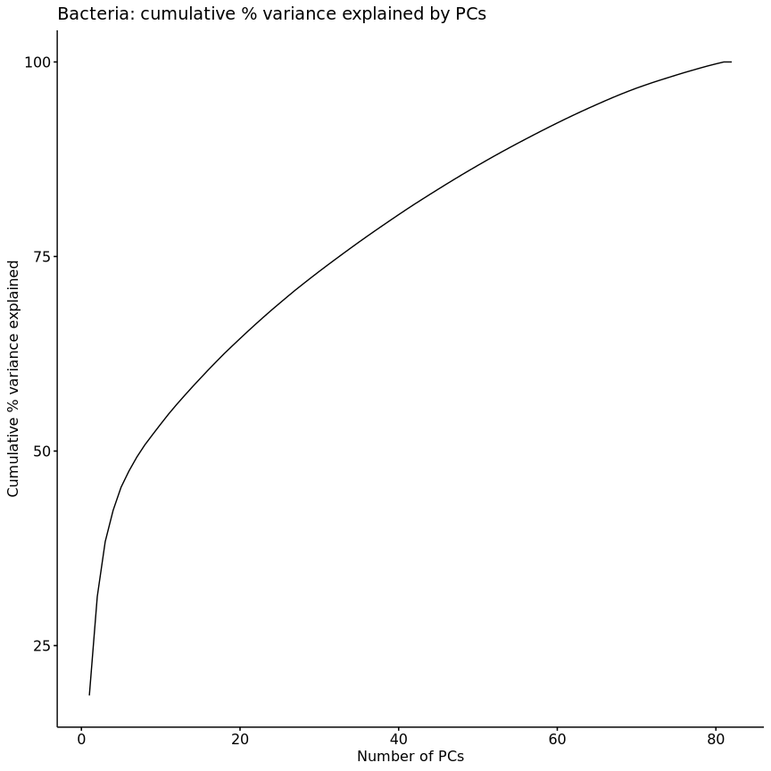

```r
# Cumulative percentage of variance explained
pca_cum_var <- data.frame(
  cumulative = cumsum(mypca$percentVar * 100),
  no = 1:length(mypca$percentVar)
)

# Plot cumulative percentage of variance explained
bac_cum_pca <- ggline(
  pca_cum_var, x = "no", y = "cumulative", plot_type = "l",
  xlab = "Number of PCs", ylab = "Cumulative % variance explained",
  title = "Bacteria: cumulative % variance explained by PCs"
)
ggsave(filename = "bac_cum_pca.png", plot = bac_cum_pca, path = "figures/",)
bac_cum_pca
```

```r
pca_var <- data.frame(
  PC = paste0("PC", 1:n_pcs),
  perc_var = round(mypca$percentVar[1:n_pcs] * 100, 1)
)

pca_var %>%
  kbl() %>%
  kable_styling("striped", full_width = F)
```

| PC | perc_var |
| --- | --- |
| PC1 | 18.6 |
| PC2 | 12.7 |
| PC3 | 7.1 |
| PC4 | 4.0 |
| PC5 | 3.0 |
| PC6 | 2.1 |
| PC7 | 1.8 |
| PC8 | 1.6 |
| PC9 | 1.3 |
| PC10 | 1.3 |

#### ANOVA of first 10 PCs

```r
pca_summary <- apply(
  mypca$x[, 1:n_pcs], 2,
  function(x){
    summary(aov(update(formula, x ~ .), data = as.data.frame(cbind(x, colData(dds)))))
  }
)

pca_summary
```

```
# $PC1
#                    Df Sum Sq Mean Sq F value Pr(>F)
# Site                2 190646   95323 224.072 <2e-16 ***
# Storage             1     25      25   0.058 0.8106
# Scion               6   4227     704   1.656 0.1572
# Site:Storage        2   2566    1283   3.015 0.0603 .
# Site:Scion         12   8401     700   1.646 0.1176
# Storage:Scion       6   1527     255   0.598 0.7298
# Site:Storage:Scion 12   5124     427   1.004 0.4634
# Residuals          40  17016     425
# ---
# Signif. codes:  0 '***' 0.001 '**' 0.01 '*' 0.05 '.' 0.1 ' ' 1
#
# $PC2
#                    Df Sum Sq Mean Sq F value Pr(>F)
# Site                2 137668   68834 276.644 <2e-16 ***
# Storage             1    142     142   0.572  0.454
# Scion               6   1474     246   0.987  0.447
# Site:Storage        2    604     302   1.213  0.308
# Site:Scion         12   4425     369   1.482  0.172
# Storage:Scion       6    711     119   0.476  0.822
# Site:Storage:Scion 12   2035     170   0.681  0.759
# Residuals          40   9953     249
# ---
# Signif. codes:  0 '***' 0.001 '**' 0.01 '*' 0.05 '.' 0.1 ' ' 1
#
# $PC3
#                    Df Sum Sq Mean Sq F value   Pr(>F)
# Site                2   2673    1337   1.562 0.222149
# Storage             1     30      30   0.035 0.851920
# Scion               6  13665    2278   2.663 0.028714 *
# Site:Storage        2  14748    7374   8.621 0.000771 ***
# Site:Scion         12  10740     895   1.046 0.428331
# Storage:Scion       6   8140    1357   1.586 0.176467
# Site:Storage:Scion 12   2870     239   0.280 0.989466
# Residuals          40  34217     855
# ---
# Signif. codes:  0 '***' 0.001 '**' 0.01 '*' 0.05 '.' 0.1 ' ' 1
#
# $PC4
```

[output cut: 72 more lines]

```
# ---
# Signif. codes:  0 '***' 0.001 '**' 0.01 '*' 0.05 '.' 0.1 ' ' 1
#
# $PC10
#                    Df Sum Sq Mean Sq F value  Pr(>F)
# Site                2    131    65.4   0.396 0.67572
# Storage             1    365   365.5   2.213 0.14466
# Scion               6   1060   176.7   1.070 0.39635
# Site:Storage        2   2202  1100.8   6.666 0.00317 **
# Site:Scion         12   2043   170.2   1.031 0.44086
# Storage:Scion       6   1947   324.4   1.965 0.09381 .
# Site:Storage:Scion 12   1980   165.0   0.999 0.46711
# Residuals          40   6605   165.1
# ---
# Signif. codes:  0 '***' 0.001 '**' 0.01 '*' 0.05 '.' 0.1 ' ' 1
```

#### Percent variation in first 10 PCs for each factor

```r
# Extract PC scores as a list of dataframes
pcas <- lapply(pca_summary, function(i) data.frame(unclass(i)))

# Merge into single dataframe
pcs_factors_tidy <- lapply(
  names(pcas),
  function(name) {
    pcas[[name]] %>%
    mutate(
      PC = name, #substring(name, 3),
      Factor = gsub(" ", "", rownames(pcas[[name]])),
      var = Sum.Sq / sum(pcas[[name]]$Sum.Sq) * 100,
      pc_var = subset(pca_var, PC == name)$"perc_var",
      total_var = var * pc_var / 100,
      sig = case_when(
        is.na(Pr..F.) ~ "",
        Pr..F. < 0.001 ~ "***",
        Pr..F. < 0.01 ~ "**",
        Pr..F. < 0.05 ~ "*",
        TRUE ~ ""
      ),
      variance = ifelse(
        total_var < 0.01, paste0("<0.01", sig),
        paste0(round(total_var, 2), sig)
      )
    )
  }
) %>% bind_rows() %>% data.table()

# Order PCs and factors
pcs_factors_tidy$PC <- factor(pcs_factors_tidy$PC, levels = paste0("PC", 1:n_pcs))
pcs_factors_tidy$Factor <- factor(pcs_factors_tidy$Factor, levels = unique(pcs_factors_tidy$Factor))

# Significant factors
pcs_factors_tidy[
  Pr..F. < 0.05,
  c("PC", "Factor", "Df", "F.value", "Pr..F.", "var", "pc_var", "total_var")
] %>%
  kbl() %>%
  kable_styling("striped", full_width = F)
```

| PC | Factor | Df | F.value | Pr..F. | var | pc_var | total_var |
| --- | --- | --- | --- | --- | --- | --- | --- |
| PC1 | Site | 2 | 224.072105 | 0.0000000 | 83.058689 | 18.6 | 15.4489162 |
| PC2 | Site | 2 | 276.643717 | 0.0000000 | 87.680340 | 12.7 | 11.1354032 |
| PC3 | Scion | 6 | 2.662540 | 0.0287140 | 15.692236 | 7.1 | 1.1141487 |
| PC3 | Site:Storage | 2 | 8.620505 | 0.0007710 | 16.935585 | 7.1 | 1.2024266 |
| PC4 | Site | 2 | 5.833732 | 0.0059821 | 10.610344 | 4.0 | 0.4244137 |
| PC4 | Site:Scion | 12 | 2.521003 | 0.0141754 | 27.511079 | 4.0 | 1.1004432 |
| PC5 | Storage | 1 | 9.432657 | 0.0038232 | 11.015538 | 3.0 | 0.3304662 |
| PC5 | Site:Storage | 2 | 6.978586 | 0.0025131 | 16.299308 | 3.0 | 0.4889792 |
| PC6 | Storage | 1 | 5.069838 | 0.0299066 | 5.795920 | 2.1 | 0.1217143 |
| PC6 | Scion | 6 | 2.681842 | 0.0277905 | 18.395545 | 2.1 | 0.3863064 |
| PC7 | Site:Storage | 2 | 3.670184 | 0.0344007 | 8.991247 | 1.8 | 0.1618424 |
| PC9 | Site:Storage | 2 | 7.452304 | 0.0017743 | 20.856556 | 1.3 | 0.2711352 |
| PC10 | Site:Storage | 2 | 6.666103 | 0.0031726 | 13.479337 | 1.3 | 0.1752314 |

```r
# Table with factors as columns and PCs as rows
# pcs_factors <- dcast(pcs_factors_tidy, PC ~ Factor, value.var = "variance")
pcs_factors <- pcs_factors_tidy %>%
  select(PC, pc_var, Factor, variance) %>%
  spread(key = Factor, value = variance)

pcs_factors %>%
  kbl() %>%
  kable_styling("striped", full_width = F)
```

| PC | pc_var | Site | Storage | Scion | Site:Storage | Site:Scion | Storage:Scion | Site:Storage:Scion | Residuals |
| --- | --- | --- | --- | --- | --- | --- | --- | --- | --- |
| PC1 | 18.6 | 15.45*** | <0.01 | 0.34 | 0.21 | 0.68 | 0.12 | 0.42 | 1.38 |
| PC2 | 12.7 | 11.14*** | 0.01 | 0.12 | 0.05 | 0.36 | 0.06 | 0.16 | 0.81 |
| PC3 | 7.1 | 0.22 | <0.01 | 1.11* | 1.2*** | 0.88 | 0.66 | 0.23 | 2.79 |
| PC4 | 4.0 | 0.42** | 0.05 | 0.25 | 0.05 | 1.1* | 0.15 | 0.52 | 1.46 |
| PC5 | 3.0 | <0.01 | 0.33** | 0.12 | 0.49** | 0.21 | 0.16 | 0.29 | 1.4 |
| PC6 | 2.1 | <0.01 | 0.12* | 0.39* | 0.07 | 0.17 | 0.14 | 0.26 | 0.96 |
| PC7 | 1.8 | <0.01 | 0.04 | 0.18 | 0.16* | 0.2 | 0.08 | 0.25 | 0.88 |
| PC8 | 1.6 | <0.01 | 0.05 | 0.06 | 0.03 | 0.1 | 0.16 | 0.27 | 0.93 |
| PC9 | 1.3 | 0.02 | <0.01 | 0.05 | 0.27** | 0.09 | 0.05 | 0.08 | 0.73 |
| PC10 | 1.3 | 0.01 | 0.03 | 0.08 | 0.18** | 0.16 | 0.15 | 0.16 | 0.53 |

#### PCA plot

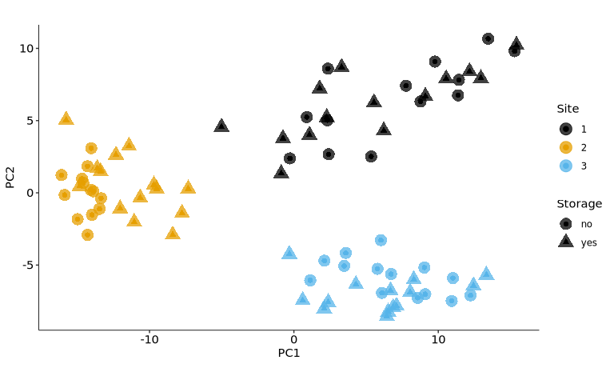

```r
bac_pca_plot <- plotOrd(
  bac_pca,
  colData(dds),
  design = "Site",
  shape = "Storage",
  axes = c(1, 2),
  # facet = "Storage",
  cbPalette = T,
  alpha = 0.75,
) #+ facet_wrap(~facet)

ggsave(filename = "bac_pca_plot.png", plot = bac_pca_plot, path = "figures/")

bac_pca_plot
```

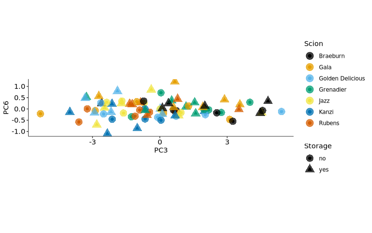

```r
bac_pca_3_6_plot <- plotOrd(
  bac_pca,
  colData(dds),
  design = "Scion",
  shape = "Storage",
  axes = c(3, 6),
  cbPalette = T,
  alpha = 0.75,
)

ggsave(filename = "bac_pca_3_6_plot.png", plot = bac_pca_3_6_plot, path = "figures/")

bac_pca_3_6_plot
```

#### PCA sum of squares (% var)

```r
sum_squares <- apply(mypca$x, 2 ,function(x)
  summary(aov(update(formula, x ~ .), data = cbind(x, colData(dds))))[[1]][2]
)
sum_squares <- do.call(cbind, sum_squares)
x <- t(apply(sum_squares, 2, prop.table))
perVar <- x * mypca$percentVar
#colSums(perVar)
round(colSums(perVar) / sum(colSums(perVar)) * 100, 3)
```

```
# Site               Storage            Scion              Site:Storage
#             27.377              1.163              6.201              3.608
# Site:Scion         Storage:Scion      Site:Storage:Scion Residuals
#             11.077              5.262              9.804             35.509
```

### PCA with canker lesion counts

```r
pca_summary <- apply(
  mypca$x[, 1:n_pcs], 2,
  function(x){
    summary(aov(update(design_with_canker, x ~ .), data = as.data.frame(cbind(x, colData(dds)))))
  }
)

pca_summary
```

```
# $PC1
#                 Df Sum Sq Mean Sq F value Pr(>F)
# Site             2 186046   93023 202.510 <2e-16 ***
# Storage          1      2       2   0.003 0.9542
# Scion            6   3688     615   1.338 0.2632
# Cankers          1     74      74   0.160 0.6912
# Site:Storage     2   3018    1509   3.285 0.0478 *
# Site:Scion      12   8019     668   1.455 0.1825
# Storage:Scion    6   1599     267   0.580 0.7437
# Site:Cankers     2    591     295   0.643 0.5310
# Storage:Cankers  1    177     177   0.385 0.5386
# Scion:Cankers    6   2237     373   0.811 0.5673
# Residuals       40  18374     459
# ---
# Signif. codes:  0 '***' 0.001 '**' 0.01 '*' 0.05 '.' 0.1 ' ' 1
# 2 observations deleted due to missingness
#
# $PC2
#                 Df Sum Sq Mean Sq F value Pr(>F)
# Site             2 130756   65378 277.199 <2e-16 ***
# Storage          1    184     184   0.779  0.383
# Scion            6   1286     214   0.909  0.498
# Cankers          1     28      28   0.118  0.733
# Site:Storage     2    620     310   1.314  0.280
# Site:Scion      12   4421     368   1.562  0.143
# Storage:Scion    6    799     133   0.565  0.756
# Site:Cankers     2    417     209   0.884  0.421
# Storage:Cankers  1      1       1   0.002  0.961
# Scion:Cankers    6   1869     311   1.321  0.271
# Residuals       40   9434     236
# ---
# Signif. codes:  0 '***' 0.001 '**' 0.01 '*' 0.05 '.' 0.1 ' ' 1
# 2 observations deleted due to missingness
#
# $PC3
#                 Df Sum Sq Mean Sq F value   Pr(>F)
# Site             2   2270    1135   1.422 0.253201
# Storage          1     62      62   0.077 0.782435
# Scion            6  14682    2447   3.065 0.014576 *
# Cankers          1    298     298   0.373 0.544625
```

[output cut: 114 more lines]

```
#                 Df Sum Sq Mean Sq F value  Pr(>F)
# Site             2    111    55.5   0.334 0.71811
# Storage          1    256   256.1   1.542 0.22152
# Scion            6    915   152.4   0.918 0.49231
# Cankers          1    272   272.0   1.638 0.20801
# Site:Storage     2   2172  1086.0   6.539 0.00349 **
# Site:Scion      12   2323   193.6   1.166 0.33939
# Storage:Scion    6   1875   312.5   1.881 0.10794
# Site:Cankers     2     70    35.2   0.212 0.81010
# Storage:Cankers  1     27    26.7   0.161 0.69061
# Scion:Cankers    6   1104   184.0   1.108 0.37476
# Residuals       40   6643   166.1
# ---
# Signif. codes:  0 '***' 0.001 '**' 0.01 '*' 0.05 '.' 0.1 ' ' 1
# 2 observations deleted due to missingness
```

```r
# Extract PC scores as a list of dataframes
pcas <- lapply(pca_summary, function(i) data.frame(unclass(i)))

# Merge into single dataframe
pcs_factors_tidy <- lapply(
  names(pcas),
  function(name) {
    pcas[[name]] %>%
    mutate(
      PC = name, #substring(name, 3),
      Factor = gsub(" ", "", rownames(pcas[[name]])),
      var = Sum.Sq / sum(pcas[[name]]$Sum.Sq) * 100,
      pc_var = subset(pca_var, PC == name)$"perc_var",
      total_var = var * pc_var / 100,
      sig = case_when(
        is.na(Pr..F.) ~ "",
        Pr..F. < 0.001 ~ "***",
        Pr..F. < 0.01 ~ "**",
        Pr..F. < 0.05 ~ "*",
        TRUE ~ ""
      ),
      variance = ifelse(
        total_var < 0.01, paste0("<0.01", sig),
        paste0(round(total_var, 2), sig)
      )
    )
  }
) %>% bind_rows() %>% data.table()

# Order PCs and factors
pcs_factors_tidy$PC <- factor(pcs_factors_tidy$PC, levels = paste0("PC", 1:n_pcs))
pcs_factors_tidy$Factor <- factor(pcs_factors_tidy$Factor, levels = unique(pcs_factors_tidy$Factor))

# Significant factors
pcs_factors_tidy[
  Pr..F. < 0.05,
  c("PC", "Factor", "Df", "F.value", "Pr..F.", "var", "pc_var", "total_var")
] %>%
  kbl() %>%
  kable_styling("striped", full_width = F)
```

| PC | Factor | Df | F.value | Pr..F. | var | pc_var | total_var |
| --- | --- | --- | --- | --- | --- | --- | --- |
| PC1 | Site | 2 | 202.509822 | 0.0000000 | 83.121844 | 18.6 | 15.4606630 |
| PC1 | Site:Storage | 2 | 3.285046 | 0.0477593 | 1.348375 | 18.6 | 0.2507977 |
| PC2 | Site | 2 | 277.199470 | 0.0000000 | 87.278860 | 12.7 | 11.0844152 |
| PC3 | Scion | 6 | 3.064928 | 0.0145764 | 17.021901 | 7.1 | 1.2085550 |
| PC3 | Site:Storage | 2 | 9.043026 | 0.0005751 | 16.740962 | 7.1 | 1.1886083 |
| PC4 | Site | 2 | 6.247708 | 0.0043528 | 11.916259 | 4.0 | 0.4766504 |
| PC4 | Site:Scion | 12 | 2.486364 | 0.0154216 | 28.453463 | 4.0 | 1.1381385 |
| PC5 | Storage | 1 | 9.879594 | 0.0031445 | 11.486966 | 3.0 | 0.3446090 |
| PC5 | Site:Storage | 2 | 5.721542 | 0.0065262 | 13.304828 | 3.0 | 0.3991449 |
| PC6 | Storage | 1 | 4.799872 | 0.0343487 | 5.094552 | 2.1 | 0.1069856 |
| PC6 | Scion | 6 | 3.018893 | 0.0157452 | 19.225394 | 2.1 | 0.4037333 |
| PC8 | Site:Cankers | 2 | 4.074157 | 0.0245233 | 11.524320 | 1.6 | 0.1843891 |
| PC9 | Site:Storage | 2 | 9.205488 | 0.0005144 | 22.497108 | 1.3 | 0.2924624 |
| PC10 | Site:Storage | 2 | 6.539066 | 0.0034905 | 13.774722 | 1.3 | 0.1790714 |

```r
# Table with factors as columns and PCs as rows
# pcs_factors <- dcast(pcs_factors_tidy, PC ~ Factor, value.var = "variance")
pcs_factors <- pcs_factors_tidy %>%
  select(PC, pc_var, Factor, variance) %>%
  spread(key = Factor, value = variance)

# Add a row with sum of each column by removing '<' and '*' and converting to numeric
pc_sums <- pcs_factors %>%
  mutate_all(~ gsub("[<|*]", "", .)) %>%
  mutate_all(as.numeric) %>%
  colSums()

pcs_factors %>%
  kbl() %>%
  kable_styling("striped", full_width = F)
```

| PC | pc_var | Site | Storage | Scion | Cankers | Site:Storage | Site:Scion | Storage:Scion | Site:Cankers | Storage:Cankers | Scion:Cankers | Residuals |
| --- | --- | --- | --- | --- | --- | --- | --- | --- | --- | --- | --- | --- |
| PC1 | 18.6 | 15.46*** | <0.01 | 0.31 | <0.01 | 0.25* | 0.67 | 0.13 | 0.05 | 0.01 | 0.19 | 1.53 |
| PC2 | 12.7 | 11.08*** | 0.02 | 0.11 | <0.01 | 0.05 | 0.37 | 0.07 | 0.04 | <0.01 | 0.16 | 0.8 |
| PC3 | 7.1 | 0.19 | <0.01 | 1.21* | 0.02 | 1.19*** | 0.92 | 0.73 | 0.06 | <0.01 | 0.14 | 2.63 |
| PC4 | 4.0 | 0.48** | 0.04 | 0.24 | 0.02 | 0.04 | 1.14* | 0.17 | 0.18 | <0.01 | 0.17 | 1.53 |
| PC5 | 3.0 | <0.01 | 0.34** | 0.11 | 0.08 | 0.4** | 0.2 | 0.17 | 0.17 | 0.04 | 0.1 | 1.4 |
| PC6 | 2.1 | <0.01 | 0.11* | 0.4* | <0.01 | 0.11 | 0.2 | 0.24 | <0.01 | <0.01 | 0.14 | 0.89 |
| PC7 | 1.8 | 0.02 | 0.02 | 0.19 | <0.01 | 0.13 | 0.18 | 0.09 | 0.03 | 0.02 | 0.16 | 0.95 |
| PC8 | 1.6 | 0.01 | 0.04 | 0.06 | <0.01 | 0.02 | 0.12 | 0.14 | 0.18* | <0.01 | 0.1 | 0.91 |
| PC9 | 1.3 | 0.03 | 0.01 | 0.06 | <0.01 | 0.29*** | 0.16 | 0.07 | <0.01 | 0.01 | 0.02 | 0.64 |
| PC10 | 1.3 | <0.01 | 0.02 | 0.08 | 0.02 | 0.18** | 0.19 | 0.15 | <0.01 | <0.01 | 0.09 | 0.55 |

### ADONIS

```r
# Calculate Bray-Curtis distance matrix
vg <- vegdist(t(counts(dds, normalize = T)), method = "bray")

formula <- update(FULL_DESIGN, vg ~ .)

set.seed(sum(utf8ToInt("Hamish McLean")))
result <- adonis2(formula, colData(dds), permutations = 1000)
result
```

```
# Permutation test for adonis under reduced model
# Terms added sequentially (first to last)
# Permutation: free
# Number of permutations: 1000
#
# adonis2(formula = formula, data = colData(dds), permutations = 1000)
#                    Df SumOfSqs      R2       F   Pr(>F)
# Site                2   4.6757 0.31606 19.4091 0.000999 ***
# Storage             1   0.2240 0.01514  1.8596 0.056943 .
# Scion               6   0.9812 0.06633  1.3577 0.062937 .
# Site:Storage        2   0.7189 0.04859  2.9841 0.002997 **
# Site:Scion         12   1.4891 0.10066  1.0302 0.406593
# Storage:Scion       6   0.6866 0.04641  0.9500 0.556444
# Site:Storage:Scion 12   1.2000 0.08112  0.8302 0.891109
# Residual           40   4.8180 0.32569
# Total              81  14.7934 1.00000
# ---
# Signif. codes:  0 '***' 0.001 '**' 0.01 '*' 0.05 '.' 0.1 ' ' 1
```

```r
df <- result %>% data.frame()
df$Perc.Var <- df$SumOfSqs / df["Total", "SumOfSqs"] * 100
df %>%
  kbl() %>%
  kable_styling("striped", full_width = F)
```

|  | Df | SumOfSqs | R2 | F | Pr..F. | Perc.Var |
| --- | --- | --- | --- | --- | --- | --- |
| Site | 2 | 4.6756525 | 0.3160640 | 19.4090620 | 0.0009990 | 31.606401 |
| Storage | 1 | 0.2239849 | 0.0151409 | 1.8595639 | 0.0569431 | 1.514090 |
| Scion | 6 | 0.9812079 | 0.0663275 | 1.3576946 | 0.0629371 | 6.632753 |
| Site:Storage | 2 | 0.7188806 | 0.0485948 | 2.9841392 | 0.0029970 | 4.859477 |
| Site:Scion | 12 | 1.4890925 | 0.1006594 | 1.0302266 | 0.4065934 | 10.065944 |
| Storage:Scion | 6 | 0.6865717 | 0.0464108 | 0.9500073 | 0.5564436 | 4.641076 |
| Site:Storage:Scion | 12 | 1.1999721 | 0.0811155 | 0.8301990 | 0.8911089 | 8.111553 |
| Residual | 40 | 4.8180097 | 0.3256871 | NA | NA | 32.568705 |
| Total | 81 | 14.7933719 | 1.0000000 | NA | NA | 100.000000 |

#### ADONIS with canker

```r
missing <- rownames(colData[is.na(colData$Cankers), ])
# Calculate Bray-Curtis distance matrix
vg_canker <- vegdist(t(counts(dds, normalize = T)[, !colnames(counts(dds)) %in% missing]), method = "bray")

formula <- update(design_with_canker, vg_canker ~ .)

set.seed(sum(utf8ToInt("Hamish McLean")))
result <- adonis2(formula, colData[!is.na(colData$Cankers), ], permutations = 1000)
result
```

```
# Permutation test for adonis under reduced model
# Terms added sequentially (first to last)
# Permutation: free
# Number of permutations: 1000
#
# adonis2(formula = formula, data = colData[!is.na(colData$Cankers), ], permutations = 1000)
#                 Df SumOfSqs      R2       F   Pr(>F)
# Site             2   4.5388 0.31374 18.9094 0.000999 ***
# Storage          1   0.2237 0.01546  1.8637 0.053946 .
# Scion            6   0.9600 0.06636  1.3332 0.065934 .
# Cankers          1   0.1061 0.00734  0.8843 0.518482
# Site:Storage     2   0.6951 0.04805  2.8960 0.000999 ***
# Site:Scion      12   1.4607 0.10097  1.0143 0.413586
# Storage:Scion    6   0.7168 0.04955  0.9954 0.468531
# Site:Cankers     2   0.3051 0.02109  1.2711 0.156843
# Storage:Cankers  1   0.0907 0.00627  0.7555 0.649351
# Scion:Cankers    6   0.5692 0.03935  0.7905 0.889111
# Residual        40   4.8006 0.33183
# Total           79  14.4667 1.00000
# ---
# Signif. codes:  0 '***' 0.001 '**' 0.01 '*' 0.05 '.' 0.1 ' ' 1
```

```r
df <- result %>% data.frame()
df$Perc.Var <- df$SumOfSqs / df["Total", "SumOfSqs"] * 100
df %>%
  kbl() %>%
  kable_styling("striped", full_width = F)
```

|  | Df | SumOfSqs | R2 | F | Pr..F. | Perc.Var |
| --- | --- | --- | --- | --- | --- | --- |
| Site | 2 | 4.5387876 | 0.3137402 | 18.9094163 | 0.0009990 | 31.3740216 |
| Storage | 1 | 0.2236693 | 0.0154610 | 1.8636939 | 0.0539461 | 1.5460967 |
| Scion | 6 | 0.9599864 | 0.0663583 | 1.3331594 | 0.0659341 | 6.6358322 |
| Cankers | 1 | 0.1061281 | 0.0073360 | 0.8842979 | 0.5184815 | 0.7336022 |
| Site:Storage | 2 | 0.6951141 | 0.0480492 | 2.8959719 | 0.0009990 | 4.8049229 |
| Site:Scion | 12 | 1.4606976 | 0.1009696 | 1.0142554 | 0.4135864 | 10.0969599 |
| Storage:Scion | 6 | 0.7167982 | 0.0495481 | 0.9954373 | 0.4685315 | 4.9548127 |
| Site:Cankers | 2 | 0.3050940 | 0.0210894 | 1.2710771 | 0.1568432 | 2.1089388 |
| Storage:Cankers | 1 | 0.0906752 | 0.0062679 | 0.7555386 | 0.6493506 | 0.6267852 |
| Scion:Cankers | 6 | 0.5691980 | 0.0393454 | 0.7904609 | 0.8891109 | 3.9345375 |
| Residual | 40 | 4.8005582 | 0.3318349 | NA | NA | 33.1834903 |
| Total | 79 | 14.4667065 | 1.0000000 | NA | NA | 100.0000000 |

#### Bray-Curtis canker correlation

```r
# Convert Bray-Curtis distance matrix to table
bc <- as.matrix(vg)
bc[lower.tri(bc, diag = TRUE)] <- NA
bc <- melt(bc, value.name = "BC", na.rm = TRUE)


# Calculate canker count difference matrix
cankers <- colData$Cankers
cankers_diff <- abs(outer(cankers, cankers, "-"))
rownames(cankers_diff) <- rownames(colData)
colnames(cankers_diff) <- rownames(colData)
cankers_diff[lower.tri(cankers_diff, diag = TRUE)] <- NA
cankers_diff <- melt(cankers_diff, value.name = "Cankers", na.rm = TRUE)

# Merge Bray-Curtis and canker count difference matrices
bc_cankers <- merge(bc, cankers_diff, by = c("Var1", "Var2"))

# Calculate correlation between Bray-Curtis and canker count difference
cor.test(bc_cankers$BC, bc_cankers$Cankers, method = "spearman")
```

```
#
#   Spearman's rank correlation rho
#
# data:  bc_cankers$BC and bc_cankers$Cankers
# S = 4544747655, p-value = 1.747e-14
# alternative hypothesis: true rho is not equal to 0
# sample estimates:
#       rho
# 0.1358287
```

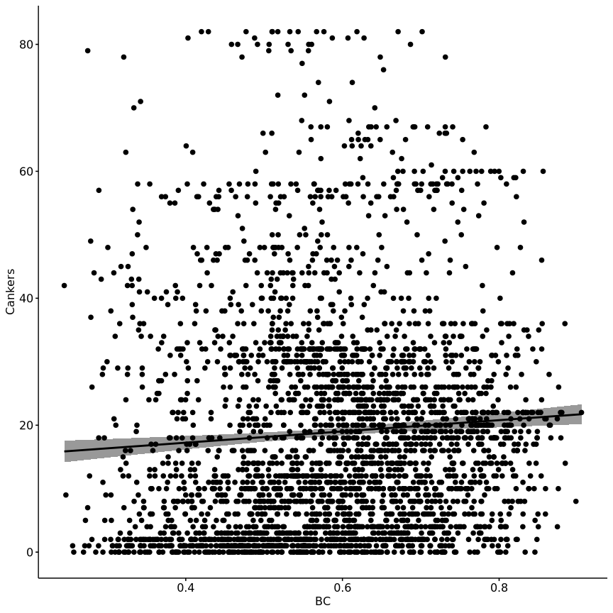

```r
# Plot correlation between Bray-Curtis and canker count difference
ggscatter(bc_cankers, x = "BC", y = "Cankers", add = "reg.line", conf.int = TRUE)
```

### NMDS ordination

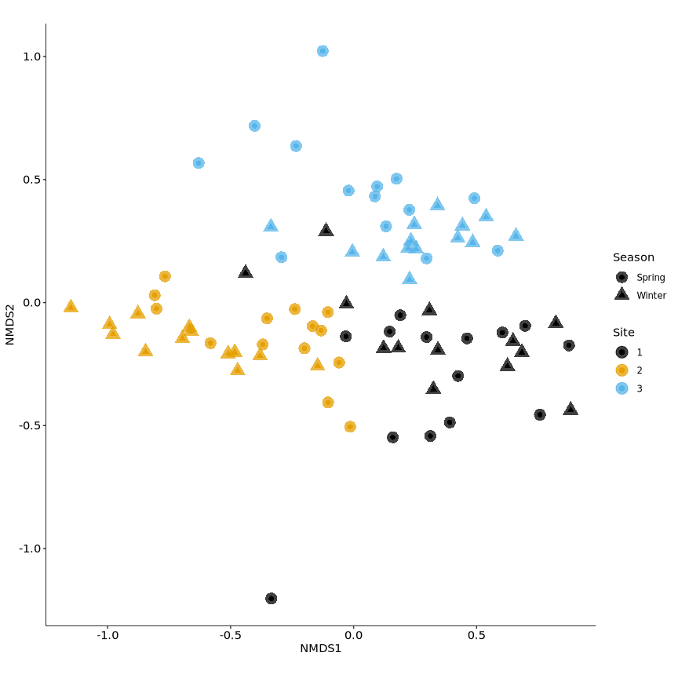

```r
set.seed(sum(utf8ToInt("Hamish McLean")))
ord <- metaMDS(vg,trace=0)
#sratmax=20000,maxit=20000,try = 177, trymax = 177

bac_nmds <- scores(ord)

bac_nmds_plot <- plotOrd(
  bac_nmds, colData(dds),
  design = "Site",
  shape = "Season",
  alpha = 0.75, cbPalette = T
) #+ theme(text = element_text(size = 14))

ggsave(filename = "bac_nmds_plot.png", plot = bac_nmds_plot, path = "figures/")

bac_nmds_plot
```

#### NMDS with canker counts

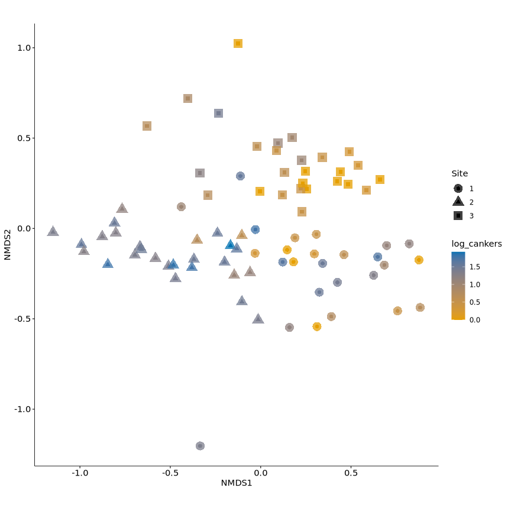

```r
# Rownames for which Cankers is NA
missing <- rownames(colData[is.na(colData$Cankers), ])

colData$log_cankers <- log10(colData$Cankers + 1)

bac_nmds_canker_plot <- plotOrd(
  bac_nmds, colData,
  design = "log_cankers",
  shape = "Site",
  continuous = TRUE,
  colourScale = c(low = "#E69F00", high = "#0072B2"),
  legendDesign = "colourbar",
  exclude = missing,
  alpha = 0.75, cbPalette = TRUE
)

bac_nmds_canker_plot
```

## ASV abundance

### Explore distribution of ASV counts

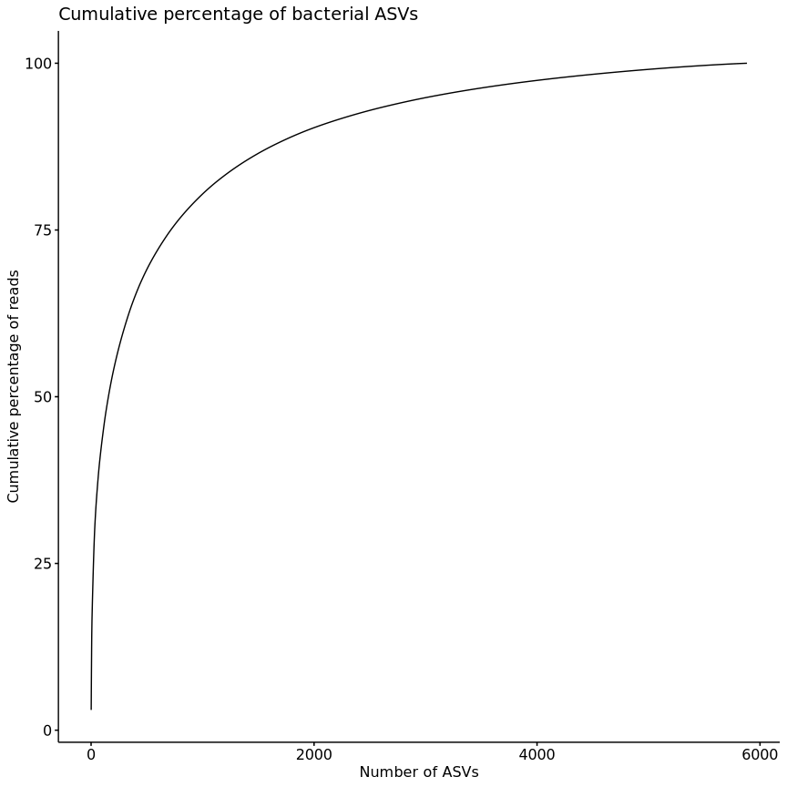

```r
# Extract normalised counts from DESeq object
asv_counts <- counts(dds, normalize = T) %>% as.data.frame()

# Sum ASV counts across samples
total_asv_counts <- rowSums(asv_counts)

# Sort ASVs by abundance
total_asv_counts <- total_asv_counts[order(total_asv_counts, decreasing = T)]

# Caculate cumulative percentage
cumulative <- data.frame(
  cumulative = cumsum(total_asv_counts) / sum(total_asv_counts) * 100,
  no = seq_along(total_asv_counts)
)

# Plot cumulative percentage of ASVs
bac_cum_asv <- ggline(
  data = cumulative, x = "no", y = "cumulative",
  plot_type = "l", palette = cbPalette,
  title = "Cumulative percentage of bacterial ASVs", xlab = "Number of ASVs",
  ylab = "Cumulative percentage of reads"
)
ggsave(filename = "bac_cum_asv.png", plot = bac_cum_asv, path = "figures/")
bac_cum_asv
```

```r
# Find the number of ASVs that account for 50%, 80%, and 99% of total reads
cat(
  "Number of ASVs that account for 50%, 80%, 90%, and 99% of total reads", "\n\n",
  "50%:", sum(cumulative <= 50), "\n",
  "80%:", sum(cumulative <= 80), "\n",
  "90%:", sum(cumulative <= 90), "\n",
  "99%:", sum(cumulative <= 99), "\n"
)
```

[output not shown]

```r
# Find the cumulative percentage accounted for by top x ASVs
cat(
  "Percentage of total reads accounted for by the top 100, 200,and 500 ASVs:", "\n\n",
  "100:", round(cumulative[cumulative$no == 100, "cumulative"], 1) , "\n",
  "200:", round(cumulative[cumulative$no == 200, "cumulative"], 1) , "\n",
  "500:", round(cumulative[cumulative$no == 500, "cumulative"], 1) , "\n"
)
```

```
# Percentage of total reads accounted for by the top 100, 200,and 500 ASVs:
#
#  100: 43.7
#  200: 53.9
#  500: 69.1
```

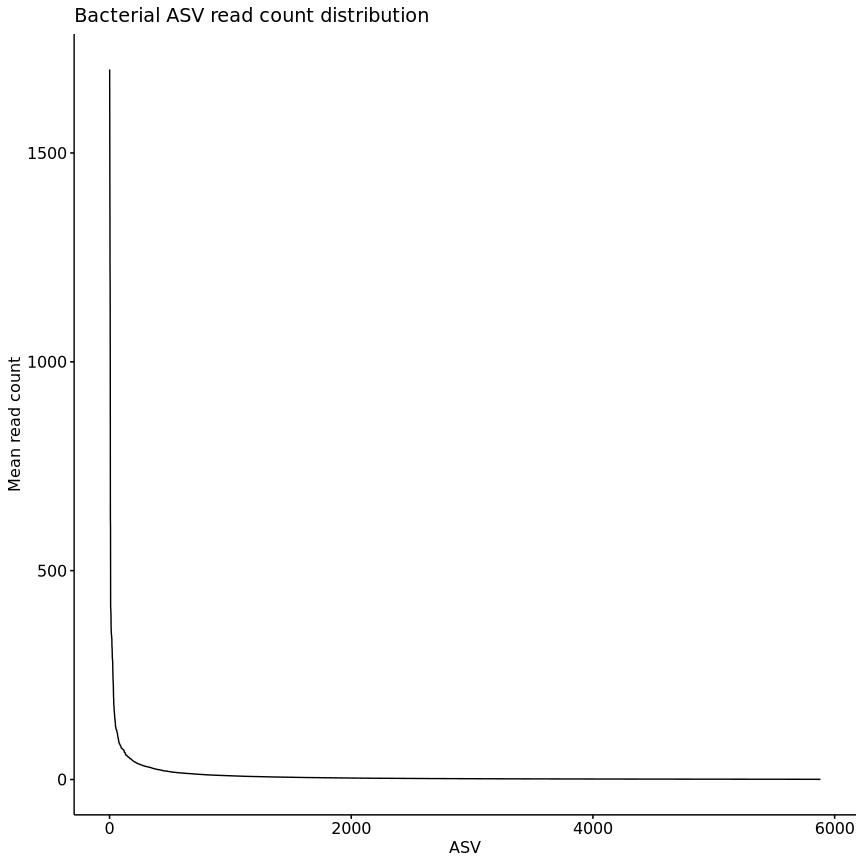

```r
# Average ASV counts in order
mean_asv_counts <- rowMeans(asv_counts)
mean_asv_counts <- mean_asv_counts[order(mean_asv_counts, decreasing = T)]

# Plot read count distribution
bac_asv_counts <- ggline(
  data = data.frame(ASV = seq_along(mean_asv_counts), counts = mean_asv_counts),
  x = "ASV", y = "counts", plot_type = "l",
  title = "Bacterial ASV read count distribution", xlab = "ASV", ylab = "Mean read count"
)
ggsave(filename = "bac_asv_counts.png", plot = bac_asv_counts, path = "figures/")
bac_asv_counts
```

```r
# Number of ASVs with mean read count > 100, 200, and 500
cat(
  "Number of ASVs with mean read count > 100, 200, and 500", "\n\n",
  "100:", sum(rowMeans(asv_counts) > 100), "\n",
  "200:", sum(rowMeans(asv_counts) > 200), "\n",
  "500:", sum(rowMeans(asv_counts) > 500), "\n"
)
```

```
# Number of ASVs with mean read count > 100, 200, and 500
#
#  100: 71
#  200: 32
#  500: 8
```

### Filter top ASVs with 100 % of reads

```r
# Filter the top x abundant ASVs by the sum of their normalised counts
# top_asvs <- asv_counts[order(rowSums(asv_counts), decreasing = T)[1:DIFFOTU], ]

# Filter ASVs with mean read count > 100
# top_asvs <- asv_counts[rowMeans(asv_counts) > 100, ]

# Filter top ASVs with 90% of reads
# top_asvs <- asv_counts[filter_otus(asv_counts, BACASVFILTER), ]

# No filtering
top_asvs <- asv_counts

# Check that sample names match
identical(names(top_asvs), rownames(colData))
```

```
# [1] TRUE
```

```r
# Extract taxonomic data for top ASVs
top_taxa <- taxData[rownames(top_asvs), ]

# Log transform normalised counts
# top_asvs <- log10(top_asvs + 1) # Log transform in models instead

top_asv_data <- data.frame(t(top_asvs))
top_asv_ids <- rownames(top_asvs)
identical(rownames(top_asv_data), rownames(colData))
```

```
# [1] TRUE
```

```r
top_asv_data <- merge(top_asv_data, colData, by = 0) %>% column_to_rownames("Row.names")
```

### Effect of design factors on abundance of top ASVs

```r
# Perform ANOVA on list of top ASVs
top_asvs_anova_results <- lapply(
  top_asv_ids,
  function(asv) {
    asv_lm_anova(asv, formula, top_asv_data) %>%
    extend_asv_anova(asv)
  }
) %>% bind_rows() %>% data.table()

# Group by factor and adjust p-values
top_asvs_anova_results <- top_asvs_anova_results %>%
  group_by(Factor) %>%
  mutate(p.adj = p.adjust(`Pr..F.`, method = "BH")) %>%
  data.table()

# Order factors by original order
top_asvs_anova_results$Factor <- factor(top_asvs_anova_results$Factor, levels = unique(top_asvs_anova_results$Factor))

# Summary of top ASV ANOVA results
top_asvs_anova_summary <- top_asvs_anova_results %>%
  select(ASV, Taxonomy, Abundance, Factor, var, p.adj) %>%
  pivot_wider(names_from = Factor, values_from = c(var, p.adj), names_glue = "{Factor}_{.value}") %>%
  select(
    ASV, Taxonomy, Abundance, Site_var, Site_p.adj, Storage_var, Storage_p.adj,
    Scion_var, Scion_p.adj, "Site:Storage_var", "Site:Storage_p.adj", "Site:Scion_var",
    "Site:Scion_p.adj", "Storage:Scion_var", "Storage:Scion_p.adj", "Site:Storage:Scion_var",
    "Site:Storage:Scion_p.adj"
  ) %>%
  data.table()

# top_asvs_anova_summary %>%
#   kbl() %>%
#   kable_styling("striped", full_width = F)

cat(
  "Number of ASVs with statistically significant (*P* < 0.05) adjusted p-values", "\n\n",
  "Site:", nrow(top_asvs_anova_results[Factor == "Site" & p.adj < 0.05, ]), "\n",
  "Storage:", nrow(top_asvs_anova_results[Factor == "Storage" & p.adj < 0.05, ]), "\n",
  "Scion:", nrow(top_asvs_anova_results[Factor == "Scion" & p.adj < 0.05, ]), "\n",
  "Site:Storage:", nrow(top_asvs_anova_results[Factor == "Site:Storage" & p.adj < 0.05, ]), "\n",
  "Site:Scion:", nrow(top_asvs_anova_results[Factor == "Site:Scion" & p.adj < 0.05, ]), "\n",
  "Storage:Scion:", nrow(top_asvs_anova_results[Factor == "Storage:Scion" & p.adj < 0.05, ]), "\n",
  "Site:Storage:Scion:", nrow(top_asvs_anova_results[Factor == "Site:Storage:Scion" & p.adj < 0.05, ]), "\n\n",
  "Total ASVs:", length(unique(top_asvs_anova_results$ASV)), "\n\n"
)

# Filter by significant effect of scion and its interactions
scion_asvs <- top_asvs_anova_results[grepl("Scion", Factor) & p.adj < 0.05, ]

# scion_asvs %>%
#   kbl() %>%
#   kable_styling("striped", full_width = F)

cat(
  length(unique(scion_asvs$ASV)),
  "ASVs with significant (*P* < 0.05) adjusted p-values for the effect of Scion and its interactions.", "\n\n"
)

# Summary of ASVs with significant Scion effect
# bac_significant_scion <- top_asvs_anova_summary[ASV %in% scion_asvs$ASV, ] %>%
#   arrange(desc(Abundance))

# kbl(bac_significant_scion) %>%
#   kable_styling("striped")

# kbl(bac_significant_scion) %>%
#   kable_styling("striped") %>%
#   save_kable("tables/BAC_scion_asvs.html")

top_asvs_anova_summary %>%
  arrange(desc(Abundance)) %>%
  kbl() %>%
  kable_styling("striped") %>%
  save_kable("tables/BAC_all_asvs.html")
```

```r
# Export significant ASVs as fasta

# Read BAC ASVs
BAC_asvs <- read.fasta("data/BAC.zotus.fa")
# Replace 'OTU' with 'ASV' in sequence names
names(BAC_asvs) <- gsub("OTU", "ASV", names(BAC_asvs))

# Write significant ASVs to fasta
write.fasta(
  sequences = BAC_asvs[scion_asvs$ASV],
  names = paste(scion_asvs$ASV, taxData[scion_asvs$ASV, "rank"]),
  file = "fasta/BAC_scion_asvs.fasta"
)
```

### Effect of design factors and canker counts on abundance of top ASVs

```r
formula <- design_with_canker

# Perform ANOVA on list of top ASVs
asv_canker_anova_results <- lapply(
  top_asv_ids,
  function(asv) {
    asv_lm_anova_canker(asv, formula, top_asv_data) %>%
    extend_asv_anova_canker(asv)
  }
) %>% bind_rows() %>% data.table()

# Group by factor and adjust p-values
asv_canker_anova_results <- asv_canker_anova_results %>%
  group_by(Factor) %>%
  mutate(p.adj = p.adjust(`Pr..F.`, method = "BH")) %>%
  data.table()

# Order factors by original order
asv_canker_anova_results$Factor <- factor(asv_canker_anova_results$Factor, levels = unique(asv_canker_anova_results$Factor))

# Summary of top ASV ANOVA results
asv_canker_anova_summary <- asv_canker_anova_results %>%
  select(ASV, Taxonomy, Abundance, Factor, var, p.adj, coef) %>%
  pivot_wider(names_from = Factor, values_from = c(var, p.adj, coef), names_glue = "{Factor}_{.value}") %>%
  select(
    ASV, Taxonomy, Abundance,
    Site_var, Site_p.adj, Storage_var, Storage_p.adj,
    Scion_var, Scion_p.adj, Cankers_var, Cankers_p.adj,
    "Site:Storage_var", "Site:Storage_p.adj",
    "Site:Scion_var", "Site:Scion_p.adj",
    "Storage:Scion_var", "Storage:Scion_p.adj",
    "Site:Cankers_var", "Site:Cankers_p.adj",
    "Storage:Cankers_var", "Storage:Cankers_p.adj",
    "Scion:Cankers_var", "Scion:Cankers_p.adj",
    "Cankers_coef"
    # "Site:Storage:Scion_var", "Site:Storage:Scion_p.adj",
    # "Site:Storage:Cankers_var", "Site:Storage:Cankers_p.adj",
    # "Site:Storage:Scion:Cankers_var", "Site:Storage:Scion:Cankers_p.adj"
  ) %>%
  data.table()

cat(
  "Number of ASVs with statistically significant (*P* < 0.05) adjusted p-values", "\n\n",
  "Site:", nrow(asv_canker_anova_results[Factor == "Site" & p.adj < 0.05, ]), "\n",
  "Storage:", nrow(asv_canker_anova_results[Factor == "Storage" & p.adj < 0.05, ]), "\n",
  "Scion:", nrow(asv_canker_anova_results[Factor == "Scion" & p.adj < 0.05, ]), "\n",
  "Cankers:", nrow(asv_canker_anova_results[Factor == "Cankers" & p.adj < 0.05, ]), "\n",
  "Site:Storage:", nrow(asv_canker_anova_results[Factor == "Site:Storage" & p.adj < 0.05, ]), "\n",
  "Site:Scion:", nrow(asv_canker_anova_results[Factor == "Site:Scion" & p.adj < 0.05, ]), "\n",
  "Storage:Scion:", nrow(asv_canker_anova_results[Factor == "Storage:Scion" & p.adj < 0.05, ]), "\n",
  "Site:Cankers:", nrow(asv_canker_anova_results[Factor == "Site:Cankers" & p.adj < 0.05, ]), "\n",
  "Storage:Cankers:", nrow(asv_canker_anova_results[Factor == "Storage:Cankers" & p.adj < 0.05, ]), "\n",
  "Scion:Cankers:", nrow(asv_canker_anova_results[Factor == "Scion:Cankers" & p.adj < 0.05, ]), "\n",
  "Total ASVs:", length(unique(asv_canker_anova_results$ASV)), "\n\n"
)

# Filter by significant effect of scion and its interactions
canker_asvs <- asv_canker_anova_results[grepl("Cankers", Factor) & p.adj < 0.05, ]

# canker_asvs %>%
#   kbl() %>%
#   kable_styling("striped", full_width = F)

cat(
  length(unique(canker_asvs$ASV)),
  "ASVs with significant (*P* < 0.05) adjusted p-values for the effect of Cankers and its interactions.", "\n\n"
)

# Summary of ASVs with significant Scion effect
bac_significant_canker <- asv_canker_anova_summary[ASV %in% canker_asvs$ASV, ] %>%
  arrange(desc(Abundance))

kbl(bac_significant_canker) %>%
  kable_styling("striped") %>%
  save_kable("tables/BAC_asvs_design_canker.html")

asv_canker_anova_summary %>%
  arrange(desc(Abundance)) %>%
  kbl() %>%
  kable_styling("striped") %>%
  save_kable("tables/BAC_asvs_design_canker_all.html")
```

## Canker counts

Testing the effects of of ASV abundance, α-diversity, and β-diversity on canker counts.

This uses a nested negative binomial regression model.

The base model for canker counts uses the formula: Cankers ~ Site * Storage * Scion.

```r
# Filter out samples with missing canker count
canker_abundance_data <- colData[complete.cases(colData$Cankers), ]

# Base model
# canker_design = "Cankers ~ Site * Storage * Scion"
base_model <- glm.nb(canker_design, data = canker_abundance_data)

# Abundance model
abundance_design = paste(canker_design, "+ log(copy_number)")
abundance_model <- glm.nb(abundance_design, data = canker_abundance_data)

# ANOVA of abundance with canker count
anova(base_model, abundance_model) %>%
  kbl() %>%
  kable_styling("striped")
```

| Model | theta | Resid. df | 2 x log-lik. | Test | df | LR stat. | Pr(Chi) |
| --- | --- | --- | --- | --- | --- | --- | --- |
| Site * Storage * Scion | 2.655307 | 38 | -491.1801 |  | NA | NA | NA |
| Site * Storage * Scion + log(copy_number) | 2.694830 | 37 | -490.0226 | 1 vs 2 | 1 | 1.157469 | 0.2819912 |

### Effect of ASV abundance on canker count

```r
# Filter out samples with missing canker count
top_asv_data <- top_asv_data[complete.cases(top_asv_data$Cankers), ]

# Base model design
canker_design = "Cankers ~ Site * Storage * Scion"

# Base model with ASV abundance data
base_model <- glm.nb(canker_design, data = top_asv_data)

# Effect of ASV abundance on canker count for top ASVs
asv_canker_results <- lapply(
  top_asv_ids,
  function(x) asv_canker_anova(x, canker_design, base_model, top_asv_data)
) %>% bind_rows() %>% data.table()

# Adjust p-values for multiple testing
asv_canker_results$p_adjusted <- p.adjust(asv_canker_results$p, method = "BH")

# Summary of ASVs with statistically significant (*P* < 0.05) adjusted p-values
cat(
  nrow(asv_canker_results[p_adjusted < 0.05, ]),
  "ASVs have statistically significant (*P* < 0.05) adjusted p-values"
)

bac_sig_canker_asvs <- asv_canker_results[p_adjusted < 0.05, ] %>%
  arrange(desc(Abundance))

# kbl(bac_sig_canker_asvs) %>%
#   kable_styling("striped")

kbl(bac_sig_canker_asvs) %>%
  kable_styling("striped") %>%
  save_kable("tables/BAC_canker_asvs.html")

cat(
  "\nSignificant canker bacterial ASVs\n",
  "\nTotal ASVs: ", nrow(asv_canker_results),
  "\nWarnings: ", nrow(asv_canker_results[!is.na(warning)]),
  "\nTotal ASVs without warnings: ", nrow(asv_canker_results[is.na(warning)]),
  "\nTotal significant ASVs: ", nrow(asv_canker_results[p_adjusted < 0.05]),
  "\nASVs with negative effect: ", nrow(asv_canker_results[p_adjusted < 0.05 & coef < 0]),
  "\nASVs with positive effect: ", nrow(asv_canker_results[p_adjusted < 0.05 & coef > 0]), "\n"
)
```

#### Effect of ASV abundance on canker count per site

Filter top ASVs with 100 % of reads per site and test the effect of ASV abundance on canker count per site.

```r
# For each site, select top ASVs with 50% of reads
top_asvs_per_site <- lapply(
  unique(colData$Site),
  function(site) {
    samples <- filter(colData, Site == site)
    top_asv_data <- select(asv_counts, rownames(samples))
    # top_asvs <- filter(top_asv_data, rowMeans(top_asv_data) > 100)
    # top_asvs <- top_asv_data[filter_otus(top_asv_data, BACASVFILTER), ]
    top_asvs <- top_asv_data[rowSums(top_asv_data) > 0, ]
    # top_asvs <- top_asvs[ , colSums(is.na(top_asvs)) == 0] # Remove ASVs with missing values
    top_asv_ids <- rownames(top_asvs)
    top_asvs <- data.frame(t(top_asvs)) %>% merge(samples, by = 0) %>% column_to_rownames("Row.names")
    top_asvs <- top_asvs[complete.cases(top_asvs$Cankers), ]
    return(list(asvs = top_asv_ids, data = top_asvs))
  }
)

# Summary of top ASVs per site
data.table(
  Site = 1:3,
  topASVs = sapply(top_asvs_per_site, function(x) length(x$asvs)),
  totalASVs = sapply(top_asvs_per_site, function(x) sum(rowSums(asv_counts[, rownames(x$data)]) > 0, na.rm = TRUE)),
  topreads = sapply(top_asvs_per_site, function(x) sum(select(x$data, starts_with("ASV")))),
  totalreads = sapply(top_asvs_per_site, function(x) sum(asv_counts[, rownames(x$data)]))
) %>% mutate(
  "ASV%" = round(topASVs / totalASVs * 100),
  "Read%" = round(topreads / totalreads * 100)
) %>% kbl() %>% kable_styling("striped")

canker_site_design <- "Cankers ~ Storage * Scion"

# ANOVA of ASV abundance with canker count per ASV
asv_canker_site_anova <- function(asvs, data) {
  base_model <- glm.nb(canker_site_design, data = data)
  results <- lapply(
    asvs,
    function(asv) asv_canker_anova(asv, canker_site_design, base_model, data)
  ) %>% bind_rows() %>% data.table()
  results$p_adjusted <- p.adjust(results$p, method = "BH")
  return(results)
}

# Run ANOVA per site
asv_canker_site_results <- lapply(
  top_asvs_per_site,
  function(x) asv_canker_site_anova(x$asvs, x$data)
)

# Add site to each result as new column and merge into single data.table
asv_canker_site_results <- lapply(
  1:3,
  function(site) {
    result <- asv_canker_site_results[[site]]
    result$Site <- site
    return(result)
  }
) %>% bind_rows()

# Significant ASVs
significant_asvs <- asv_canker_site_results[p_adjusted < 0.05 & is.na(warning), ]

bac_canker_site_asvs <- significant_asvs[, c("Site", "ASV", "Taxonomy", "Abundance", "coef", "var", "p_adjusted", "warning")] %>%
  arrange(Site, desc(Abundance))

# kbl(bac_canker_site_asvs) %>%
#   kable_styling("striped")

kbl(bac_canker_site_asvs) %>%
  kable_styling("striped") %>%
  save_kable("tables/BAC_significant_site_canker_asvs.html")

for(site in 1:3){
  cat(
    "\nSignificant canker fungal ASVs for site ", site, "\n",
    "\nTotal ASVs: ", nrow(asv_canker_site_results[Site == site]),
    "\nWarnings: ", nrow(asv_canker_site_results[Site == site & !is.na(warning)]),
    "\nTotal ASVs without warnings: ", nrow(asv_canker_site_results[Site == site & is.na(warning)]),
    "\nTotal significant ASVs: ", nrow(asv_canker_site_results[Site == site & p_adjusted < 0.05]),
    "\nASVs with negative effect: ", nrow(asv_canker_site_results[Site == site & p_adjusted < 0.05 & coef < 0]),
    "\nASVs with positive effect: ", nrow(asv_canker_site_results[Site == site & p_adjusted < 0.05 & coef > 0]), "\n"
  )
}
```

```r
# Export significant ASVs as FASTA
write.fasta(
  sequences = BAC_asvs[as.character(significant_asvs$ASV)],
  names = paste(significant_asvs$ASV, taxData[as.character(significant_asvs$ASV), "rank"]),
  file = "fasta/BAC_canker_asvs.fasta"
)
```

##### Plot of ASV abundance against canker count

```r
# List of significant ASVs
significant_asv_list <- significant_asvs$ASV %>% unlist()

significant_asv_data <- asv_counts[significant_asv_list, ] %>%
  t() %>%
  data.frame() %>%
  merge(colData, by = 0) %>%
  column_to_rownames("Row.names") %>%
  select(c(significant_asv_list, "Site", "Storage", "Scion", "Cankers"))

# Melt data for ggplot
significant_asv_long_data <- significant_asv_data %>% reshape2::melt(
  id.vars = c("Site", "Storage", "Scion", "Cankers"), variable.name = "ASV", value.name = "Abundance"
)

# Log trasnform abundance
significant_asv_long_data$log10_abundance <- log10(significant_asv_long_data$Abundance + 1)

bac_asv_canker_plot <- ggscatter(
  data = significant_asv_long_data, x = "log10_abundance", y = "Cankers",
  color = "Storage", facet.by = c("ASV", "Site"),
  xlab = "ASV abundance (log10)", ylab = "Canker count",
  palette = cbPalette, legend = "bottom"
)

ggsave(
  filename = "bac_asv_canker_plot.png", plot = bac_asv_canker_plot, path = "figures/",
  height = 40, width = 20, units = "cm"
)

bac_asv_canker_plot
```